# PSPManalysis

### 4.4.4 An example session using the `PSPMequi` function

To illustrate the use of the `PSPMequi` function I will discuss the analysis of the PNAS model, presented in section 4.2. The statements below are taken from one of the demos, called `"deRoosPersson"`, that is included with this `R` package. This demo executes in addition to the statements represented here, `R` commands to visualize the computed results in graphs. It is therefore recommended to run the demo, using the command `demo("deRoosPersson", echo=FALSE)` at the same time as reading the explanation in this section (but notice first the package has to be loaded via `library("PSPManalysis")`). The demo uses the `C` implementation of the PNAS model (see section 4.3.2).

Starting the analysis of a PSPM from some random initial values to search for the equilibrium values of environment variables and population birth rates is often not a very successful strategy. Most likely, the initial point will be too far off a solution point, which might cause the software not to converge to the solution. A better alternative is to start with a trivial equilibrium of the model, the value of which is known on beforehand. For example, it is biologically realistic to assume that at very high mortality or at very low food conditions a population is extinct. Such an extinct state is often easily characterized and hence provides a useful starting point.

The analysis of the PNAS model is therefore started from the trivial equilibrium, which is stable for very low values of the resource productivity $R_{max}$. In this equilibrium only the resource density has a non-zero value equal to its maximum $\tilde{R}=R_{max}$, while both the consumer and the predator equilibrium are in a zero equilibrium state. For this reason, the `PSPMequi` function is invoked with the option vector `c("popZE", "0", "envZE", "1", "envZE", "2")`, which enforces this zero equilibrium state for the structured population with index 0 (the consumer), the environment variable with index 1 (the predator) and the environment variable with index 2 (the biomass of small consumers that are vulnerable to predation). The latter is obviously in a zero equilibrium state, because the variable represents an integral over the population distribution of the consumer. More generally, if a structured population is assumed to be in a zero equilibrium state by using the `"popZE"` option, a zero equilibrium state should also be enforced for all the environment variables that represent integrals over this population distribution (that are hence of the type `POPULATIONINTEGRAL`). Because consumer and predator are assumed to be in a zero equilibrium state the initial point for the call to the `PSPMequi` function shown in the box 4.4.4.A below consists of only 2 elements, $R_{max}$ and the initial guess for $\tilde{R}$, which are both taken equal to $1.0\cdot10^{-6}$. The parameter with index 1, which corresponds to $R_{max}$, is the one to be varied in positive direction with step size 0.5 over the range 0 to $4.0\cdot10^{-4}$.

> Notice that if the `R` implementation of the PNAS model would have been used for this demonstration the index of the parameter to vary should have been specified as 2 instead of 1, since vector indices in `R` start at 1 whereas in `C` they start at 0. As an alternative to specifying the index of the parameter, if the model is implemented in `R`, the name of the parameter in the parameter vector `DefaultParameters` (see code block 4.3.1.4) could have been specified as a string `"Rmax"` as first element of the fifth argument in the call to the `PSPMequi` function shown below.

The sixth argument in the call to the `PSPMequi` function shown below is left undefined by specifying it as `NULL`. This argument represents the parameter values to be used for the computation. Because a vector is not specified, the argument is ignored and the default parameter values, as specified in code block 4.3.2.2, are used. This sixth argument will also be left undefined in all further calls to the `PSPMequi` function discussed below and will therefore from hereon be ignored.

##### Command box 4.4.4.A

```
> output1 <- PSPMequi("PNAS2002", "EQ", c(1.0E-06, 1.0E-06), 0.5, c(1, 0, 4E-4), NULL,
                      c("popZE", "0", "envZE", "1", "envZE", "2"), clean=TRUE, force=TRUE);

Building executable PNAS2002equi.so ...

<...compilation output lines suppressed in this box...>

  1.00000000E-06, 1.00000000E-06
  1.35355339E-06, 1.35355339E-06
  1.70710678E-06, 1.70710678E-06
<...output lines suppressed in this box...>
  8.77817459E-06, 8.77817459E-06
  8.85690312E-06, 8.85690312E-06  ****  BP #0   ****
  9.13172798E-06, 9.13172798E-06
<...output lines suppressed in this box...>
  3.34047294E-04, 3.34047294E-04
  3.69402633E-04, 3.69402633E-04
  4.04757972E-04, 4.04757972E-04

> cat(output1$curvedesc)
 #
 # Executing : PSPMequi("PNAS2002", "EQ", c(1E-06, 1E-06), 0.5, c(1, 0, 0.0004), NULL, c("popZE", "0", .......
 #
 # Parameter values  :
 #
 #  Rho       :  0.1            Rmax      :  1E-06          Lb        :  7
 #  Lv        :  27             Lj        :  110            Lm        :  300
 #  Omega     :  9E-06          Imax      :  0.0001         Rh        :  1.5E-05
 #  Gamma     :  0.006          Rm        :  0.003          Mub       :  0.01
 #  A         :  5000           Th        :  0.1            Epsilon   :  0.5
 #  Delta     :  0.01
 #
 # Index and name of bifurcation parameter #1                   : 1 (Rmax)
 #
 #         1:Rmax          2:E[0]          3:E[1]          4:E[2]          5:b[0]       6:I[0][0] .......
> output1$curvepoints
              Rmax         E[0]   E[1]   E[2]   b[0]   I[0][0] ..    pcgE[1]        R0[0]     RHS norm
 [1,] 1.000000e-06 1.000000e-06      0      0      0         0 ..      -0.01    0.0000000 0.000000e+00
 [2,] 1.353553e-06 1.353553e-06      0      0      0         0 ..      -0.01    0.0000000 0.000000e+00
 [3,] 1.707107e-06 1.707107e-06      0      0      0         0 ..      -0.01    0.0000000 0.000000e+00
<...output lines suppressed in this box...>
[71,] 3.340473e-04 3.340473e-04      0      0      0         0 ..      -0.01 4430.1631110 0.000000e+00
[72,] 3.694026e-04 3.694026e-04      0      0      0         0 ..      -0.01 4491.4630242 0.000000e+00
[73,] 4.047580e-04 4.047580e-04      0      0      0         0 ..      -0.01 4542.8245695 0.000000e+00
> output1$bifpoints
              Rmax         E[0]   E[1]   E[2]   b[0]   I[0][0] ..    pcgE[1]        R0[0]     RHS norm
[1,] 8.856903e-06  8.856903e-06      0      0      0         0 ..      -0.01            1            0
> output1$biftypes
[1] "BP #0"
```

In the output shown in the box above a large number of intermediate output lines and several intermediate columns have been deleted from the output. Consult the listing in your `R` console for the complete output of the commands executed.

After the specific call shown, the `PSPMequi` function first cleans all previous output file (notice the option `clean=TRUE`) and subsequently compiles the computational module using the `R` command `R CMD SHLIB` into a dynamically loadable library file (notice the somewhat superfluous option `force=TRUE`). Subsequently, the compiled module is executed with the obligatory arguments that the `PSPMequi` function passes on. The computational module computes the particular equilibrium curve over the required range of the parameter with index 1 (representing $R_{max}$; see code block 4.3.2.2). At the end of the computation the `PSPMequi` function prints a textual summary of the computation that has been executed. This is summary is in fact the content of the second element of the output list of the function, `output1$curvedesc`, which is printed to the `R` console using the statement `cat(output1$curvedesc, sep='\n')`. Apart from printing the exact command-line that has been used to start the computation, the values of the parameters are printed using the meaningful, model-specific names, as set in the code block 4.3.2.2. Furthermore, a header line is printed with a short description of each of the columns in the output matrix `output1$curvepoints`. As shown in the box above, executing the command `output1$curvepoints` shows the value of the various columns in this output matrix.

Most importantly, halfway during the computation of the trivial equilibrium the software reports that a branching point has been located, indicated with `"BP #0"`. This branching or transcritical bifurcation point corresponds to the invasion threshold of the consumer. The exact data about the branching point are returned as the third member element of the output list, `output1$bifpoints`. Displaying `output1$bifpoints` reveals that it has the same layout as the output matrix `output1$curvepoints`, but only contains a single row with data for the branching point. Notice that the value of $R_0$, the expected number of offspring produced by an individual consumer during its lifetime, is exactly equal to 1 in this branching point (as it should be), whereas it is smaller and larger than 1 for lower and higher values of $R_{max}$, respectively. The corresponding element of the fourth output variable, assigned to the member element `output1$biftypes` of the output list, contains the descriptive string `"BP #0"` that is also printed to the console on detection of the branching point.

In addition to executing the call to the `PSPMequi` function shown in box 4.4.4.A, the demo script called `"deRoosPersson"` also uses the output variables `output1$curvepoints`, `output1$bifpoints` and `output1$biftypes` to generate a plot of the computed results.

The next step in the analysis of the PNAS model starts from the detected transcritical bifurcation point that is stored in `output1$bifpoints`. Starting from that point the call to `PSPMequi` shown in the next `R` command box computes the equilibrium curve with a non-zero equilibrium state of the consumer, while the predator is still assumed to have a zero equilibrium value. Because the absence of the predator ensures that the third environment variable, representing the total biomass of small consumers that the predator forages on, does not influence the equilibrium state, this third environment variable is also ignored. The `PSPMequi` function is therefore called with the option array `c("envZE","1","envZE","2")`. As before, the curve is computed as a function of the parameter with index 1, which corresponds to $R_{max}$, with step size 0.2 over the range of $R_{max}$ values between 0 and to $4.0\cdot10^{-4}$. As initial point of the computation the $R_{max}$-value and the equilibrium values of the resource density and the population birth rate in the bifurcation point are used, which correspond to the first, second and fifth element in `output1$bifpoints` (although `output1$bifpoints[5]` is of course equal to 0).

##### Command box 4.4.4.B

```
> output2 <- PSPMequi("PNAS2002", "EQ", output1$bifpoints[c(1,2,5)],0.2, c(1,0,4E-4),NULL,c("envZE","1","envZE","2"))

Dynamic library file PNAS2002equi.so is up-to-date

  8.85690312E-06, 8.85690312E-06, 0.00000000E+00
  9.05689403E-06, 8.85690312E-06, 1.90665832E-09
  9.25688494E-06, 8.85690312E-06, 3.81331663E-09
<...output lines suppressed in this box...>
  2.51840533E-04, 8.85690312E-06, 2.31653906E-06
  2.53602314E-04, 8.85690312E-06, 2.33333540E-06  ****  BPE #1  ****
  2.66316121E-04, 8.85690312E-06, 2.45454534E-06
<...output lines suppressed in this box...>
  3.82120831E-04, 8.85690312E-06, 3.55859558E-06
  3.96596420E-04, 8.85690312E-06, 3.69660186E-06
  4.11072009E-04, 8.85690312E-06, 3.83460814E-06

> cat(output2$curvedesc)
 #
 # Executing : PSPMequi("PNAS2002", "EQ", c(8.8569E-06, 8.8569E-06, 0), 0.2, c(1, 0, 0.0004), NULL, ....
 #
 # Parameter values  :
 #
 #  Rho       :  0.1            Rmax      :  8.8569E-06     Lb        :  7
 #  Lv        :  27             Lj        :  110            Lm        :  300
 #  Omega     :  9E-06          Imax      :  0.0001         Rh        :  1.5E-05
 #  Gamma     :  0.006          Rm        :  0.003          Mub       :  0.01
 #  A         :  5000           Th        :  0.1            Epsilon   :  0.5
 #  Delta     :  0.01
 #
 # Index and name of bifurcation parameter #1                   : 1 (Rmax)
 #
 #         1:Rmax          2:E[0]          3:E[1]          4:E[2]          5:b[0]       6:I[0][0] ....
> output2$curvepoints
              Rmax         E[0] E[1] E[2]         b[0]      I[0][0] ..        pcgE[1] R0[0]     RHS norm
 [1,] 8.856903e-06 8.856903e-06    0    0 0.000000e+00 0.000000e+00 ..  -1.000000e-02     1 4.028136e-08
 [2,] 9.056894e-06 8.856903e-06    0    0 1.906658e-09 1.999909e-08 ..  -9.991810e-03     1 4.028136e-08
 [3,] 9.256885e-06 8.856903e-06    0    0 3.813317e-09 3.999818e-08 ..  -9.983620e-03     1 4.028136e-08
<...output lines suppressed in this box...>
[91,] 3.821208e-04 8.856903e-06    0    0 3.558596e-06 3.732639e-05 ..   5.235110e-03     1 4.050461e-08
[92,] 3.965964e-04 8.856903e-06    0    0 3.696602e-06 3.877395e-05 ..   5.824070e-03     1 4.052221e-08
[93,] 4.110720e-04 8.856903e-06    0    0 3.834608e-06 4.022151e-05 ..   6.412900e-03     1 4.054047e-08
> output2$bifpoints
              Rmax         E[0] E[1] E[2]         b[0]      I[0][0] ..        pcgE[1] R0[0]     RHS norm
[1,]  0.0002536023 8.856903e-06    0    0 2.333335e-06 2.447454e-05 ..  -1.181053e-10     1 1.024358e-08
> output2$biftypes
[1] "BPE #1"
```

As in the previous `R` command box a number of output lines and columns have been suppressed to fit the page width of this manual. Please consult the listing in your `R` console for the complete output of the commands executed.

The layout of the output and the output variables of the call to `PSPMequi` shown in box 4.4.4.B is similar to the output as discussed following `R` command box 4.4.4.A. The data of the computation are stored in the output list `output2`. The data of the computed equilibrium points are stored in the element `output2$curvepoints`. Halfway during the computation of the equilibrium the software reports that a branching point has been located for the environment variable with index 1, indicated with `"BPE #1"`. This branching or transcritical bifurcation point corresponds to the invasion threshold of the predator. For $R_{max}$-values above this threshold the predator can invade the equilibrium of the consumer population, but it fails to invade for lower $R_{max}$-values. The exact data about this branching point are contained in `output2$bifpoints`. Displaying `output2$bifpoints` reveals that it has the same layout as the output matrix `output2$curvepoints`, but only contains a single row with data for the branching point. Notice that the population growth rate of the predator, shown in column 10 labeled `pcgE[1]` of the output, is equal to 0 at the detected branching point (as it should be), whereas it is smaller and larger than 0 for lower and higher values of $R_{max}$, respectively. The last element of the output list, `output2$biftypes`, contains the descriptive string `"BPE #1"` that is also printed to the console on detection of the branching point.

As before, the demo script called `"deRoosPersson"` also uses `output2$curvepoints`, `output2$bifpoints` and `output2$biftypes` to plot the computed results of the call to the `PSPMequi` function shown in box 4.4.4.B as additional curves in the graphs that it had generated previously.

The final step in this part of the analysis of the PNAS model starts from the detected transcritical bifurcation point of environment variable 1, representing the predator population, which is stored in the output variable `output2$bifpoints`. Starting from that point the call to `PSPMequi` shown in the next `R` command box computes the equilibrium curve with a non-zero equilibrium state of the consumer and predator. All environment variables influence this equilibrium state, hence the `PSPMequi` function is called without specifying any options. As before, the curve is computed as a function of the parameter with index 1, which corresponds to $R_{max}$, with step size -0.1 over the range of $R_{max}$ values between 0 and to $4.0\cdot10^{-4}$. The choice of a negative step size is arrived at by trial and error. Choosing a positive step size to start the continuation from this point would have quickly shown that the equilibrium predator density would turn negative, whereas this equilibrium density increases from 0 to positive values with a negative step size. The transcritical bifurcation in this invasion point of the predator is hence *subcritical*.

As initial point of the computation the data of the branching point contained in `output2$bifpoints` are used. This initial point should contain appropriate values for the bifurcation parameter $R_{max}$, the equilibrium values of the resource density, the predator density and the biomass density of small, vulnerable consumers as well as the population birth rate in the bifurcation point. Normally, appropriate starting values for these variables are to be found in the first 5 elements of the vector `output2$bifpoints`. Inspection of `output2$bifpoints[1:5]`, however, shows that both `output2$bifpoints[3]` and `output2$bifpoints[4]` are equal to 0:

```
> output2$bifpoints[1:5]
[1] 2.536023e-04 8.856903e-06 0.000000e+00 0.000000e+00 2.333335e-06
```

Obviously, `output2$bifpoints[3]` is equal to 0 as it represents the zero equilibrium value of the predator in the consumer-resource equilibrium curve that is computed with the call to `PSPMequi` shown in `R` command box 4.4.4.B. Given that the next computation starts from the invasion threshold of the predator the value of 0 for the initial predator density is correct. The value of `output2$bifpoints[4]`, however, representing the total biomass density of consumers vulnerable to predation is also 0, because it was produced by a call to `PSPMequi` with the option `c("envZE", "2")`, which forces this environment variable to equal 0. Since this is not appropriate as estimate for the environment variable in an equilibrium with predator, consumer and resource present, the value of the interaction variable `I[0][1]` (column 7 in `output2$bifpoints`) is used instead as initial estimate, which corresponds to the population integral representing the total biomass of small consumers that are vulnerable to predation (see code blocks 4.3.2.11 and 4.3.2.12). Hence, the vector `output2$bifpoints[c(1,2,3,7,5)]` is used as initial point for the computation shown in the next box:

##### Command box 4.4.4.C

[output not shown]

In the output shown in the box above a large number of output lines have been suppressed and intermediate columns have been deleted as in the previous `R` output box, because the page width does not allow them to be shown completely. Consult the listing in your `R` console for the complete output of the commands executed. Otherwise the layout of the output and the output variables of the call to `PSPMequi` shown in box 4.4.4.C is the same as in `R` command box 4.4.4.B. The data of all computed equilibrium points making up the curve are contained in `output3$curvepoints` and the description of the computed curve in the variable `output3$curvedesc`. Issuing the command `cat(output3$curvedesc, sep="\n")` would lead to the textual output with information about the computation that is also produced by the `PSPMequi` function when finishing.

The demo script called `"deRoosPersson"` uses `output3$curvepoints`, `output3$bifpoints` and `output3$biftypes` to draw the additional curves representing the predator-consumer-resource equilibrium in the bifurcation graphs that already showed the curves resulting from the previous 2 call to `PSPMequi` (see `R` command box 4.4.4.A and 4.4.4.B).

At the consumer invasion boundary, the environment variables with index 1 and 2, representing the predator density and the total biomass density of small consumers vulnerable to predation, respectively, are both 0. The last argument of the call to `PSPMequi` shown in `R` command box 4.4.4.D hence equals the vector `c("envZE","1","envZE","2","popBP","0")`, which in addition to the zero equilibrium value for the environment variables also instructs the computational module that the transcritical bifurcation point that is computed occurs in the population with index 0.

##### Command box 4.4.4.D

```
> output4 <- PSPMequi("PNAS2002","BP",c(output1$bifpoints[1:2],0.01),0.05,c(1,0,4E-4,11,0,0.1),NULL,
                      c("envZE","1","envZE","2","popBP","0"))

Dynamic library file PNAS2002equi.so is up-to-date

  8.85690312E-06, 8.85690312E-06, 1.00000000E-02
  8.88483087E-06, 8.88483087E-06, 1.03112655E-02
  8.91358293E-06, 8.91358293E-06, 1.06066164E-02
<...output lines suppressed in this box...>
  3.94598924E-04, 3.94598924E-04, 8.27003296E-02
  3.98126241E-04, 3.98126241E-04, 8.27343996E-02
  4.01653833E-04, 4.01653833E-04, 8.27678949E-02

> cat(output4$curvedesc)
 #
 # Executing : PSPMequi("PNAS2002", "BP", c(8.8569E-06, 8.8569E-06, 0.01), 0.05, c(1, 0, 0.0004, 11, ....
 #
 # Parameter values  :
 #
 #  Rho       :  0.1            Rmax      :  8.8569E-06     Lb        :  7
 #  Lv        :  27             Lj        :  110            Lm        :  300
 #  Omega     :  9E-06          Imax      :  0.0001         Rh        :  1.5E-05
 #  Gamma     :  0.006          Rm        :  0.003          Mub       :  0.01
 #  A         :  5000           Th        :  0.1            Epsilon   :  0.5
 #  Delta     :  0.01
 #
 # Index and name of bifurcation parameter #1                   : 1 (Rmax)
 # Index and name of bifurcation parameter #2                   : 11 (Mub)
 # Index of structured population with transcritical bifurcation: 0
 #
 #         1:Rmax          2:E[0]          3:E[1]          4:E[2]          5:b[0]           6:Mub ....
> output4$curvepoints
               Rmax         E[0]          E[1]         E[2]         b[0]        Mub  ..      RHS norm
  [1,] 8.856903e-06 8.856903e-06             0            0            0 0.01000000  ..  4.920353e-08
  [2,] 8.884831e-06 8.884831e-06             0            0            0 0.01031127  ..  1.327406e-08
  [3,] 8.913583e-06 8.913583e-06             0            0            0 0.01060662  ..  1.515673e-08
<...output lines suppressed in this box...>
[511,] 3.945989e-04 3.945989e-04             0            0            0 0.08270033  ..  9.558855e-10
[512,] 3.981262e-04 3.981262e-04             0            0            0 0.08273440  ..  9.616150e-10
[513,] 4.016538e-04 4.016538e-04             0            0            0 0.08276789  ..  9.642249e-10
```

(Once again, consult your `R` console for a complete listing of the output of the commands shown above as parts of this output is deleted for the sake of brevity and layout).

The output list of the `PSPMequi` function now only contains 2 member elements, the data matrix `output4$curvepoints` containing all information about the points making up the computed curve and the description variable `output4$curvedesc`, whose contents can be shown by executing `cat(output4$curvedesc,sep="\n")` and is also printed by the `PSPMequi` function to the `R` console on exit. The output list does not include the two additional output elements containing information about bifurcations, since no detection of such special points is carried out during computations of transcritical bifurcation boundaries. As shown in the `R` command box above the output now contains an additional column, which follows the values of the birth rate of the structured population in equilibrium. This column contains the value of the second bifurcation parameter, which corresponds to $\mu_b$ in the PNAS model. The demo script called `"deRoosPersson"` subsequently uses the first and and the sixth column of `output4$curvepoints` to create a graph with $R_{max}$ (first column) on the $x$-axis and $\mu_b$ (sixth column) on the $y$-axis, showing the regions of parameter space for which persistence of the consumer population is and is not possible.

Computing the predator invasion boundary as a function of $R_{max}$ and $\mu_b$ starts from the data on the branching point stored in the output variable `output2$bifpoints`, which was detected during the computation of the consumer-resource equilibrium without any predators (see `R` command box 4.4.4.B). The first two elements of this vector represent the value of $R_{max}$ and the equilibrium resource density at the predator invasion boundary, while the fifth element of `output2$bifpoints` represents the birth rate of the structured consumer population in this equilibrium (see the listing of `output2$bifpoints` in `R` command box 4.4.4.B). To complete the specification of the initial point of the computation the default value of consumer background mortality (0.01) is added. Hence, the initial point of the computation is `c(output2$bifpoints[c(1,2,5)],0.01)`. The type of the computation, which is the second argument to the `PSPMequi` function, is now specified as `"BPE"`, indicating that a transcritical bifurcation curve in an environment variable is to be computed as a function of 2 model parameters.

##### Command box 4.4.4.E

```
> output5 <- PSPMequi("PNAS2002","BPE",c(output2$bifpoints[c(1,2,5)],0.01), -0.1, c(1,0,4E-4,11,0,0.1), NULL,
                      c("envZE","2","envBP","1"))

Dynamic library file PNAS2002equi.so is up-to-date

  2.53602314E-04, 8.85690312E-06, 2.33333540E-06, 1.00000000E-02
  2.44422274E-04, 8.88032498E-06, 2.35250524E-06, 1.02628274E-02
  2.35413020E-04, 8.90710825E-06, 2.37324896E-06, 1.05420330E-02
<...output lines suppressed in this box...>
  3.88476404E-04, 2.61758186E-04, 1.08055050E-05, 8.07841851E-02
  3.95419275E-04, 2.68571866E-04, 1.08238254E-05, 8.09262046E-02
  4.02376218E-04, 2.75405273E-04, 1.08413352E-05, 8.10619333E-02

> cat(output5$curvedesc)
 #
 # Executing : PSPMequi("PNAS2002", "BPE", c(0.000253602, 8.8569E-06, 2.33334E-06, 0.01), -0.1, c(1, 0, ....
 #
 # Parameter values  :
 #
 #  Rho       :  0.1            Rmax      :  0.000253602    Lb        :  7
 #  Lv        :  27             Lj        :  110            Lm        :  300
 #  Omega     :  9E-06          Imax      :  0.0001         Rh        :  1.5E-05
 #  Gamma     :  0.006          Rm        :  0.003          Mub       :  0.01
 #  A         :  5000           Th        :  0.1            Epsilon   :  0.5
 #  Delta     :  0.01
 #
 # Index and name of bifurcation parameter #1                   : 1 (Rmax)
 # Index and name of bifurcation parameter #2                   : 11 (Mub)
 # Index of environment variable with transcritical bifurcation : 1
 #
 #         1:Rmax          2:E[0]          3:E[1]          4:E[2]          5:b[0]           6:Mub ....
> output5$curvepoints
               Rmax         E[0]          E[1]         E[2]         b[0]        Mub  ..      RHS norm
  [1,] 0.0002536023 8.856903e-06             0            0 2.333335e-06 0.01000000  ..  5.082990e-08
  [2,] 0.0002444223 8.880325e-06             0            0 2.352505e-06 0.01026283  ..  1.784247e-08
  [3,] 0.0002354130 8.907108e-06             0            0 2.373249e-06 0.01054203  ..  2.365370e-08
<...output lines suppressed in this box...>
[214,] 0.0003884764 2.617582e-04             0            0 1.080551e-05 0.08078419  ..  1.457065e-09
[215,] 0.0003954193 2.685719e-04             0            0 1.082383e-05 0.08092620  ..  1.524866e-09
[216,] 0.0004023762 2.754053e-04             0            0 1.084134e-05 0.08106193  ..  1.587493e-09
```

(Once again, consult your `R` console for a complete listing of the output of the commands shown above as parts of this output is deleted for the sake of brevity and layout).

The `R` command box above shows that the output of the `PSPMequi` function has in this case a similar layout as when computing the consumer invasion boundary (`R` command box 4.4.4.D). The data about the points making up the computed curve are contained in `output5$curvepoints`, whereas `output5$curvedesc` contains the description of the computations. These are the only two elements of the output list for computations involving two variable parameters, as was the case for the continuation of the `"BP"` curve. The demo script called `"deRoosPersson"` again uses the first and and the sixth column of `output5$curvepoints` to create a graph with $R_{max}$ (first column) on the $x$-axis and $\mu_b$ (sixth column) on the $y$-axis, showing the regions of parameter space for which invasion of the consumer-resource equilibrium by the predator is possible or not.

The final analysis step to be performed is to compute the location of the limit point in the predator-consumer-resource equilibrium curve as a function of $R_{max}$ and $\mu_b$. This computation starts from the data on the limit point stored in the output variable `output3$bifpoints`, which was detected during the computation of the predator-consumer-resource equilibrium (see `R` command box 4.4.4.C). The first five elements of this vector represent the value of $R_{max}$, the equilibrium resource density, the equilibrium predator density, the equilibrium biomass density of small consumers vulnerable to predation and the equilibrium birth rate of the consumer population. To complete the specification of the initial point of the computation the default value of consumer background mortality (0.01) is added. Hence, the initial point of the computation is specified as `c(output3$bifpoints[1:5],0.01)`. The type of the computation, which is the second argument to the `PSPMequi` function, is now specified as `"LP"`, indicating that a saddle-node bifurcation curve is to be computed as a function of 2 model parameters.

For this computation the option vector is left undefined (`NULL`), because all variables influence the location of the limit point and hence none of the quantities are characterized by a zero equilibrium state.

##### Command box 4.4.4.F

```
> output6 <- PSPMequi("PNAS2002","LP",c(output3$bifpoints[1:5],0.01),0.05,c(1,0,4E-4,11,0,0.1),NULL,NULL)

Dynamic library file PNAS2002equi.so is up-to-date

  8.84814664E-05, 1.31432940E-05, 3.80864364E-05, 4.00801603E-06, 5.17883188E-05, 1.00000000E-02
  8.86345687E-05, 1.31831422E-05, 3.79390306E-05, 4.00801603E-06, 5.13531071E-05, 1.01176460E-02
  8.87885673E-05, 1.32230878E-05, 3.77906066E-05, 4.00801603E-06, 5.09187888E-05, 1.02361069E-02
<...output lines suppressed in this box...>
  1.12738377E-04, 1.70610775E-05, 9.02825567E-08, 4.00801603E-06, 4.97294922E-06, 3.44585647E-02
  1.12751391E-04, 1.70598722E-05, 4.33370914E-08, 4.00801603E-06, 4.95594400E-06, 3.44814596E-02
  1.12764379E-04, 1.70586576E-05,-3.62404431E-09, 4.00801603E-06, 4.93898184E-06, 3.45043479E-02

> cat(output6$curvedesc)
 #
 # Executing : PSPMequi("PNAS2002", "LP", c(8.84815E-05, 1.31433E-05, 3.80864E-05, 4.00802E-06, ....
 #
 # Parameter values  :
 #
 #  Rho       :  0.1            Rmax      :  8.84815E-05    Lb        :  7
 #  Lv        :  27             Lj        :  110            Lm        :  300
 #  Omega     :  9E-06          Imax      :  0.0001         Rh        :  1.5E-05
 #  Gamma     :  0.006          Rm        :  0.003          Mub       :  0.01
 #  A         :  5000           Th        :  0.1            Epsilon   :  0.5
 #  Delta     :  0.01
 #
 # Index and name of bifurcation parameter #1                   : 1 (Rmax)
 # Index and name of bifurcation parameter #2                   : 11 (Mub)
 #
 #         1:Rmax          2:E[0]          3:E[1]          4:E[2]          5:b[0]           6:Mub ....
> output6$curvepoints
               Rmax         E[0]          E[1]         E[2]         b[0]        Mub  ..      RHS norm
  [1,] 8.849885e-05 1.314783e-05  3.806970e-05 4.008016e-06 5.173872e-05 0.01001335  ..  1.618225e-10
  [2,] 8.865206e-05 1.318769e-05  3.792218e-05 4.008016e-06 5.130361e-05 0.01013109  ..  1.958108e-11
  [3,] 8.880616e-05 1.322764e-05  3.777364e-05 4.008016e-06 5.086940e-05 0.01024965  ..  1.912080e-11
<...output lines suppressed in this box...>
[292,] 1.127493e-04 1.706007e-05  5.085765e-08 4.008016e-06 4.958665e-06 0.03447779  ..  6.794966e-12
[293,] 1.127623e-04 1.705885e-05  3.899022e-09 4.008016e-06 4.941696e-06 0.03450068  ..  5.837794e-12
[294,] 1.127753e-04 1.705763e-05 -4.307523e-08 4.008016e-06 4.924770e-06 0.03452357   .. 2.876338e-12
```

(Once again, consult your `R` console for a complete listing of the output of the commands shown above as parts of this output is deleted for the sake of brevity and layout).

The output of the `PSPMequi` function in this last call has a similar layout as in the previous two calls to compute consumer and predator invasion boundary (`R` command box 4.4.4.D and 4.4.4.E). The data about the points making up the computed curve are stored in `output6$curvepoints`, whereas the description of the computations is stored in `output6$curvedesc`. These are, as before, the only two elements of the output list `output6`. The demo script called `"deRoosPersson"` again uses the first and and the sixth column of `output6$curvepoints` to create a graph with $R_{max}$ (first column) on the $x$-axis and $\mu_b$ (sixth column) on the $y$-axis, showing the regions of parameter space for which a predator-consumer-resource equilibrium occurs or not and hence for which predators can persist.

### 4.4.5 Output files generated by the `PSPMequi` function

The computational module that is produced by the `PSPMequi` function generates 4 output files in case of a one-parameter bifurcation (continuation type `"EQ"`) and 3 output files in other cases (continuation types `"BP"`, `"BPE"`, `"LP"`, `"ESS"` and `"PIP"`). The name of these files is always of the form `<Modelname>-<Type>-<NNNN>.<ext>`, in which `<Modelname>` is the same as the name of the file specifying the model excluding its `'.R'` or `'.h'` extension, `<Type>` refers to the type of the continuation performed (either `EQ`, `BP`, `BPE`, `LP`, `ESS` or `PIP`) and `<NNNN>` is a 4-digit number that is unique for the current computation and `.<ext>` is the extension, which can be either `.bif`, `.err`, `.csb` or `.out`. The unique number distinguishes the same types of curve computations for the same model from each other. The number is obtained by considering for a specific type of continuation (`"BP"`, `"BPE"`, `"EQ"`, `"LP"`, `"ESS"` or `"PIP"`) increasing values of `<NNNN>` (i.e., `0000`, `0001`, `0002` and so forth) and testing whether result files with the particular index are already present. The program uses the first value of `<NNNN>` that is not in use.

Hence, the call of the `PSPMequi` function for the PNAS model, as shown in `R` command box 4.4.4.A generates the output files `PNAS2002-EQ-0000.bif`, `PNAS2002-EQ-0000.err`, `PNAS2002-EQ-0000.out` and `PNAS2002-EQ-0000.csb`, the following call as shown in `R` command box 4.4.4.B generates the output files `PNAS2002-EQ-0001.bif`, `PNAS2002-EQ-0001.err`, `PNAS2002-EQ-0001.out` and `PNAS2002-EQ-0001.csb`, while the last computation of an equilibrium curve, as shown in `R` command box 4.4.4.C, generates the output files `PNAS2002-EQ-0002.bif`, `PNAS2002-EQ-0002.err`, `PNAS2002-EQ-0002.out` and `PNAS2002-EQ-0002.csb`. The computations of the consumer invasion, predator invasion and predator persistence boundary (see `R` command box 4.4.4.D, 4.4.4.E and 4.4.4.F) each generate only 3 output files, called `PNAS2002-<Type>-0000.err`, `PNAS2002-<Type>-0000.out` and `PNAS2002-<Type>-0000.csb` with `<Type>` equal to `BP`, `BPE` and `LP` in case of the consumer invasion, the predator invasion and the predator persistence boundary, respectively.

The file called `<Modelname>-<Type>-<NNNN>.err` that is generated during the computations of curves contains information about the numerical progress of the computations. It reports details on the steps taken during the Newton iteration, the convergence to the solution, as well as information about the steps taken along the curve that is being computed. This file can be informative in case the computation of a particular curve stops for unknown reasons, but is otherwise of little use.

The output file called `<Modelname>-<Type>-<NNNN>.out` contains the same information as in the member elements `curvepoints` and `curvedesc` of the output list returned by the `PSPMequi` function (see the help page on `PSPMequi` using `?PSPMequi`). The first lines of this file all start with a `'#'` sign and contain the information about the run performed, which is also contained in `curvedesc` and can be listed by the statement `cat(output$curvedesc,sep="\n")`. Following this descriptive header the file contains columns with computational results that are also contained in the variable `curvepoints` (see, for example, `R` command box 4.4.4.B). In fact, the first two output elements `curvepoints` and `curvedesc` are generated by reading the contents of the file `<Modelname>-<Type>-<NNNN>.out` from disk after the computations have ended, storing all lines that start with a `'#'` sign into `curvedesc`, while storing the information on all other lines into the data matrix `curvepoints`.

Similarly, the output file called `<Modelname>-<Type>-<NNNN>.bif`, which is only generated during the computation of an equilibrium curve (type `"EQ"`), contains the same information as is contained in the last two elements of the output list, called `bifpoints` and `biftypes`, returned by the `PSPMequi` function (see the help page on `PSPMequi` using `?PSPMequi`). Each row in the file `<Modelname>-<Type>-<NNNN>.bif` pertains to a single detected bifurcation point. A row starts with the numerical data that characterizes the bifurcation point, which are exactly the same columns of data as stored in the file `<Modelname>-<Type>-<NNNN>.out`. Appended to the numerical data is a string of the form `*** <Type> ***`, where `<Type>` can be, for example, `BP #0`, `BP #0`, `LP` or `CSS #0`. The numerical data that form the first part of each row are stored by the `PSPMequi` function into the list element `bifpoints`, which hence has as many columns as there are in the output list element `curvepoints` and as many rows as there bifurcation points occurring in the computed equilibrium curve. The strings representing the type of bifurcation point are stored by the `PSPMequi` function into `biftypes`, which hence has as many elements as there are bifurcation points.

The file called `<Modelname>-<Type>-<NNNN>.csb` contains for every curve point that has been computed information on the parameters, for which the point has been computed, the equilibrium values of all environment variables and the stable distribution of all structured populations in the model. This is a binary file, the content of which can be accessed from `R` using the function `csbread`. For example, the file `PNAS2002-EQ-0002.csb` is generated by the invocation of the `PSPMequi` function for the PNAS model shown in `R` command box 4.4.4.C. Its contents can be listed by:

##### Command box 4.4.5.A

```
> csbread("PNAS2002-EQ-0002.csb")

States in file PNAS2002-EQ-0002.csb:

    1: State-2.536023E-04
    2: State-2.525758E-04
    3: State-2.515530E-04
<...output lines suppressed in this box...>
  437: State-3.898128E-04
  438: State-3.970218E-04
  439: State-4.042258E-04
```

The population state called `State_4_042258E_04` pertains to the parameter value $R_{max}=4.042258\cdot10^{-4}$ as its name suggests. Its contents can be read into the workspace by issuing the command `csbread("PNAS2002-EQ-0002.csb",439)` or equivalently `csbread("PNAS2002-EQ-0002.csb","State-4.042258E-04")`.

Loading this state into the `R` workspace reveals it to be a list containing various arrays of numbers, as shown in the following box:

##### Command box 4.4.5.B

```
> popstate <- csbread("PNAS2002-EQ-0002.csb", "State-4.042258E-04")
> popstate
$BifPars
[1] 0.0004042258

$Parameters
 [1] 1.000000e-01 4.042258e-04 7.000000e+00 2.700000e+01 1.100000e+02 3.000000e+02 1.500000e-05 .....
[15] 5.000000e-01 1.000000e-02

$Environment
[1] 2.533511e-04 1.335974e-04 4.008016e-06

$Pop00_BirthStates
     Istate00 Istate01
[1,]        0        7

$Pop00
            Density    Istate00   Istate01
  [1,] 4.349476e-04    1.475004   9.423334
  [2,] 7.156099e-07   18.427094  35.856199
  [3,] 6.318860e-07   30.803859  53.560944
<...output lines suppressed in this box...>
 [98,] 4.965604e-12 1206.196792 283.032172
 [99,] 4.387718e-12 1218.569350 283.046392
[100,] 3.877086e-12 1230.941907 283.059594
```

The first element of the list (called `$BifPars`) representing the population state `State-4.042258E-04` is the value of the bifurcation parameter(s) for this particular state. The second element, an array called `$Parameters` (not completely displayed in the box above because of space restrictions), contains the values of all the model parameters characterizing this particular equilibrium state, while the third member of the list contains the equilibrium values of all environment variables. The two subsequent arrays in the list characterize the stable population distribution, of which the first (called `$Pop00_BirthStates`) specifies the state at birth of the individuals. The other (called `$Pop00`) is a two-dimensional array characterizing the population distribution in equilibrium with the first column `$Pop00[,1]` representing the density profile of the equilibrium population and the subsequent columns `$Pop00[,2]` and `$Pop00[,3]` representing the average values of the individual state variables with index 0 and 1 in the model (corresponding to individual age and length in the PNAS model), as shown in the `R` command box above. If individuals are characterized by more than two individual state variables, the values of these follow in additional columns of the two-dimensional array `$Pop00`. The `R` command box above also illustrates that the dimension of the array `$Pop00` indicates that the population is represented by 100 cohorts of individuals (see section 9.3 for the option to change this number). The number of individuals in cohort $i$ is given by the array element `$Pop00[`*i*`,1]`, while the average value of the individual state variable with index 0 and 1 (average age and average length in the PNAS model) are given by `$Pop00[`*i*`,2]` and `$Pop00[`*i*`,3]`, respectively.

# 5 Simulating ecological dynamics

The ecological dynamics of a PSPM can be simulated using the *Escalator Boxcar Train* (`EBT` in short). The `EBT` is a numerical method especially designed for integrating the partial differential equations that are the mathematical representations of PSPMs (De Roos 1988, @DeRoosetal1992). The `EBT` method differs from standard numerical integration methods for partial differential equations, as its design is inspired by the biological underpinning of PSPMs, rather than by their mathematical expressions in terms of partial differential equations. A recent comparison of 4 different methods for the numerical integration of size-structured population models therefore concluded that the `EBT` method performs overall best and is the only method that can be straightforwardly extended to PSPMs with more than a single individual state variable (Zhang, Dieckmann, and Brännström 2017).

The [EBTtool](https://staff.fnwi.uva.nl/a.m.deroos/EBT/index.html) is a software package that implements the *Escalator Boxcar Train* and provides a graphical user interface for its operation. This software package has been around already for quite some years. The [EBTtool](https://staff.fnwi.uva.nl/a.m.deroos/EBT/index.html) is itself implemented in `C` and also requires that a particular PSPM also is implemented in `C`. The current `PSPManalysis` package includes a function `PSPMecodyn` that is a trimmed-down version of the [EBTtool](https://staff.fnwi.uva.nl/a.m.deroos/EBT/index.html). This trimmed-down version does not include the graphical user interface and is limited to the type of models that can be implemented using the model specification templates of the `PSPManalysis` package (see the discussion in sections 4.3.1 and 4.3.2). For example, whereas pulsed reproduction is easily implemented and dealt with in the [EBTtool](https://staff.fnwi.uva.nl/a.m.deroos/EBT/index.html), the function `PSPMecodyn` can not handle it as reproduction is assumed to be continuous. Nevertheless, `PSPMecodyn` is useful to study the ecological dynamics of the models that can be analyzed with the `PSPManalysis` package and works with exactly the same model implementation file that is used for all other computations as well. Notice, however, that the PSPM should be non-linear and hence include environmental state variables as well as feedback of the population on these environmental state variables. The `Medfly` model that was discussed in chapter 3 in the context of demographic analysis of PSPMs can hence not be studied using `PSPMecodyn`.

> Even though the [EBTtool](https://staff.fnwi.uva.nl/a.m.deroos/EBT/index.html) can not be used to numerically integrate a model that is implemented in the `PSPManalysis` template, it might nonetheless be a good idea to download and install this software as it provides a useful graphical user interface to explore the results of numerical integrations. In particular, it uses the same type of data files as produced by the `PSPManalysis` package (output files with extensions `.out` and `.csb`; see section 5.3 below) and is particularly useful to analyze the changes in the population distribution over time. The [EBTtool](https://staff.fnwi.uva.nl/a.m.deroos/EBT/index.html) moreover implements methods to output sequences of these population states to an animated GIF file that can be used for presentations.

> The `PSPManalysis` package implements both the simplified EBT method proposed by Brännström, Carlsson and Simpson (2013) as well as the original EBT method (De Roos 1988, @DeRoosetal1992). The simplified EBT method is faster, but possibly less accurate than the original EBT method. Switching between the two methods can be done by defining the `EBTMETHOD` equal to 0 or 1 in the model implementation file. See also section 9.3.

## 5.1 Arguments and output of the `PSPMecodyn` function

The use of the `PSPMecodyn` function will be illustrated with the PNAS model as described in section 4.2 and analyzed in section 4.4. A demo script `"deRoosPerssonDynamics"` is included with the `PSPManalysis` package that carries out numerical integration of the PNAS model, starting from three different initial conditions.

The general call to the `PSPMecodyn` function is shown in the command box below.

```
> output <- PSPMecodyn(modelname = NULL, startstate = NULL, timepars = NULL, bifpars = NULL,
                       parameters = NULL, options = NULL, clean = FALSE, force = FALSE,
                       debug = FALSE, silent = FALSE)
```

The obligatory and optional arguments to the `PSPMecodyn` function are the following:

1. The first, obligatory argument to the function `PSPMecodyn` is the name of the file specifying the PSPM, passed as a string argument. It is unnecessary to include the extension `'.R'` or `'.h'` as part of the file name, the `PSPMecodyn` function will automatically try to locate the appropriate file, checking first for a file implemented in `C` (with an extension `'.h'`) and subsequently for a file implemented in `R` (with an extension `'.R'`). If both a file with an extension `'.h'` and a file with an extension `'.R'` are found, the program will use the first one. The program can be forced to use the file with an extension `'.R'` by including the extension explicitly as part of the filename. The `R`-command to simulate the dynamics of the PNAS model that will be used as illustrations below will therefore all take `"PNAS2002"` as their first argument. If the file specifying the PSPM can not be found in the current directory, the `PSPMequi` function will ask the user to search in the package directory for a model file with the specified name.
2. The second, obligatory argument is the initial condition of the computation. This initial point should be a list that has the same structure as the list returned by the function `csbread` (see, for example, section 4.4.5). The list should at least include an element `$Environment` and elements `$Pop00`, `$Pop01`, `$Pop02`, etc., for as many structured populations are accounted for in the model. The element `$Environment` should be a vector with initial values of the environmental state variables for the simulation, while the elements `$Pop00`, `$Pop01`, `$Pop02`, etc., should be matrices with a number of columns that is exactly 1 larger than the number of individual state variables in the model. Each row of these matrices should specify the initial state of a cohort of individuals in the particular population. The first column of each of these matrices, i.e. `$Pop00[`*i*`,1]`, should specify the number of individuals in cohort $i$, while the average value of the individual state variable with index 0 and 1 (average age and average length in the PNAS model) have to be specified in the second and third column of each matrix, `$Pop00[`*i*`,2]` and `$Pop00[`*i*`,3]`, respectively. Naturally, if individuals are characterized by more than two individual state variables, the values of these have to follow in additional columns. In general, there are 3 different methods to construct an initial state for the function `PSPMecodyn`: (1) the initial state can be a population state that results from an equilibrium computation with `PSPMequi`; (2) the initial state can be generated using the function `PSPMind` that computes the individual life history under a specific set of environmental conditions (see chapter 8); and, (3) the initial state can be constructed by the user with list-construction commands in `R`. These 3 different methods will be discussed in more detail in section 5.2.

   If the list in the second argument contains an element `$Parameters` and this vector is of the appropriate length, this vector will be used as values for the model parameter, for which to carry out the integration. This vector should have the same length as the number of parameters in the model (the length of the vector `DefaultParameters` in `R`, or the value of `PARAMETER_NR` in `C`). When of this length the values will replace the default values of the parameters that are listed in the model specification file. However, if a vector of parameter values is included as fifth argument in the call to the function `PSPMecodyn`, the latter supersede any values that may be specified in the initial state list.

   In principle, the list that is given as the second argument to the function `PSPMecodyn` should also include elements called `$Pop00_BirthStates`, `$Pop01_BirthStates`, `$Pop02_BirthStates`, etc., that specify the state at birth of the individuals in the different populations as the state at birth may influence the life history dynamics. These elements are automatically included when the initial state is produced by either a call to the function `PSPMequi` or to the function `PSPMind`. They consist of a vector (in case of a single state at birth) or a two-dimensional matrix of values (in case of multiple states at birth) with the values of the individual state variables with which individuals can be born, each row representing a state at birth and each column an individual state variable. If their are multiple states at birth the initial state list should contain elements `$Pop00_Bstate00`, `$Pop00_Bstate01`, `$Pop00_Bstate02`, etc., specifying the subpopulations originating from each of the states at birth (see command box 9.1.1.1.B in section 9.1). If these elements are missing, however, the function `PSPMecodyn` will automatically generate valid individual states at birth through calls to the functions `SetBirthStates()` and `StateAtBirth()` (see sections 4.3.2.4 and 4.3.2.5) or their appropriate counterparts when the model is implemented in `R`.
3. The third, obligatory argument to the `PSPMecodyn` function is a row vector consisting of 4 elements:

   `c(`$<$*cohort limit*$>$,$<$*output interval*$>$,$<$*state output interval*$>$,$<$*maximum time*$>$`)`

   In this vector $<$*cohort limit*$>$ refers to the time interval during which a new cohort of individuals is formed. The `EBT` method is based on the idea to collect all individuals that are born within a interval $\Delta t$ into a single cohort of the population (De Roos 1988, @DeRoosetal1992). The element $<$*cohort limit*$>$ sets the value of this time interval $\Delta t$. Smaller values of $\Delta t$ will mean that the computed model trajectories are more accurate, but will also slow down the computation as the populations will include more cohorts and hence the system of equations to integrate is larger. The vector element $<$*output interval*$>$ defines the time interval between data output to the output file with extension `.out` (see section 5.3 below), while the vector element $<$*state output interval*$>$ similarly defines the time interval between output of the entire population state to the output file with extension `.csb` (see section 5.3 below). Finally, the vector element $<$*maximum time*$>$ sets the maximum time at which to halt the numerical integration.
4. The fourth, optional argument to the `PSPMecodyn` function can be used to carry out bifurcation analysis of the model dynamics, in case the model predicts non-equilibrium dynamics. An easy way to create a bifurcation graph is to carry out a large number of numerical integrations of the model equations, each with a slightly different value for the bifurcation parameter. This approach, however, has its problems, as the computed outcome will depend on the choice of the initial values for the model variables. One way to circumvent the problems associated with the initial value of model variables is to carry out only a single numerical integration of the model equations but over a very long time period, in which the entire integration period is subdivided into intervals during which the value of the bifurcation parameter is constant, while from one interval to the next the value of the bifurcation parameter is increased or decreased by a small amount. In this way, the range of values of the bifurcation parameter is scanned either from low to high or vice versa. This stepwise increase or decrease of the bifurcation parameter implies that the final values of the model variables obtained for a particular value of the bifurcation parameter are used as initial values of the model variables for the subsequent parameter value.

   The advantage of this approach can best be explained in the context of stable model equilibria, but it works equally well in case of non-equilibrium dynamics. Consider that after a numerical integration over a sufficiently long time interval for a particular value of the bifurcation parameter all model variables have ended up close their equilibrium value. These final values of the model variables will also be close to their equilibrium value for a setting of the bifurcation parameter that is slightly larger or smaller, provided that the particular equilibrium still exists for this new parameter value. Hence, adopting these final values of the model variables as initial values for a subsequent integration with a slightly different bifurcation parameter value ensures that we continue to follow the curve of a particular model equilibrium as a function of the bifurcation parameter as long as the equilibrium exists and is stable. Only when the equilibrium becomes unstable or does not occur at all any more for the new value of the bifurcation parameter, will the model variables approach an entirely different equilibrium or a different type of dynamics, such as a limit cycle. By scanning a particular interval of the bifurcation parameter with increasing as well as decreasing parameter values in most cases also reveals the co-occurrence of alternative stable equilibria or alternative types of stable dynamics, such as the co-occurrence of different types of limit cycles, for the same value of the bifurcation parameter.

   If specified, this argument has to be a vector with 6 elements:

   `c(`$<$*index*$>$,$<$*start*$>$,$<$*step*$>$,$<$*stop*$>$,$<$*output period*$>$,$<$*state output period*$>$`)`

   In this vector $<$*index*$>$ indicates the index of the bifurcation parameter to vary, $<$*start*$>$ indicates the starting value of the bifurcation parameter, $<$*step*$>$ the step size in the bifurcation parameter, $<$*stop*$>$ the final value of the bifurcation parameter, $<$*output period*$>$ the time interval at the end of each bifurcation interval during which data output is written to the file with `.out` (see section 5.3 below), and $<$*state output period*$>$ determines the time interval at the end of each bifurcation interval during which output of the entire population state is written to the file with `.csb` (see section 5.3 below).
5. The fifth, optional argument of the `PSPMecodyn` function is a (row) vector of model parameter values. When used, this array should have the same length as the number of parameters in the model (the length of the vector `DefaultParameters` in `R`, or the value of `PARAMETER_NR` in `C`). When of this length the values will replace the default values of the parameters that are listed in the model specification file. If the array used for this sixth argument is not of the correct length or when it is not specified at all, it will simply be ignored.
6. The sixth, optional argument of the `PSPMecodyn` function is a (row) vector of string elements, containing possible options that modify the behavior of the computational module. Only two options are possible and both require a value and hence occur as a pair of option name and option value. The option argument is therefore either of the form:

   `c("`*name 1*`"`, `"`*value 1*`")`

   or of the form:

   `c("`*name 1*`"`, `"`*value 1*`"`,`"`*name 2*`"`, `"`*value 2*`")`

   The options can be specified in any order, but the option value should always immediately follow after the option name. Possible options are:
   1. Option pair `c("info", "`*i*`")`: This option modifies the output of the DOPRI5 integration method to the output file with extension `.err` (see section 5.3 below). The value of *i* can be set equal to 1, 2, 3 or 4. The default behavior of the function `PSPMecodyn` is equivalent to *i* equal to 0, in which case no output at all is produced in the file with extension `.err`. With higher values of *i* more information is produced detailing the performance of the integration method (i.e. step sizes used, number of successful and unsuccessful integration steps, etc.). This output is only useful in case problems occur during the numerical integration of the model.
   2. Option pair `c("report", "`*i*`")`: This option, which should have a positive value *i*, determines the time interval between consecutive lines of data output to the console. The default behavior of the function `PSPMecodyn` is to write a line of output to the console whenever a new cohort of individuals is constructed. However, this may result in a lot of output. By choosing a higher value for this option the program can be forced to write to the console only every 10th time that a cohort is constructed. Notice that this option does not affect the frequency with which output is written to the output file with extension `.out` (see section 5.3 below).

Four other optional arguments can be passed to the `PSPMecodyn` function: `clean`, `force`, `debug` and `silent`. These are all boolean arguments that hence have to be passed to the `PSPMecodyn` function as $<$*option name*$>$`=TRUE` or $<$*option name*$>$`=FALSE`, the latter being the default value of all options (Specifying these options as argument is hence only useful when setting them equal to `TRUE`). Unlike the previous arguments, which all modify the computations to be performed, these options modify the behavior of the `PSPMecodyn` function itself, in particular the compilation of the model specific file into a dynamic library module that can be executed from `R`. Also unlike all the previous arguments that can be passed, these arguments can be passed in any order and at any position, the `PSPMecodyn` function will filter these 3 optional arguments from the argument list before passing the filtered argument list to the computational routine.

- Option `clean`: When `clean=TRUE` is passed as argument, this argument instructs the `PSPMecodyn` function to delete all result files that have been generated during previous calculations with the model. These result files have names of the form `<Modelname>-<Type>-<NNNN>.err`, `<Modelname>-<Type>-<NNNN>.csb` and `<Modelname>-<Type>-<NNNN>.out`, in which `<Modelname>` refers to the name of the model, `<Type>` refers to the type of computation that has been performed, which in the case of `PSPMecodyn` equals `ECODYN`, and `<NNNN>` is a unique number that distinguishes consecutive computations of the same type of curve with the same model. Deleting all the output files from previous computations and/or the compiled program executables that the package has generated can also be done separately. The package implements a function `PSPMclean()` to delete all `.bif`, `.err`, `.csb` and `.out` files and/or all executable files that are present in the current working directory.
- Option `force`: When `force=TRUE` is passed as argument, it instructs the `PSPMecodyn` function to force re-compilation of the model specific file into a dynamic library module that can be executed by `R`. This option will usually not be needed by normal users, as the `PSPMecodyn` function automatically recompiles the computational module when the model specific file with an `'.h'` or `'.h'` extension is more recently changed than the compiled dynamic library file. However, if for some unclear reason this automatic recompilation fails, the `force` option can be used to initiate re-compilation.
- Option `debug`: When `debug=TRUE` is passed as argument, it instructs the `PSPMecodyn` function to turn on debugging flags while compiling the model specific file into a dynamic library module. This option can be useful to detect programming mistakes in the model-specific file that are otherwise hard to track down. The downside is that depending on the version of `R` that is used, turning on debugging flags during compilation may generate a lot of output, including warnings about standard files of the operating system that are perfectly correct. It is hence not so easy to spot among all these messages the warnings that relate to the model-specific code that has been implemented.
- Option `silent`: When `silent=TRUE` is passed as argument, it instructs the `PSPMecodyn` function to suppress all messages from the compilation of the model specific file into a dynamic library module. This option is useful to prevent cluttering the console with superfluous messages once a model specific file has been tested sufficiently and functions without problems.

The computational module generates on execution a single list object as output with 2 member elements (see the help page on `PSPMecodyn` using `?PSPMecodyn`). The first element of the output list, `output$curvepoints` contains the numerical information of the points along the computed curve. This variable `output$curvepoints` is a matrix, in which each row represents one solution point along the curve. The columns contain the time value, the value of all environment variables, the value for the birth rate of all structured populations in the problem, followed by the value of all interaction variables defined in the routine `Impact()`.

The second member element of the output list, `output$curvedesc`, contains the description of the executed calculation, which includes the command-line that is used for the invocation of the computational routine, the values of all parameters used for the current computation and a header line indicating the meaning of all the output variables produced by the computational module. This textual information is also printed to the `R` console at the end of calculations. In fact, the `PSPMecodyn` function prints its report on the calculations by execution of the statement `cat(output$curvedesc, sep='\n')`.

## 5.2 An example session using the `PSPMecodyn` function

The demo script `"deRoosPerssonDynamics"` illustrates the use of the `PSPMecodyn` function by simulating the ecological dynamics of the PNAS model as presented in section 4.2, starting from 3 different initial conditions. The first numerical integration starts from an equilibrium state computed with the function `PSPMequi`. The particular calls to the `PSPMequi` and `PSPMecodyn` functions are shown in the following `R` command box:

##### Command box 5.2.A

```
> output <- PSPMequi("PNAS2002", "EQ", c(3.0E-04, 1.561E-04, 1.270E-04, 4.008E-06, 2.761E-04), 0.1,
                     c(1, 0, 1), options = c("single"), clean = TRUE, force = TRUE)

<...compilation output lines suppressed in this box...>

  3.00000000E-04, 1.56127570E-04, 1.27032702E-04, 4.00801603E-06, 2.76129173E-04

> initstate <- csbread("PNAS2002-EQ-0000.csb", 1)
> output1 <- PSPMecodyn("PNAS2002", initstate, c(1, 1, 10, 1000), options = c("report", "50"),
                        clean = TRUE, force = TRUE)

<...compilation output lines suppressed in this box...>

        0.00, 1.56127570E-04, 1.27032702E-04, 3.26244320E-06
       50.00, 1.57798334E-04, 1.26716011E-04, 3.96498271E-06
      100.00, 1.59593562E-04, 1.26024893E-04, 3.92329007E-06
<...output lines suppressed in this box...>
      900.00, 1.56843463E-04, 1.27713985E-04, 3.95446742E-06
      950.00, 1.58701063E-04, 1.26750658E-04, 3.93952452E-06
     1000.00, 1.59249607E-04, 1.25798353E-04, 3.95558086E-06


RUN PNAS2002-ECODYN-0000 COMPLETED at T = 1000.00:
** Program terminated. Normal closure of output files succeeded.          **

> cat(output1$curvedesc)
 #
 # Executing : PSPMecodyn("PNAS2002", <Initial state>, c(1, 1, 10, 1000), NULL, NULL, c("report", "50"))
 #
 # Parameter values  :
 #
 #  Rho       :  0.1            Rmax      :  0.0003         Lb        :  7
 #  Lv        :  27             Lj        :  110            Lm        :  300
 #  Omega     :  9E-06          Imax      :  0.0001         Rh        :  1.5E-05
 #  Gamma     :  0.006          Rm        :  0.003          Mub       :  0.01
 #  A         :  5000           Th        :  0.1            Epsilon   :  0.5
 #  Delta     :  0.01
 #
 #  Cohort cycle time interval                                         : 1.0
 #  Output time interval                                               : 1.0
 #  Complete state output interval                                     : 10.0
 #  Maximum integration time                                           : 1000.0
 #
 #
 #   1:Time            2:E[0]          3:E[1]          4:E[2]          5:b[0]       6:I[0][0] ....

> output1$curvepoints
        Time         E[0]         E[1]         E[2]         b[0] ..      I[0][1]      I[0][2]      I[0][3]
   [1,]    0 0.0001561276 0.0001270327 3.262443e-06 0.0000000000 .. 3.262443e-06 1.414324e-05 0.0001710999
   [2,]    1 0.0001562952 0.0001268490 3.571646e-06 0.0002817937 .. 3.571646e-06 9.659792e-06 0.0001755738
   [3,]    2 0.0001563517 0.0001267466 3.775143e-06 0.0002807738 .. 3.775143e-06 1.000305e-05 0.0001752195
<...output lines suppressed in this box...>
 [999,]  998 0.0001592588 0.0001258301 3.954380e-06 0.0002686477 .. 3.954380e-06 1.157543e-05 0.0001699083
[1000,]  999 0.0001592545 0.0001258141 3.954975e-06 0.0002686223 .. 3.954975e-06 1.158832e-05 0.0001698792
[1001,] 1000 0.0001592496 0.0001257984 3.955581e-06 0.0002685985 .. 3.955581e-06 1.160123e-05 0.0001698510
```

(In the output shown in the box above a large number of output lines have been suppressed and some intermediate columns have been deleted, because the page width does not allow them to be shown completely.)

The first `R` command in the box above calls the function `PSPMequi` with the option argument `c("single")`. This instructs the `PSPMequi` function to compute the equilibrium state for only a single parameter value (in this case the value $3.0\cdot10^{-4}$ for the parameter with index 1, which is the parameter $R_{max}$ in the PNAS model; see code block 4.3.2.2). This call to the function `PSPMequi` produces a result file called `PNAS2002-EQ-0000.csb` containing a single set of data for the environmental state variables and the population, which is imported into the `R` workspace using the function `csbread`. This initial state, contained in the variable `initstate`, is subsequently used as initial condition for the numerical integration of the dynamics using the function `PSPMecodyn`.

This starting point of the numerical integration is passed to the function `PSPMecodyn` as its second argument, as shown above, whereas the first argument defines the basename of the file with the model implementation `"PNAS2002"`. The third argument to the function `PSPMecodyn` sets the interval during which a new cohort is formed equal to 1.0, the time interval between output written to the file with extension `.out` also equal to 1.0 and the time interval between complete state output written to the file with extension `.csb` equal to 10.0. As last element of the third argument the maximum integration is set equal to 1000.0. The final argument to the function `PSPMecodyn`, the option argument `c("report", "50")`, forces the function `PSPMecodyn` to only write output to the console every 50 time units. Every 50 time units the function `PSPMecodyn` hence reports the current values of the time and the environmental state variables to the console.

In the `R` command box above the values of the computed points along the trajectory of the model dynamics are saved in the output list element `output1$curvepoints`, the contents of which are inspected after the `PSPMecodyn` function finishes and it has printed out the textual information about the computation. The output list element `output1$curvepoints` contains in consecutive columns the time value, the values of all environmental state variables, the current population birth rate of all structured populations and the values of all interaction variables defined in the function `Impact()` (see section 4.3.2.11). The demo script `"deRoosPerssonDynamics"` uses the data contained in `output1$curvepoints` to plot the juvenile biomass (the sum of column 7 and 8 of `output1$curvepoints`) as well as the adult biomass (column 9 of `output1$curvepoints`) as a function of time.

In the following `R` command box, another trajectory of the dynamics is computed, but now starting from an initial state generated by the function `PSPMind`. This function computes the individual life history at a specific set of values for the environmental state variables. The details about the function `PSPMind` are discussed in chapter 8 and hence will not be covered here. The only thing to point out here is that the second argument in the call to the function `PSPMind` is a vector `c(1.561276e-04, 1.270327e-04, 4.008016e-06, 0.01)` with as its first 3 elements the values of the environmental state variables at which to compute the individual life history (see section 4.3.2.1 for the interpretation of these environmental state variables). The last element of this vector (0.01) defines the population birth rate, which value will be used to scale the number of individuals in all cohorts of the population. Larger values of this birth rate will hence imply that the size-structured consumer population is initially larger. The output of the function `PSPMind` is a list with the same structure as produced by the function `PSPMequi` in its state output file with extension `.csb`. This state produced as output by the function `PSPMind` is assigned to the variable `initstate`, which is subsequently used as starting point for the numerical integration. The subsequent call to the function `PSPMecodyn` is identical to the one shown in `R` command box 5.2.A, while also its output is similar to the output shown in command box 5.2.A and discussed above. These will hence not be further discussed here. The demo script `"deRoosPerssonDynamics"` uses also the data contained in `output2$curvepoints` to plot the juvenile biomass (the sum of column 7 and 8 of `output2$curvepoints`) as well as the adult biomass (column 9 of `output2$curvepoints`) of this trajectory as a function of time.

##### Command box 5.2.B

```
> initstate <- PSPMind("PNAS2002", c(1.561276e-04, 1.270327e-04, 4.008016e-06, 0.01),
                       options = c("isort", "1"))

<...compilation output lines suppressed in this box...>

                                Istate[ 0]  Istate[ 1]    Survival        R0    Impact[ 0] ....
Pop. # 0 - Bstate  0 - (Final):    1248.79    273.555       1E-09          1     0.0521033 ....


> output2 <- PSPMecodyn("PNAS2002", initstate, c(1, 1, 10, 1000), options = c("report", "50"))
Dynamic library file PNAS2002ecodyn.so is up-to-date

        0.00, 1.56127600E-04, 1.27032700E-04, 1.00801215E-04
       50.00, 1.32044964E-05, 1.68821129E-04, 2.82764765E-06
      100.00, 2.10361075E-05, 1.52692631E-04, 3.64796500E-06
<...output lines suppressed in this box...>
      900.00, 1.90701042E-04, 1.25787901E-04, 3.13606041E-06
      950.00, 1.96875492E-04, 1.13526555E-04, 3.29816659E-06
     1000.00, 1.81028462E-04, 1.07370790E-04, 3.90578812E-06


RUN PNAS2002-ECODYN-0001 COMPLETED at T = 1000.00:
** Program terminated. Normal closure of output files succeeded.          **

> cat(output2$curvedesc)
 #
 # Executing : PSPMecodyn("PNAS2002", <Initial state>, c(1, 1, 10, 1000), NULL, NULL, c("report", "50"))
 #
 # Parameter values  :
 #
 #  Rho       :  0.1            Rmax      :  0.0003         Lb        :  7
 #  Lv        :  27             Lj        :  110            Lm        :  300
 #  Omega     :  9E-06          Imax      :  0.0001         Rh        :  1.5E-05
 #  Gamma     :  0.006          Rm        :  0.003          Mub       :  0.01
 #  A         :  5000           Th        :  0.1            Epsilon   :  0.5
 #  Delta     :  0.01
 #
 #  Cohort cycle time interval                                         : 1.0
 #  Output time interval                                               : 1.0
 #  Complete state output interval                                     : 10.0
 #  Maximum integration time                                           : 1000.0
 #
 #
 #   1:Time            2:E[0]          3:E[1]          4:E[2]          5:b[0]       6:I[0][0] ....

> output2$curvepoints
        Time         E[0]         E[1]         E[2]         b[0] ..      I[0][1]      I[0][2]      I[0][3]
   [1,]    0 1.561276e-04 0.0001270327 1.008012e-04 0.0000000000 .. 1.008012e-04 1.769969e-04 0.0010387677
   [2,]    1 2.133163e-05 0.0001569627 8.017346e-05 0.0011930961 .. 8.017346e-05 1.817787e-04 0.0010364129
   [3,]    2 4.103512e-06 0.0001795904 4.068710e-05 0.0004298024 .. 4.068710e-05 1.806636e-04 0.0010172865
<...output lines suppressed in this box...>
 [999,]  998 0.0001821318 0.0001074357 3.873354e-06 0.0001903570 .. 3.873354e-06 1.988401e-05 0.0001212593
[1000,]  999 0.0001815848 0.0001074010 3.889513e-06 0.0001911060 .. 3.889513e-06 2.009461e-05 0.0001214775
[1001,] 1000 0.0001810285 0.0001073708 3.905788e-06 0.0001918771 .. 3.905788e-06 2.030538e-05 0.0001217083
```

(In the output shown in the box above a large number of output lines have been suppressed and some intermediate columns have been deleted, because the page width does not allow them to be shown completely.)

In the following `R` command box, another trajectory of the dynamics is computed, but now starting from an initial state that is constructed using list construction commands from the `R` command line. The first command in the box below constructs a list with elements `Environment` and `Pop00`. The first element `Environment` contains the initial values for the 3 environmental state variables in the PNAS model (see section 4.3.2.1 for the interpretation of these environmental state variables). The last element `Pop00` is a matrix with cohort data for the initial population to start the numerical integration with. This matrix should have 3 columns, specifying the number of individuals in the cohort, their age and their body length, given that in the PNAS model age and length are the two individual state variables. If more columns are specified in the element `Pop00`, they will be ignored. Each row of the matrix contained in `Pop00` specifies one cohort. The first command below shows that the initial population for the following integration consists of a cohort of newborn individuals with age 0 and length $\ell=\ell_b=7.0$. The density of these newborn individuals is 0.001. In addition, the initial population includes a cohort of adult individuals with age 300 and length $\ell=111$ with a cohort density equal to $1.0\cdot10^{-5}$. The list `initstate` that is thus produced in the first command in the box below is subsequently used as starting point for the numerical integration. The subsequent call to the function `PSPMecodyn` is identical to the one shown in `R` command box 5.2.A, while also its output is similar to the output shown in command box 5.2.A and discussed above. These will hence not be further discussed here. The demo script `"deRoosPerssonDynamics"` uses also the data contained in `output3$curvepoints` to plot the juvenile biomass (the sum of column 7 and 8 of `output3$curvepoints`) as well as the adult biomass (column 9 of `output3$curvepoints`) of this trajectory as a function of time.

##### Command box 5.2.C

```
> initstate <- list(Environment = c(1.561276e-04, 1.270327e-04, 4.008016e-06),
                    Pop00 = matrix(c(0.001, 0, 7.0, 1.0E-5, 300, 111), ncol = 3, byrow = TRUE))
> output3 <- PSPMecodyn("PNAS2002", initstate, c(1, 1, 10, 1000), options = c("report", "50"))
Dynamic library file PNAS2002ecodyn.so is up-to-date

        0.00, 1.56127600E-04, 1.27032700E-04, 3.08700000E-06
       50.00, 1.27379538E-04, 1.39392354E-04, 4.48274388E-06
      100.00, 1.34147338E-04, 1.42360458E-04, 3.99924658E-06
<...output lines suppressed in this box...>
      900.00, 1.29856560E-04, 1.27516287E-04, 4.56714543E-06
      950.00, 1.27055262E-04, 1.35483257E-04, 4.37381850E-06
     1000.00, 1.36470065E-04, 1.39125331E-04, 4.05246328E-06


RUN PNAS2002-ECODYN-0002 COMPLETED at T = 1000.00:
** Program terminated. Normal closure of output files succeeded.          **

Warning messages:
1: In PSPMecodyn("PNAS2002", initstate, c(1, 1, 10, 1000), options = c("report",  :

Initial state list does not contain an element "Parameters" with parameter values
Parameter values taken from model file

2: In PSPMecodyn("PNAS2002", initstate, c(1, 1, 10, 1000), options = c("report",  :

Birth states of population Pop00 not specified, will be obtained through calls to SetBirthStates() and StateAtBirth()

> cat(output3$curvedesc)
 #
 # Executing : PSPMecodyn("PNAS2002", <Initial state>, c(1, 1, 10, 1000), NULL, NULL, c("report", "50"))
 #
 # Parameter values  :
 #
 #  Rho       :  0.1            Rmax      :  0.0003         Lb        :  7
 #  Lv        :  27             Lj        :  110            Lm        :  300
 #  Omega     :  9E-06          Imax      :  0.0001         Rh        :  1.5E-05
 #  Gamma     :  0.006          Rm        :  0.003          Mub       :  0.01
 #  A         :  5000           Th        :  0.1            Epsilon   :  0.5
 #  Delta     :  0.01
 #
 #  Cohort cycle time interval                                         : 1.0
 #  Output time interval                                               : 1.0
 #  Complete state output interval                                     : 10.0
 #  Maximum integration time                                           : 1000.0
 #
 #
 #   1:Time            2:E[0]          3:E[1]          4:E[2]          5:b[0]       6:I[0][0] ....
> output3$curvepoints
        Time         E[0]         E[1]         E[2]         b[0] ..      I[0][1]      I[0][2]      I[0][3]
   [1,]    0 0.0001561276 0.0001270327 3.087000e-06 0.0000000000 .. 3.087000e-06            0 0.0001230868
   [2,]    1 0.0001545920 0.0001269028 4.032747e-06 0.0003394561 .. 4.032747e-06            0 0.0001250936
   [3,]    2 0.0001529027 0.0001270109 4.607412e-06 0.0003415640 .. 4.607412e-06            0 0.0001270795
<...output lines suppressed in this box...>
 [999,]  998 0.0001359284 0.0001390871 4.065588e-06 0.0003399111 .. 4.065588e-06 7.546175e-06 0.0002128082
[1000,]  999 0.0001361979 0.0001391073 4.059020e-06 0.0003393768 .. 4.059020e-06 7.490502e-06 0.0002126396
[1001,] 1000 0.0001364701 0.0001391253 4.052463e-06 0.0003388324 .. 4.052463e-06 7.436078e-06 0.0002124645
```

(In the output shown in the box above a large number of output lines have been suppressed and some intermediate columns have been deleted, because the page width does not allow them to be shown completely.)

## 5.3 Output files generated by the `PSPMecodyn` function

The computational module that is produced by the `PSPMecodyn` function generates 3 output files. The name of these files is always of the form `<Modelname>-ECODYN-<NNNN>.<ext>`, in which `<Modelname>` is the same as the name of the file specifying the model excluding its `'.R'` or `'.h'` extension, `<NNNN>` is a 4-digit number that is unique for the current computation and `.<ext>` is the extension, which can be either `.csb`, `.err` or `.out`. The unique number distinguishes the same types of curve computations for the same model from each other. The number is obtained by considering increasing values of `<NNNN>` (i.e., `0000`, `0001`, `0002` and so forth) and testing whether result files with the particular index are already present. The program uses the first value of `<NNNN>` that is not in use.

The file called `<Modelname>-ECODYN-<NNNN>.err` that is generated during the computations contains information about the numerical progress of the computations. It reports details on the steps taken during the numerical integration, such as step sizes used, number of successful and failed integration steps and information about the detection of stage transitions. The amount of detail is dependent on the value of the option `"report"`. The default behavior is to produce no output at all (`c("report", "0")`; see section 5.1). This file can be informative in case the computation of a particular curve stops for unknown reasons, but is otherwise of little use.

The output file called `<Modelname>-ECODYN-<NNNN>.out` holds the same information as is contained in the two elements of the output list returned by the `PSPMecodyn` function, `output$curvepoints` and `output$curvedesc` (see the help page on `PSPMecodyn` using `?PSPMecodyn`). The first lines of this file all start with a `'#'` sign and contain the information about the run performed, which is also contained in `output$curvedesc` and can be listed by the statement `cat(output$curvedesc, sep='\n')`. Following this descriptive header the file contains columns with computational results that are also contained in the variable `output$curvepoints` (see, for example, `R` command box 5.2.A). In fact, the two elements of the output list, `output$curvepoints` and `output$curvedesc`, are generated by reading the contents of the file `<Modelname>-ECODYN-<NNNN>.out` from disk after the computations have ended, storing all lines that start with a `'#'` sign into a single string variable `output$curvedesc`, while storing the information on all other lines into the data matrix `output$curvepoints`.

The file called `<Modelname>-ECODYN-<NNNN>.csb` is an output file containing the values of all environment variables and the distribution of all structured populations in the model. This is a binary file, the content of which can be accessed from `R` using the function `csbread`. Output is written to this output file at regular time intervals, where the interval between consecutive output times is specified by the third element of the obligatory argument `timepars` to the function `PSPMecodyn` (see section 5.1). For example, the file `PNAS2002-ECODYN-0002.csb` is generated by the invocation of the `PSPMecodyn` function in `R` command box 5.2.C. Its contents can be listed by:

##### Command box 5.3.A

```
> csbread("PNAS2002-ECODYN-0002.csb")

States in file PNAS2002-ECODYN-0002.csb:

    1: State-0.000000E+00
    2: State-1.000000E+01
    3: State-2.000000E+01
<...output lines suppressed in this box...>
   99: State-9.800000E+02
  100: State-9.900000E+02
  101: State-1.000000E+03
```

The structure called `State-2.000000E+01` contains the population state at time point $t=20.0$ during the simulation of the ecological dynamics, as its name suggests. Its contents can be read into the workspace by issuing the command `csbread("PNAS2002-ECODYN-0002.csb",3)` or `csbread("PNAS2002-ECODYN-0002.csb","State-2.000000E+01")`.

Loading this state into the `R` workspace reveals it to be a list containing various arrays of numbers, as shown in the following box:

##### Command box 5.3.B

```
> popstate <- csbread("PNAS2002-ECODYN-0002.csb","State-2.000000E+01")
> popstate
$Time
[1] 20

$Parameters
 [1] 1.0e-01 3.0e-04 7.0e+00 2.7e+01 1.1e+02 3.0e+02 9.0e-06 1.0e-04 1.5e-05 6.0e-03 3.0e-03 1.0e-02 5.0e+03 1.0e-01 5.0e-01 1.0e-02

$Environment
[1] 1.364491e-04 1.324733e-04 4.008016e-06

$Pop00
           Density    Istate00   Istate01     Istate02 Istate03 Istate04 Istate05 Istate06 Istate07
 [1,] 2.687298e-04   0.4443476   7.700723 0.0002687298        0        7        0        0       19
 [2,] 1.371993e-04   1.4444489   9.272342 0.0002681358        0        7        0        0       18
 [3,] 7.013400e-05   2.4445505  10.835272 0.0002674988        0        7        0        0       17
<...output lines suppressed in this box...>
[20,] 6.246577e-08  19.4462036  36.144616 0.0002496189        0        7        1        0        0
[21,] 1.892823e-07  20.0000000  36.932027 0.0010000000        0        7        1        0        0
[22,] 8.187308e-06 320.0000000 129.171752 0.0010000000        0        7        2        0        0
```

The first element `$Time` in the list `popstate` contains the value of the integration time $t$ at which the population state is stored. The second element of the list, a vector called `$Parameters`, contains the values of all the model parameters used in the numerical integration. The third element of the list is a vector called `$Environment` containing the values of the environmental state variables at time $t$. The last element in the list called `$Pop00` is a two-dimensional array characterizing the population distribution at time $t$ with the first column `$Pop00[,1]` representing the number of individuals in a particular cohort in the population and the subsequent columns `$Pop00[,2]` and `$Pop00[,3]` representing the average values of their individual state variables with index 0 and 1 (corresponding to individual age and body size in the PNAS model, see section 4.2), as shown in the `R` command box above. If individuals would be characterized by more than two individual state variables, the values of these would follow in additional columns of the two-dimensional array `$Pop00`. The additional columns with labels `Istate02` to `Istate07` are used by the `PSPMecodyn` function internally for bookkeeping purposes. The first column labeled `Istate02` represents the initial number of individuals in the cohort at the moment it was formed. The following two columns, labeled `Istate03` and `Istate04`, specify the state at birth of the individuals in the cohort, which in case of the PNAS model equals age 0 and length $\ell=\ell_b=7.0$, respectively. In case the number of individual state variables is larger, the number of these columns representing the state at birth will increase accordingly. The next column, labeled `Istate05`, indicates the life stage that the individuals in the cohort are currently in. In the PNAS model life stage 0, 1 and 2 refers to the juveniles that are vulnerable to predation, juveniles that are invulnerable to predation and adult individuals, respectively. The next column, labeled `Istate06`, contains the index of the state at birth, with which individuals are born. Finally, the last column, labeled `Istate07`, contains the time value at which the cohort was formed.

The `R` command box above also illustrates that the dimension of the array `$Pop00` indicates that the population at time $t$ consists of 22 cohorts. However, this number of cohorts will vary over time and is here still rather low because the initial population consisted of only two cohorts of individuals (see command box 5.2.C).

## 5.4 Additional remarks

The `PSPMecodyn` function allows for studying the dynamics of models can that can be analyzed with the other functions of the `PSPManalysis` package as well. In these models reproduction should be continuous in time. The package does allow to carry out demographic analysis for models in which reproduction is pulsed in time (see section 9.2), but pulsed reproduction in combination with feedback of the environment on individual life history can not be dealt with by `PSPManalysis`. Moreover, the computations of the equilibrium state of a model, as carried out by the `PSPMequi` function, rely heavily on the assumption that the environmental variables are constant, which would exclude that the environmental variables exhibit seasonality or other time-dependent dynamics. However, the `PSPMecodyn` function can be used to study time-dependent dynamics. To allow for this a global variable called `Time` is defined that holds the current time value. This global variable can for example be used in the function specifying the dynamics of the environmental variables (`EnvEqui()`; see section 4.3.2.12). Notice that this global variable `Time` is always equal to 0 when using all other functions in the `PSPManalysis` package.

# 6 Analysis of evolutionary fixed points of non-linear PSPMs

## 6.1 Theoretical and computational background

The analysis of evolutionary fixed points of non-linear PSPMs focuses on the question how the value of a particular model parameter would change if mutations would generate variability in this parameter value and selection would act on this variability. Adaptive dynamics (Metz et al. 1996, @Geritzetal1998) constitutes an approach to answer such questions, while carefully taking into account the feedback of populations on their environment. The central function in the theory of adaptive dynamics is the long-term population growth of a mutant type in an environment that is completely dominated and hence determined by a resident population. This quantity is usually referred to with the symbol $s_x(y)$, in which $x$ refers to the type of the resident population and $y$ refers to the type of the mutant. Not surprisingly, when the mutant is identical to the resident it has a population growth rate 0, since the resident is assumed to persist indefinitely (Notice that this does no require the population to be in equilibrium). Therefore:
$$s_x(y)|_{y=x}=0$$
Furthermore, the partial derivative $\partial s_x(y)/\partial y$ equals the *selection gradient*, indicating whether a mutation-selection process will lead to larger or smaller values of the trait $x$. If

$$\begin{equation}
\dfrac{\partial s_x(y)}{\partial y}\biggl|_{y=x}>0\label{eq:evo:selectiongradient}
\end{equation}$$

a mutant with a trait value $y$ larger than the resident trait value $x$ will have a positive long-term growth rate and hence will be able to invade, while the opposite holds for when the partial derivative is negative. An evolutionary singular point, which will be indicated with $x^*$, now occurs where
$$\dfrac{\partial s_x(y)}{\partial y}\biggl|_{y=x^*}=0$$
Furthermore, The second-order partial derivatives
$$\dfrac{\partial^2 s_x(y)}{\partial x^2}\biggl|_{y=x^*}\qquad\mathrm{and}\qquad\dfrac{\partial^2 s_x(y)}{\partial y^2}\biggl|_{y=x^*}$$
determine whether the evolutionary singular point is a convergent stable strategy (CSS), an evolutionary repellor (ERP) or an evolutionary branching point (EBP) (Geritz et al. 1998).

In the bifurcation analysis of PSPMs the equilibrium of a structured population is determined by the condition
$$R_0-1=0$$
in which $R_0$ is the expected number of offspring produced by a single individual of the structured population during its entire life. $R_0$ is not the same as the long-term population growth rate, but the condition $R_0-1$ is sign-equivalent with the population growth rate: the sign of $R_0-1$ and the population growth rate are always the same and when $R_0-1$ equals 0, the population growth rate is 0 as well. According to the theory of adaptive dynamics (Metz et al. 1996, @Geritzetal1998) the function $R_0-1$ can therefore be used for the analysis of evolutionary fixed points of PSPMs.

In the context of the PSPMs the traits $x$ and $y$ will refer to the resident and mutant value, respectively, of one of the model parameters. The value of such a parameter will influence the expected number of offspring produced by a single individual of the structured population during its entire life, $R_0$, if the parameter represents a life history characteristic. On the other hand, $R_0$ is also influenced by the environment in which the individual lives. A key element of PSPMs is that this environment itself is influenced by the structured population to such an extent that the equilibrium value of the environment is determined by the population. The equilibrium value of the environment is hence also a function of the model parameters and we can write the equilibrium condition of the structured population more appropriately as:
$$R_0(y, \tilde{E}(x))|_{y=x}-1 = 0$$
In this condition $x$ refers to the value of one of the model parameters in the PSPM of the resident type of individual that dominates the structured population and hence determines the equilibrium value of the environment variables $\tilde{E}(x)$, whereas $y$ refers to the value of that same parameter for a mutant type, which invades the population at low density. The partial derivatives of the function $R_0(y, \tilde{E}(x))-1$ can therefore be used to classify a computed equilibrium in a PSPM as an evolutionary fixed point and determine whether it is a convergent stable strategy (CSS), an evolutionary repellor (ERP) or an evolutionary branching point (EBP) (Geritz et al. 1998). Since the constant 1 in this function is irrelevant for the partial derivatives, the quantities of interest are:

$$\begin{align*}
{R_0}_x&:=\;\dfrac{\partial R_0(y, \tilde{E}(x))}{\partial y}\biggl|_{y=x^*}\\[3ex]
{R_0}_{xx}&:=\;\dfrac{\partial^2 R_0(y, \tilde{E}(x))}{\partial x^2}\biggl|_{y=x^*}\\[3ex]
{R_0}_{yy}&:=\;\dfrac{\partial^2 R_0(y, \tilde{E}(x))}{\partial y^2}\biggl|_{y=x^*}
\end{align*}$$

During an equilibrium computation with the `PSPMequi` script the program can check for every computed equilibrium point the value of ${R_0}_x$. This test is, however, only performed when the option `"popEVO"` is set to a valid value, that is in the range 0 to `POPULATION_NR-1`. The value of this option identifies the index of the structured population, for which to carry out the evolutionary fixed point analysis. As default the option `"popEVO"` is not defined and the test of the evolutionary properties of the equilibrium is skipped, as was the case in the model analyzed in section 4.4. When the software detects a sign change in this quantity, it attempts to locate the exact position of the evolutionary fixed point by solving for the equilibrium of the PSPM with the additional condition ${R_0}_x=0$. When successful the software computes the second-order partial derivatives ${R_0}_{xx}$ and ${R_0}_{yy}$ to classify the evolutionary fixed point. The computation of these partial derivatives is done entirely numerically using a central-differencing approach. Unless it fails to compute one of the partial derivatives properly, the software will report whether a convergent stable strategy (CSS), an evolutionary repellor (ERP) or an evolutionary branching point (EBP) has been detected.

Once an evolutionary fixed point is detected, the software allows for 2 further steps of analysis of the evolutionary fixed point. The first type of analysis that can be carried out is that the evolutionary fixed point can be computed for a range of values of a second model parameter. More precisely, the condition ${R_0}_x=0$ is added as supplementary condition to the system of equations determining the equilibrium of the PSPM and because of this additional condition one more unknown quantity, the value of a second model parameter, has to be solved for. This type of computations is referred to with the acronym `"ESS"`. They yield curves that show the evolutionary stable value of the evolutionary parameter as a function of the first bifurcation parameter.

The software is in fact sufficiently general to allow for continuation of curves with multiple model parameters having their evolutionary stationary value. These curves are all indicated with the acronym `"ESS"`. For each evolutionary parameter the corresponding condition ${R_0}_x=0$ is added to the system of equations to solve. For each parameter at its evolutionary stationary value the vector of initial estimates of a solution point (the third argument to the function `PSPMequi`) should contain a value close to this evolutionary stationary value. In addition, the fifth argument to the function `PSPMequi` (see section 4.4.2) has to be extended with a set of 4 values for each parameter at its evolutionary stationary value, specifying the index of the population that the parameter pertains to, the index of the parameter in the model and its allowable minimum and maximum value. As discussed in section 4.4.2 this fifth argument to the function `PSPMequi` should for `"ESS"` computations contain at least 7 values, the first 3 values for the bifurcation parameter and the following 4 values for the model parameter that is fixed at its evolutionary stationary value, but it can be extended with more sets of 4 values in case the `"ESS"` curve is characterized by multiple parameters at their evolutionary stationary value. The number of sets of 4 values for evolutionary parameters should match the number of initial estimates for these parameters in the third argument to the function `PSPMequi`.

In case their is only a single model parameter at its evolutionary stationary value the current version of the software computes the second-order partial derivatives ${R_0}_{xx}$ and ${R_0}_{yy}$ and writes these second-order derivatives to the output file. These derivatives provide a classification of the evolutionary stationary point in terms of convergent stable, evolutionary repellor or evolutionary branching point (Geritz et al. (1998)). In the multi-dimensional case, when computing curves of evolutionary stationary points with multiple life history traits evolving, the situation is more complicated. During such multi-dimensional `ESS` continuations, the program does not report the quantities `R0_xx` and `R0_yy`, but instead provides as output the dominant eigenvalues of the Jacobian and Hessian matrices of the canonical equation, the dominant eigenvalue of the symmetric part of the Jacobian matrix, as well as the quantity $z^TC_{01} z$, which determines whether or not evolutionary branching can occur at an evolutionary stationary state that is attracting, but not evolutionary stable. In this expression $z$ is the dominant eigenvector of the Hessian matrix and $C_{01}=J-H$, the matrix with cross-derivatives of the canonical equation with respect to the mutant and the resident traits. For more details, see Leimar (2005) and Geritz, Metz, and Rueffler (2016). However, in these multi-dimensional cases these quantities are only computed if all parameters at their ESS value pertain to the same structured population. When ESS parameters pertain to different structured populations (i.e. co-evolutionary studies) these second-order derivatives are not computed and hence not written to the output file.

The second type of analysis that can be performed is the computation of the pairwise invasibility plot (or PIP; for an explanation see Geritz et al. (1998)) starting from the evolutionary fixed point. This type of computation is indicated with the acronym `"PIP"` and is carried out by supplementing the system of equations determining the equilibrium of the PSPM with the condition $R_0(y, \tilde{E}(x))=1$. Because of this extension, one more unknown variable has to be solved for, which in this case is the mutant value of the model parameter $y$. The first and second bifurcation parameter in this case have the same index in the array of parameter values, but the first bifurcation parameter refers to the resident value $x$ of this parameter, while the second bifurcation parameter refers to the mutant value $y$. The result of such a computation is a curve in the parameter space spanned by $x$ and $y$, where the growth rate of a mutant with parameter value $y$ in an equilibrium environment determined by a resident population with parameter value $x$ has a zero population growth rate. PIPs are plots of such curves and these plots can be used for inferring various evolutionary consequences (Geritz et al. 1998).

## 6.2 An example model for the analysis of evolutionary fixed points

The analysis of evolutionary fixed points of PSPMs will be illustrated using a model for a size-structured consumer population feeding on a resource $R$. Individual consumers are assumed to be born at size $s_b$ and forage on the resource at a rate proportional to an allometric function of their size, $s^q$. They are furthermore assumed to have a linear functional response, such that their ingestion rate equals $\gamma(s, R)=I_{max}Rs^q$. Ingested energy is assimilated with a constant conversion efficiency $\sigma$. Maintenance costs are also assumed to follow an allometric relation of body size, $Ts^p$.

Juvenile individuals spend all their net energy production on growth in body size and hence have a somatic growth rate $\sigma\gamma(s, R)-Ts^p$. Above a body size threshold $s=s_j$, referred to as the maturation size, individuals decrease the fraction of their net-energy production that they invest in somatic growth and use the remainder for investments in reproduction. The function $\kappa(s)$ indicates the fraction of net-energy production invested in somatic growth. $\kappa(s)$ is a cubic function of size that decreases smoothly and continuously from a value of 1 at $s=s_j$ to a value 0 at $s=s_m$. The size threshold $s=s_m$ hence represents the maximum body size individual consumers can possibly reach. The energy invested into reproduction is converted into offspring with size $s=s_b$. No further conversion losses are assumed to occur during somatic growth and reproduction, the conversion efficiency $\sigma$ is assumed to include all such losses. The somatic growth rate hence equals $g(s, R)=\kappa(s)(\sigma\gamma(s, R)-Ts^p)$, while the fecundity is given by $\beta(s, R)=(1-\kappa(s))(\sigma\gamma(s, R)-Ts^p)/s_b$. Consumers experience a constant, size-independent mortality. Finally, in the absence of consumers the resource follows semi-chemostat dynamics with turn-over rate $\delta$ and maximum resource density $R_{max}$.

The model dynamics can now be described by the following system of partial and ordinary differential equations for the resource density $R$ and the consumer size distribution $n(t,s)$:

$$\begin{align*}
&\dfrac{\partial n(t, s)}{\partial t}\:+\:\dfrac{\partial\left(g(s, R) n(t, s)\right)}{\partial s}\;=\;-\mu\,n(t,s)\qquad\qquad\qquad\\[2ex]
&g(s_b, R)\,n(t, s_b)\;=\;\int_{s_b}^{s_m} \beta(s, R)\,n(t,s)\,ds\\[2ex]
&\dfrac{dR}{dt}\;=\;\delta\left(R_{max}-R\right)\;-\;\int_{s_b}^{s_m} \gamma(s, R)\,n(t, s)\,ds
\end{align*}$$

As discussed above the individual life history functions representing food ingestion, somatic growth, fecundity and the fraction of net-energy production allocated to somatic growth are given by:

$$\begin{align*}
&\gamma(s, R)\;=\;I_{max}\,R\,s^q\\[1ex]
&g(s, R)\;=\;\kappa(s)\left(\sigma\gamma(s, R)\,-\,T\,s^p\right)\\[1ex]
&\beta(s, R)\;=\;\dfrac{\left(1-\kappa(s)\right)\left(\sigma\gamma(s, R)\,-\,T\,s^p\right)}{s_b}\\[1ex]
&\kappa(s)\;=\;
\begin{cases}
1&\textrm{if $s\leq s_j$}\\
1\,-\,3\left(\dfrac{s-s_j}{s_m-s_j}\right)^2\,+\,2\left(\dfrac{s-s_j}{s_m-s_j}\right)^3\qquad&\textrm{otherwise}
\end{cases}
\end{align*}$$

The evolutionary fixed point analysis will focus on the parameter $q$, the allometric scaling exponent of ingestion rate with body size $s$. Default values of the other parameters are: $\delta=0.1$, $R_{max}=2.0$, $I_{max}=1.0$, $T=0.1$, $p=1.0$, $s_b=0.05$, $s_j=1.0$, $s_m=2.0$ and $\sigma=0.5$. The background mortality experienced by consumers is assumed to equal $\mu=0.01$.

The model is implemented in the model-specific file `Indet_growth.h`, which can be opened by executing the command `showpspm("Indet_growth.h")`. The implementation of the model follows the guidelines as presented for the PNAS model in section 4.2 and will therefore not be discussed in detail. The reader is encouraged to inspect the file `Indet_growth.h` and work out the translation of the mathematical formulation given above into the necessary `C`-code elements required for analysis.

## 6.3 Model analysis

The analysis can be performed by executing the demo `"Indet_growth"`, which is included with this `R` package (execute it using `demo("Indet_growth", echo = FALSE)`). Below 3 commands will be discussed that are executed by the demo script `"Indet_growth"` and that illustrate the possibilities to use the software for evolutionary fixed point analysis. The demo script `"Indet_growth"` furthermore performs some plotting of the output data generated by the computational module.

The analysis starts out by computing the equilibrium of the consumer-resource model as a function of the parameter $q$, the allometric scaling exponent of ingestion with body size $s$. This parameter has index 6 in the parameter array defined in the model-specific file `Indet_growth.h` (see line 50–80 in that file). The computation starts from an equilibrium point at $q=1.0$, computing the equilibrium for decreasing values of $q$ in the range $0.5\leq q\leq 2.0$. Hence, the fourth and fifth argument of the `PSPMequi` function, which specify the step size along the equilibrium curve and the index of the bifurcation parameter plus the limits to its range for the computation, respectively, are taken equal to `-0.1` and `c(6,0.5,2.0)`.

The initial point for the computations is a rather crude estimate of the equilibrium state for $q=1$, for which parameter value all rates are linear in body mass $s$. Per unit biomass the net-production rate of new biomass, either through somatic growth or through fecundity, then equals $\sigma I_{max}R-T$, while the loss rate per unit biomass equals the mortality rate $\mu$. Equating these two rates to each other, yields the equilibrium resource density $\tilde{R}=(T+\mu)/(\sigma I_{max})=0.22$. The initial estimate for the population birth rate in equilibrium is especially crude, as it is taken equal to 0. Despite that the initial point is not close to the equilibrium solution for $q=1$ the computations easily converge as can be seen in the `R` command box below.

Furthermore, the computations are carried out with the default parameter values, such that the 6th argument of the function `PSPMequi` is left undefined (`NULL`). The last argument of the function `PSPMequi` is the option vector, in which the option `"popEVO"` is set equal to `"0"`. Defining this option instructs the program to compute the selection gradient in the evolutionary parameter during equilibrium continuations (Curve type `"EQ"`). The evolutionary parameter can be any of the parameters in the parameter vector by assigning the index of the particular parameter to the option `"parEVO"` in the option vector. However, only when the option `"parEVO"` is set equal to the bifurcation parameter or left unspecified (in which case `parEVO` defaults to the bifurcation parameter) is it possible to assess whether or not a computed equilibrium is an evolutionary fixed point. Below the option `"popEVO"` identifies the structured population with index `0` as the population for which to carry out the evolutionary analysis (obviously, as it is the only population in this problem).

##### Command box 6.3.A

```
> output1 <- PSPMequi("Indet_growth","EQ",c(1.0,0.22,0.0),-0.1,c(6,0.5,2.0),NULL,c("popEVO","0"))

Building executable Indet_growthequi.so ...

<...compilation output lines suppressed in this box...>

  1.00000000E+00, 2.20000000E-01, 3.55373787E-02
  9.98043762E-01, 2.19653632E-01, 3.45381701E-02
  9.96005285E-01, 2.19313094E-01, 3.35389579E-02
<...output lines suppressed in this box...>
  9.44570226E-01, 2.15621677E-01, 1.85536239E-02
  9.38263361E-01, 2.15592978E-01, 1.75885671E-02  ****   CSS #0  ****
  9.38034889E-01, 2.15593014E-01, 1.75557539E-02
<...output lines suppressed in this box...>
  5.18672353E-01, 2.40531837E-01, 7.04499110E-03
  5.09283848E-01, 2.41208400E-01, 7.01122420E-03
  4.99855836E-01, 2.41890186E-01, 6.97858797E-03

> cat(output1$curvedesc)
 #
 # Executing : PSPMequi("Indet_growth", "EQ", c(1, 0.22, 0), -0.1, c(6, 0.5, 2), NULL, c("popEVO", "0"))
 #
 # Parameter values  :
 #
 #  Delta     :  0.1            Rmax      :  2              Sb        :  0.05
 #  Sj        :  1              Sm        :  2              Imax      :  1
 #  q         :  1              Sigma     :  0.5            T         :  0.1
 #  p         :  1              Mu        :  0.01
 #
 # Index and name of bifurcation parameter #1                   : 6 (q)
 # Index of parameter for computation of selection gradient     : 6
 # Index of structured population selection gradient belongs to : 0
 #
 #            1:q          2:E[0]          3:b[0]       4:I[0][0]       5:I[0][1]       6:I[0][2] ....
> output1$curvepoints
              q      E[0]       b[0]   I[0][0]    I[0][1]   I[0][2]     R0[0]       R0_x[6]     RHS norm
 [1,] 1.0000000 0.2200000 0.03553738 0.1780000 0.53230236 0.2767885 1.0000000 -4.144555e+01 9.579106e-09
 [2,] 0.9980438 0.2196536 0.03453817 0.1780346 0.52939068 0.2798577 1.0000000 -3.894615e+01 3.294274e-08
 [3,] 0.9960053 0.2193131 0.03353896 0.1780687 0.52628792 0.2831152 1.0000000 -3.648053e+01 3.052791e-08
<...output lines suppressed in this box...>
[18,] 0.9445702 0.2156217 0.01855362 0.1784378 0.43178150 0.3792995 1.0000000 -2.091709e+00 1.618872e-08
[19,] 0.9382634 0.2155930 0.01758857 0.1784407 0.41943590 0.3916582 1.0000000 -9.063882e-11 7.983139e-09
[20,] 0.9380349 0.2155930 0.01755575 0.1784407 0.41899094 0.3921031 1.0000000  7.059485e-02 8.044140e-09
<...output lines suppressed in this box...>
[56,] 0.5186724 0.2405318 0.00704499 0.1759468 0.10149399 0.6982643 1.0000000  6.421252e+00 1.465988e-09
[57,] 0.5092838 0.2412084 0.00701122 0.1758792 0.09943055 0.7000202 1.0000000  6.322922e+00 2.255060e-09
[58,] 0.4998558 0.2418902 0.00697859 0.1758110 0.09742641 0.7017144 1.0000000  6.227017e+00 1.991225e-09

> output1$bifpoints
              q      E[0]       b[0]   I[0][0]    I[0][1]   I[0][2]     R0[0]       R0_x[6]     RHS norm
[1,]  0.9382634  0.215593 0.01758857 0.1784407  0.4194359 0.3916582         1 -9.063882e-11 7.983139e-09

> output1$biftypes
[1] "CSS #0"
```

In the next step of the analysis the detected evolutionary fixed point is used as starting point for a computation of its value as a function of a second model parameter, $p$, the allometric scaling exponent of the maintenance rate with body size. The acronym of this type of computation is `"ESS"`, which is supplied as the second argument to the `PSPMequi` function in the next `R` command box. Such `"ESS"` computations always use a parameter that is not defined to have its evolutionary stationary value as (first) bifurcation parameter. The evolutionary parameters are added as additional variables to the problem, which are following all values for the environmental variable(s) and population birth rate(s). Since the default parameter value for $p$ is 1.0, the initial point of the `"ESS"` computation below is specified as `c(1.0,output1$bifpoints[c(2,3,1)])`, given that the second, third and first element of the array `bdata1` represent the equilibrium resource density, equilibrium birth rate and the evolutionary stationary value $q$-value in the evolutionary fixed point, respectively.

The fifth argument to the function `PSPMequi`, specifying the indices and range limits of the variable parameters in the computation, now has to contain as first triplet the index, minimum and maximum value of the bifurcation parameter $p$ in the problem. This initial triplet is followed by a set of 4 values specifying the index of the population that the ESS parameter pertains to, plus the index, minimum and maximum value of the parameter $q$, which is assumed to have its evolutionary stationary value. Because there is only a single population in this model, the evolutionary computations focus on the $R_0$ value of the structured population with index 0. Furthermore, the parameter $p$ has index 9 in the parameter array defined in the model-specific file `Indet_growth.h` (see line 50–80 in that file) and for the computation its value is restricted to the interval $0.5\leq p\leq 2.0$. The array `c(9,0.5,2.0,0,6,0.5,2.0)` is therefore passed as 5th argument to the `PSPMequi` function.

##### Command box 6.3.B

```
> output2 <- PSPMequi("Indet_growth","ESS",c(1.0,output1$bifpoints[c(2,3,1)]),-0.1,c(9,0.5,2.0,0,6,0.5,2.0))

Dynamic library file Indet_growthequi.so is up-to-date

  1.00000000E+00, 2.15592978E-01, 1.75885671E-02, 9.38263361E-01
  9.52112206E-01, 2.15270182E-01, 1.68344054E-02, 8.93418030E-01
  9.02584076E-01, 2.14960684E-01, 1.61012822E-02, 8.46885465E-01
<...output lines suppressed in this box...>
  5.46566010E-01, 2.13317616E-01, 1.20009255E-02, 5.08772277E-01
  5.39357300E-01, 2.13292903E-01, 1.19355247E-02, 5.01872554E-01
  5.32149192E-01, 2.13268473E-01, 1.18707128E-02, 4.94971646E-01

> cat(output2$curvedesc)
 #
 # Executing : PSPMequi("Indet_growth", "ESS", c(1, 0.215593, 0.0175886, 0.938263), -0.1, c(9, 0.5, ....
 #
 # Parameter values  :
 #
 #  Delta     :  0.1            Rmax      :  2              Sb        :  0.05
 #  Sj        :  1              Sm        :  2              Imax      :  1
 #  q         :  0.938263       Sigma     :  0.5            T         :  0.1
 #  p         :  1              Mu        :  0.01
 #
 # Index and name of bifurcation parameter #1                   : 9 (p)
 # Index and name of parameter #1 at ESS value                  : 6 (q)
 # Index of the population that parameter #1 pertains to        : 0
 #
 #            1:p          2:E[0]          3:b[0]             4:q       5:I[0][0]       6:I[0][1] ....

> output2$curvepoints
              p      E[0]       b[0]         q  ..   R0[0]    R0_x[9] R0_xx[0]  R0_yy[0]     RHS norm
 [1,] 1.0000000 0.2155930 0.01758857 0.9382634  ..       1 -1.5738698 309.7485 -309.7484 1.835198e-07
 [2,] 0.9521122 0.2152702 0.01683441 0.8934180  ..       1 -1.4786767 315.4750 -315.4750 1.667893e-09
 [3,] 0.9025841 0.2149607 0.01610128 0.8468855  ..       1 -1.3850836 321.1646 -321.1645 1.915999e-09
<...output lines suppressed in this box...>
[44,] 0.5465660 0.2133176 0.01200093 0.5087723  ..       1 -0.8414241 355.0860 -355.0859 7.337919e-10
[45,] 0.5393573 0.2132929 0.01193552 0.5018725  ..       1 -0.8324827 355.6522 -355.6522 6.843518e-10
[46,] 0.5321492 0.2132685 0.01187071 0.4949716  ..       1 -0.8236145 356.2138 -356.2138 6.314061e-10
```

(Notice that some of the intermediate columns of output have been suppressed in the `R` command box above to keep the displayed output within the page width).

The most important quantities to observe in the output above are the columns in the data matrix `output2$curvepoints` labeled `R0_xx` and `R0_yy`, which represent the second-order partial derivatives of the $R_0$ value with respect to the resident and mutant value of the parameter $q$, respectively. As discussed in section 6.1 these second-order partial derivatives classify the evolutionary fixed point as a convergent stable strategy, an evolutionary repellor or an evolutionary branching point (see Geritz et al. (1998) for details). The output shown above indicates that the evolutionary fixed point remains a convergent stable strategy over the entire range of parameters for which the curve is computed, because `R0_xx` is always larger than `R0_yy`.

The graphical illustration produced by the demo script `"Indet_growth"` for this computation consists of the curve of the evolutionary fixed point value of $q$ (column 4 in the data matrix `output2$curvepoints`) as a function of the bifurcation parameter $p$ (column 1 in the data matrix `output2$curvepoints`).

Notice that the quantities `R0_xx` and `R0_yy` are only relevant in the 1-dimensional case, that is if only a single life history is assumed to adopt its evolutionary stationary value in the `ESS` continuation. In the multi-dimensional case, when computing curves of evolutionary stationary points with multiple life history traits evolving, the situation is more complicated. During such multi-dimensional `ESS` continuations, the program does not report the quantities `R0_xx` and `R0_yy`, but instead provides as output the dominant eigenvalues of the Jacobian and Hessian matrices of the canonical equation, the dominant eigenvalue of the symmetric part of the Jacobian matrix, as well as the quantity $z^TC_{01} z$, which determines whether or not evolutionary branching can occur at an evolutionary stationary state that is attracting, but not evolutionary stable. In this expression $z$ is the dominant eigenvector of the Hessian matrix and $C_{01}=J-H$, the matrix with cross-derivatives of the canonical equation with respect to the mutant and the resident traits. For more details, see Leimar (2005) and Geritz, Metz, and Rueffler (2016).

The last step in the analysis of the evolutionary fixed point is to construct the pairwise invasibility plot or PIP, starting from the detected evolutionary fixed point. The type of computation is now specified as `"PIP"`. The third argument in the call to the function `PSPMequi`, representing the starting point of the computation, equals `c(output1$bifpoints[c(1,2,3,1)])`, which array contains in addition to the resident value of the parameter $q$, the equilibrium resource density and the equilibrium population birth rate the mutant value of the parameter $q$. In the detected evolutionary fixed point this mutant parameter value equals the resident value. Because the resident and mutant parameter are two values of the same model parameter the two triplets that make up the fifth argument to the function `PSPMequi` are identical. This argument hence equals `c(6,0.5,2.0,6,0.5,2.0)`. The function is moreover called twice, once with a positive step size of 0.1 and once with a negative step size of -0.1, to compute the boundary in the PIP that radiates out from the evolutionary fixed point in two directions.

##### Command box 6.3.C

```
> output3 <- PSPMequi("Indet_growth","PIP",c(output1$bifpoints[c(1,2,3,1)]),0.1,c(6,0.5,2.0,6,0.5,2.0),
                      NULL,c("popEVO","0"))

Dynamic library file Indet_growthequi.so is up-to-date

  9.38263361E-01, 2.15592978E-01, 1.75885671E-02, 9.38263361E-01
  9.44757539E-01, 2.15623452E-01, 1.85841314E-02, 9.31442086E-01
  9.50520830E-01, 2.15706603E-01, 1.95802106E-02, 9.24768527E-01
<...output lines suppressed in this box...>
  1.05716677E+00, 2.40976089E-01, 8.16044924E-02, 5.12503885E-01
  1.05797640E+00, 2.41437453E-01, 8.23722257E-02, 5.06112752E-01
  1.05878535E+00, 2.41902720E-01, 8.31366955E-02, 4.99682821E-01

> cat(output3$curvedesc)
 #
 # Executing : PSPMequi("Indet_growth", "PIP", c(0.938263, 0.215593, 0.0175886, 0.938263), 0.1, c(6, ....
 #
 # Parameter values  :
 #
 #  Delta     :  0.1            Rmax      :  2              Sb        :  0.05
 #  Sj        :  1              Sm        :  2              Imax      :  1
 #  q         :  0.938263       Sigma     :  0.5            T         :  0.1
 #  p         :  1              Mu        :  0.01
 #
 # Index and name of bifurcation parameter #1                   : 6 (q)
 # Index of structured population for PIP construction          : 0
 #
 #            1:q          2:E[0]          3:b[0]            4:q'       5:I[0][0]       6:I[0][1] ....

> output3$curvepoints
              q      E[0]       b[0]        q'   I[0][0]    I[0][1]   I[0][2]   R0[0]     R0[1]     RHS norm
 [1,] 0.9382634 0.2155930 0.01758857 0.9382634 0.1784407  0.4194359 0.3916582       1         1 1.461957e-07
 [2,] 0.9447576 0.2156234 0.01858414 0.9314420 0.1784377  0.4321497 0.3789306       1         1 7.201710e-10
 [3,] 0.9505209 0.2157066 0.01958022 0.9247685 0.1784293  0.4434929 0.3675496       1         1 4.059613e-09
<...output lines suppressed in this box...>
[74,] 1.0571668 0.2409761 0.08160450 0.5125038 0.1759024  0.5976217 0.2019346       1         1 9.543894e-12
[75,] 1.0579764 0.2414375 0.08237223 0.5061127 0.1758562  0.5984558 0.2008908       1         1 1.001310e-11
[76,] 1.0587853 0.2419027 0.08313670 0.4996828 0.1758097  0.5992899 0.1998452       1         1 1.059525e-11

> output4 <- PSPMequi("Indet_growth","PIP",c(output1$bifpoints[c(1,2,3,1)]),-0.1,c(6,0.5,2.0,6,0.5,2.0),
                      NULL,c("popEVO","0"))

Dynamic library file Indet_growthequi.so is up-to-date

  9.38263361E-01, 2.15592978E-01, 1.75885671E-02, 9.38263361E-01
  9.30859739E-01, 2.15628722E-01, 1.65937720E-02, 9.45282229E-01
  9.22302915E-01, 2.15749164E-01, 1.56001138E-02, 9.52519962E-01
<...output lines suppressed in this box...>
  5.13692391E-01, 2.40890414E-01, 7.02691795E-03, 1.05701558E+00
  5.04283181E-01, 2.41569728E-01, 6.99375967E-03, 1.05820714E+00
  4.94836123E-01, 2.42254153E-01, 6.96170670E-03, 1.05939152E+00

> cat(output4$curvedesc)
 #
 # Executing : PSPMequi("Indet_growth", "PIP", c(0.938263, 0.215593, 0.0175886, 0.938263), -0.1, c(6, ....
 #
 # Parameter values  :
 #
 #  Delta     :  0.1            Rmax      :  2              Sb        :  0.05
 #  Sj        :  1              Sm        :  2              Imax      :  1
 #  q         :  0.938263       Sigma     :  0.5            T         :  0.1
 #  p         :  1              Mu        :  0.01
 #
 # Index and name of bifurcation parameter #1                   : 6 (q)
 # Index of structured population for evolutionary analysis     : 0
 #
 #            1:q          2:E[0]          3:b[0]            4:q'       5:I[0][0]       6:I[0][1] ....
> output4$curvepoints
              q      E[0]       b[0]        q'   I[0][0]    I[0][1]   I[0][2]     R0[0]     R0[1]     RHS norm
 [1,] 0.9382634 0.2155930 0.01758857 0.9382634 0.1784407 0.41943589 0.3916582 1.0000001 1.0000001 1.461915e-07
 [2,] 0.9308597 0.2156287 0.01659377 0.9452822 0.1784371 0.40513181 0.4059461 1.0000000 1.0000000 2.399669e-10
 [3,] 0.9223029 0.2157492 0.01560011 0.9525200 0.1784251 0.38897904 0.4220441 1.0000000 1.0000000 9.012954e-09
<...output lines suppressed in this box...>
[38,] 0.5136924 0.2408904 0.00702692 1.0570156 0.1759110 0.10039086 0.6992044 1.0000000 1.0000001 1.027277e-07
[39,] 0.5042832 0.2415697 0.00699376 1.0582071 0.1758430 0.09835927 0.7009272 1.0000000 1.0000001 1.015844e-07
[40,] 0.4948361 0.2422542 0.00696171 1.0593915 0.1757746 0.09638602 0.7025894 1.0000000 1.0000001 1.184842e-07
```

The commands and output in the box above do not need further explanation, except that the first and the fourth column are the value of the resident and the mutant value of the parameter $q$, respectively. From the 8th and 9th column it can be verified that both the resident and the mutant type indeed attain $R_0=1$ in the equilibrium states computed. The demo script `"Indet_growth"` uses the first and fourth output columns, corresponding to the two bifurcation parameters, from the data matrices `output3$curvepoints` and `output4$curvepoints` that result from the first and second call to the function `PSPMequi` in the command box above to construct the pairwise invasibility plot (PIP).

# 7 Simulating evolutionary dynamics

## 7.1 Theoretical background

In the context of adaptive dynamics the change over evolutionary time in a set of life history traits, characterizing the individuals of a population, can be described by the so-called *canonical equation* (Dieckmann and Law 1996). This canonical equation specifies a system of ordinary differential equation for the values of a trait vector $\mathbf{x}=(x_1,\ldots,x_n)$, assuming that the population size is large (infinite) and that evolution is limited by small mutation steps in the trait values. More specifically,

$$\begin{equation}
\dfrac{d\mathbf{x}}{dt}\;=\;n_e(\mathbf{x})\, \theta\, \mathbf{\Sigma}\, \dfrac{\partial s_\mathbf{x}(\mathbf{y})}{\partial \mathbf{y}}\biggl|_{\mathbf{y}=\mathbf{x}}\label{eq:evodyn:canonicalequation}
\end{equation}$$

Here, $n_e(\mathbf{x})$ is the effective population size, $\theta$ the mutation probability per birth event, $\mathbf{\Sigma}$ the $n$–dimensional mutational variance–covariance matrix summarizing the distribution of mutations around the resident type $\mathbf{x}$ and ${\partial s_\mathbf{x}(\mathbf{y})}/{\partial \mathbf{y}}$ is the selection gradient (see also equation (\ref{eq:evo:selectiongradient})). As discussed in section 6.1 the selection gradient is sign–equivalent with the following derivative of $R_0$:

$$\dfrac{\partial R_0(\mathbf{y}, \tilde{E}(\mathbf{x}))}{\partial \mathbf{y}}\biggl|_{\mathbf{y}=\mathbf{x}}$$

This partial derivative of $R_0$ with respect to life history parameters is the quantity that is used to analyze evolutionary fixed points of PSPMs, as explained in sections 6.1-6.3. Furthermore, we can assume that the effective population size $n_e(\mathbf{x})$ is proportional to the birth rate of a structured population, $\tilde{b}(\mathbf{x})$, for a given value of the trait vector. In other words, the evolutionary dynamics of the values of the life history parameters can be assumed to be proportional to the product of the population birth rate and the partial derivative of $R_0$:

$$\begin{equation}
\dfrac{d\mathbf{x}}{dt}\;\propto\;\tilde{b}(\mathbf{x})\,\mathbf{\Sigma}\,\dfrac{\partial R_0(\mathbf{y}, \tilde{E}(\mathbf{x}))}{\partial \mathbf{y}}\biggl|_{\mathbf{y}=\mathbf{x}}\label{eq:evodyn:dxdt}
\end{equation}$$

Given that the software package routinely computes both $\tilde{b}(\mathbf{x})$ as well as ${\partial R_0(\mathbf{y}, \tilde{E}(\mathbf{x}))}/{\partial \mathbf{y}}$ while analyzing evolutionary fixed points in PSPMs, it is easy to understand that simulating the dynamics of the life history trait values over evolutionary time is a straightforward extension.

Hence, the `PSPManalysis` package contains in addition to the `PSPMdemo` and `PSPMequi` functions a function called `PSPMevodyn` to simulate the change in an arbitrary number of life history parameters over evolutionary time. As a starting point the function takes an ecological equilibrium state for a particular set of parameters and computes both the partial derivative of $R_0$ with respect to the evolving parameters and the value of the population birth rate $\tilde{b}$ in equilibrium. Given these 2 quantities, it computes the value of the right-hand side of expression (\ref{eq:evodyn:dxdt}) that is proportional to the evolutionary rate of change in the life history parameters as determined by the canonical equation. Unless explicitly specified, the function assumes that the mutational variance-covariance matrix $\mathbf{\Sigma}$ equals the identity matrix. Finally, it uses the computed value of the evolutionary rate of change to derive new values for the evolving parameters using the Euler method for numerical integration of ordinary differential equations.

## 7.2 Arguments and output of the `PSPMevodyn` function

The use of the `PSPMevodyn` function will be illustrated with the same model as described in section 6.2 and analyzed in section 6.3. In fact, the demo script `"Indet_growth"` that was already discussed in the previous chapter, performs at the end 2 computations of trait dynamics over evolutionary time. The demo script `"Indet_growth"` furthermore performs some plotting of the output data generated by these computations.

The general call to the `PSPMevodyn` function is shown in the command box below.

```
> output <- PSPMevodyn(modelname = NULL, startpoint = NULL, curvepars = NULL, evopars = NULL, covars = NULL,
                       parameters = NULL, options = NULL, clean = FALSE, force = FALSE, debug = FALSE,
                       silent = FALSE)
```

The obligatory and optional arguments to the `PSPMevodyn` function are the following:

1. The first, obligatory argument to the function `PSPMevodyn` is the name of the file specifying the PSPM, passed as a string argument. It is unnecessary to include the extension `'.R'` or `'.h'` as part of the file name, the `PSPMevodyn` function will automatically try to locate the appropriate file, checking first for a file implemented in `C` (with an extension `'.h'`) and subsequently for a file implemented in `R` (with an extension `'.R'`). If both a file with an extension `'.h'` and a file with an extension `'.R'` are found, the program will use the first one. The program can be forced to use the file with an extension `'.R'` by including the extension explicitly as part of the filename. The `R`-commands to analyze the model specified in `Indet_growth.h` that will be used for the illustration below will therefore all take `"Indet_growth"` as their first argument. If the file specifying the PSPM can not be found in the current directory, the `PSPMevodyn` function will ask the user to search in the package directory for a model file with the specified name.
2. The second, obligatory argument is the initial point of the computation. This initial point should be close to an equilibrium point of the ecological dynamics. The initial point should be a (row) vector with the proper dimension, including as first elements the estimated equilibrium values for all the environment variables and the estimated values of the birth rate for all the structured populations in the model, followed by initial values for all parameters that are allowed to evolve over evolutionary time:

   `c(`$<$*environment variables*$>$,$<$*population birth rates*$>$,$<$*parameter 1*$>$,$<$*parameter 2*$>$`,....)`

   However, environment variables that have been explicitly specified with the program option `"envZE"` as having a zero equilibrium value and birth rates of populations that have been explicitly specified with the program option `"popZE"` to be in a zero equilibrium state (see the description of these options under point 7 below), should be omitted from this vector of initial values.
3. The third, obligatory argument to the `PSPMevodyn` function is a row vector consisting of 2 elements: (1) the maximum step size in evolutionary time during the integration of the canonical equation and (2) the maximum evolutionary time at which to stop the integration of the canonical equation.
4. The fourth, obligatory argument to the `PSPMevodyn` function determines which of the model parameters are allowed to evolve and at which limits further evolution of these parameter is prohibited. This information should be specified by a (row) vector, which for every evolving parameter should include 4 values specifying the index of a structured population, the index of the parameter, its minimum and its maximum value at which its evolution should stop. Therefore, in case of a single evolving parameter, the row vector is of the form:

   `c(`$<$*population 1*$>$,$*index 1*$>$,$<$*minimum 1*$>$,$<$*maximum 1*$>$`)`

   The evolving parameter should influence the life history of the individuals of only one structured population in the model, which population is hence evolving. The first element of the vector indicates the index of this evolving structured population that the evolving parameter influences. The second element of the vector indicates the index of the parameter in the array `parameter` to vary, while the final two elements of the array indicate the minimum and maximum value of the parameter. When two parameters are allowed to evolve, the row vector is of the form:

   `c(`$<$*population 1*$>$,$<$*index 1*$>$,$<$*minimum 1*$>$,$<$*maximum 1*$>$,$<$*population 2*$>$,$<$*index 2*$>$,$<$*minimum 2*$>$,$<$*maximum 2*$>$`)`

   With multiple evolving parameters the vector has to be extended with 4 values for each of these model parameters with the 4 values specifying the index of the evolving structured population, the index of the evolving parameter as well as its minimum and the maximum value. The number of quadruplets should correspond with the number of initial values for the evolving parameters as specified in the second argument to the function. The integration of the canonical equation is halted before reaching the maximum integration time specified in the third argument to the function, whenever all evolving parameter have reached either their minimum or their maximum limit.
5. The fifth, optional argument of the `PSPMevodyn` function specifies the variance–covariance matrix $\mathbf{\Sigma}$ (see equation (\ref{eq:evodyn:canonicalequation})). This argument can be specified as an $n\times n$ matrix or as a vector of length $n\cdot n$, where $n$ equals the number of evolving parameters. The element $(i,j)$ of the matrix (or equivalently the element $(i\cdot n+j)$ of the vector) should indicate how the selection gradient in trait $j$ changes the value of trait $i$ through genetic coupling. If the vector is not specified the matrix $\mathbf{\Sigma}$ is taken equal to the identity matrix.
6. The sixth, optional argument of the `PSPMevodyn` function is a (row) vector of model parameter values. When used, this array should have the same length as the number of parameters in the model (the length of the vector `DefaultParameters` in `R`, or the value of `PARAMETER_NR` in `C`). When of this length the values will replace the default values of the parameters that are listed in the model specification file. If the array used for this sixth argument is not of the correct length or when it is not specified at all, it will simply be ignored.
7. The seventh, optional argument of the `PSPMevodyn` function is a (row) vector of string elements, containing possible options that modify the behavior of the computational module. Most of the options require a value and hence occur as a pair of option name and option value. Only the `"test"` option (see below) occurs on its own. Options can be specified in any order, but the option value should always immediately follow after the option name. All option values refer to indices of either environment variables, structured populations or individual state variables. Notice, that this index value follows the `C`-convention of ordering arrays starting at 0 (as opposed to `R` where array indices start at 1). Multiple options can be included into the vector like:

   `c("`*name 1*`"`, `"`*value 1*`"`,`"`*name 2*`"`,`"`*value 2*`"`,`"`*name 3*`"`,`"`*value 3*`")`

   Possible options are:
   1. Option pair `c("envZE", "i")`: This option pair can be specified several times as part of the option vector of strings. Including this option instructs the computational module to set the value of the environment variable with index `"i"` equal to 0 during the computations of the fixed point problem that determines the selection gradient in the evolving parameters. In addition, the equilibrium condition for this environment variable (as, for example, specified in code block 4.3.1.9 and 4.3.2.12) is ignored and hence not included as condition to hold in the particular equilibrium point. Notice that this can only occur for environment variables that are of the type `PERCAPITARATE` or `POPULATIONINTEGRAL` (see section 4.3.1.3 or section 4.3.2.12 above).
   2. Option pair `c("popZE", "i")`: This option pair can be specified several times as part of the option vector. Including this option forces the computational module to assume that the structured population with index `"i"` in the model is in a zero equilibrium state. This is the only way to compute an equilibrium with a zero equilibrium state for a particular population. Even if a value of 0 would be specified for the birth rate of a population as part of the initial point of the computation, the software would compute the equilibrium curve with a non-zero (non-trivial) equilibrium state for this population. Notice that if a structured population is forced to be in a zero equilibrium state by using the `"popZE"` option, a zero equilibrium state should also be enforced for all the environment variables that represent integrals over this population distribution (that are hence of the type `POPULATIONINTEGRAL`).
   3. Option pair `c("isort", "i")`: This option modifies the output of the equilibrium state of the populations that are stored in an output file with a name of the form `<Modelname>-EVODYN-<NNNN>.csb` (see below). By default the computational module reports the information about the stable population state distributions by subdividing the axis of the first state variable (the one with index `"0"`) in 100 subintervals of equal length and reporting the statistics for the cohort of individuals within each subinterval. By using the option `"isort"` the default choice to use the first individual state variable for this subdivision can be changed to the second, third, and so on. Therefore, passing `c("isort", "0")` as option vector to the `PSPMevodyn` function is the same as the default behavior: the first individual state variable is used for the subdivision and ordering of the population state distribution, while passing `c("isort", "1")` would use the second individual state variable for this purpose. Also notice that the number of subdivisions of the individual state variable can be redefined by assigning the dimension `COHORT_NR` a value different from 100 (see section 9.3).
   4. Option pair `c("report", "i")`: This option determines how much output the computational module reports to the console. Passing `c("report", "1")` as option vector to the `PSPMevodyn` function is the same as the default behavior: the software writes the values of every new solution point that it has computed to the `R` console. Passing `c("report", "2")` as option vector to the `PSPMevodyn` function would make the program write every other computed solution point to the `R` console, while specifying `c("report", "10")` as option vector to the `PSPMevodyn` function implies that every 10th solution point that is computed is written to the `R` console.
   5. Option `c("test")`: The last possible option that can be passed to the `PSPMevodyn` function as part of the option vector is the `"test"` option. This invokes the computational module in testing mode, which implies that only a single integration of the individual life history is carried out and no iteration to locate a fixed point of a set of equations is performed. In testing mode the computational module reports on the dynamics of the individual state variables, the survival, the cumulative impact on the environment and the expected number of offspring produced by an individual during its different life stage as well as over its entire life. Testing mode is very useful to discover whether or not the model implementation gives sensible results or not.

Four other optional arguments can be passed to the `PSPMevodyn` function: `clean`, `force`, `debug` and `silent`. These are all boolean arguments that hence have to be passed to the `PSPMevodyn` function as $<$*option name*$>$`=TRUE` or $<$*option name*$>$`=FALSE`, the latter being the default value of all options (Specifying these options as argument is hence only useful when setting them equal to `TRUE`). Unlike the previous arguments, which all modify the computations to be performed, these options modify the behavior of the `PSPMevodyn` function itself, in particular the compilation of the model specific file into a dynamic library module that can be executed from `R`. Also unlike all the previous arguments that can be passed, these arguments can be passed in any order and at any position, the `PSPMevodyn` function will filter these 3 optional arguments from the argument list before passing the filtered argument list to the computational routine.

- Option `clean`: When `clean=TRUE` is passed as argument, this argument instructs the `PSPMevodyn` function to delete all result files that have been generated during previous calculations with the model. These result files have names of the form `<Modelname>-<Type>-<NNNN>.err`, `<Modelname>-<Type>-<NNNN>.csb` and `<Modelname>-<Type>-<NNNN>.out`, in which `<Modelname>` refers to the name of the model, `<Type>` refers to the type of computation that has been performed, which in the case of `PSPMevodyn` equals `EVODYN`, and `<NNNN>` is a unique number that distinguishes consecutive computations of the same type of curve with the same model. Deleting all the output files from previous computations and/or the compiled program executables that the package has generated can also be done separately. The package implements a function `PSPMclean()` to delete all `.bif`, `.err`, `.csb` and `.out` files and/or all executable files that are present in the current working directory.
- Option `force`: When `force=TRUE` is passed as argument, it instructs the `PSPMevodyn` function to force re-compilation of the model specific file into a dynamic library module that can be executed by `R`. This option will usually not be needed by normal users, as the `PSPMevodyn` function automatically recompiles the computational module when the model specific file with an `'.h'` extension is more recently changed than the compiled dynamic library file. However, if for some unclear reason this automatic recompilation fails, the `force` option can be used to initiate re-compilation.
- Option `debug`: When `debug=TRUE` is passed as argument, it instructs the `PSPMevodyn` function to turn on debugging flags while compiling the model specific file into a dynamic library module. This option can be useful to detect programming mistakes in the model-specific file that are otherwise hard to track down. The downside is that depending on the version of `R` that is used, turning on debugging flags during compilation may generate a lot of output, including warnings about standard files of the operating system that are perfectly correct. It is hence not so easy to spot among all these messages the warnings that relate to the model-specific code that has been implemented.
- Option `silent`: When `silent=TRUE` is passed as argument, it instructs the `PSPMevodyn` function to suppress all messages from the compilation of the model specific file into a dynamic library module. This option is useful to prevent cluttering the console with superfluous messages once a model specific file has been tested sufficiently and functions without problems.

The computational module generates on execution a single list object as output with 2 member elements (see the help page on `PSPMevodyn` using `?PSPMevodyn`). The first element of the output list, `output$curvepoints` contains the numerical information of the points along the computed curve. This variable `output$curvepoints` is a matrix, in which each row represents one solution point along the curve. The columns contain the evolutionary time value, the equilibrium value of all environment variables, the equilibrium value for the birth rate of all structured populations in the problem, the current value of the evolving parameter(s), the equilibrium value of all interaction variables defined in the routine `Impact()`, the per capita growth rate of all environment variables for which this is relevant (those of the type `PERCAPITARATE`), for each of the structured populations the expected number of offspring produced by an individual during its lifetime ($R_0$) and finally the norm of the right-hand side of the system of equations that is solved to obtain the ecological equilibrium. The latter quantity (referred to as RHS norm) measures how close the computed equilibrium point is to the true solution.

The second member element of the output list, `output$curvedesc`, contains the description of the executed calculation, which includes the command-line that is used for the invocation of the computational routine, the values of all parameters used for the current computation and a header line indicating the meaning of all the output variables produced by the computational module. This textual information is also printed to the `R` console at the end of calculations. In fact, the `PSPMevodyn` function prints its report on the calculations by execution of the statement `cat(output$curvedesc, sep='\n')`.

## 7.3 An example session using the `PSPMevodyn` function

The demo script `"Indet_growth"` illustrates the use of the `PSPMevodyn` function by simulating the evolutionary dynamics in the parameter $q$, the scaling power in the model implemented in `Indet_growth.h` that relates the resource ingestion rate to individual body size (see section 6.2). The particular call to the `PSPMevodyn` function is shown in the following `R` command box:

##### Command box 7.3.A

```
> output1 <- PSPMevodyn("Indet_growth", c(0.22, 0.03554, 1.0), c(0.05, 10), c(0, 6, 0.5, 1.5))

Building executable Indet_growthevodyn.so ...

<...compilation output lines suppressed in this box...>

 0.005000, 2.20000000E-01, 3.55373787E-02, 1.00000000E+00
 0.010000, 2.18793851E-01, 3.19778211E-02, 9.92635669E-01
 0.015000, 2.18089189E-01, 2.97666950E-02, 9.87408855E-01
<...output lines suppressed in this box...>
 2.555312, 2.15592974E-01, 1.75885630E-02, 9.38263364E-01
 2.605312, 2.15592974E-01, 1.75885630E-02, 9.38263363E-01
 2.655312, 2.15592974E-01, 1.75885629E-02, 9.38263363E-01

> cat(output1$curvedesc)
 #
 # Executing : PSPMevodyn("Indet_growth", c(0.22, 0.03554, 1), c(0.05, 10), c(0, 6, 0.5, 1.5), NULL, ....
 #
 # Parameter values  :
 #
 #  Delta     :  0.1            Rmax      :  2              Sb        :  0.05
 #  Sj        :  1              Sm        :  2              Imax      :  1
 #  q         :  1              Sigma     :  0.5            T         :  0.1
 #  p         :  1              Mu        :  0.01
 #
 # Index and name of evolution parameter #1                       : 6 (q)
 # Index of structured population for which parameter #1 evolves  : 0
 #
 #  1:Evol.time          2:E[0]          3:b[0]             4:q       5:I[0][0]       6:I[0][1] ....
> output1$curvepoints
      Evol.time      E[0]       b[0]         q   I[0][0]   I[0][1]   I[0][2]     R0[0]     RHS norm
 [1,]  0.005000 0.2200000 0.03553738 1.0000000 0.1780000 0.5323024 0.2767885 1.0000000 4.892178e-09
 [2,]  0.010000 0.2187939 0.03197782 0.9926357 0.1781206 0.5210074 0.2886318 1.0000000 6.853246e-09
 [3,]  0.015000 0.2180892 0.02976670 0.9874089 0.1781911 0.5124553 0.2975042 1.0000000 4.976306e-09
<...output lines suppressed in this box...>
[67,]  2.555312 0.2155930 0.01758856 0.9382634 0.1784406 0.4194358 0.3916580 0.9999993 9.697419e-07
[68,]  2.605312 0.2155930 0.01758856 0.9382634 0.1784406 0.4194358 0.3916580 0.9999993 9.697423e-07
[69,]  2.655312 0.2155930 0.01758856 0.9382634 0.1784406 0.4194358 0.3916580 0.9999993 9.697427e-07
```

The starting point of the computation is contained in the second argument to the function `PSPMevodyn`, as shown above, whereas the first argument defines the basename of the file with the model implementation `"Indet_growth"`. The third argument to the function `PSPMevodyn` sets the maximum evolutionary time step to 0.05 and the maximum time at which to stop the evolutionary simulation to 10.0, but the latter is never reached because of the convergence to an evolutionarily constant $q$ value. The fourth argument to the function `PSPMevodyn` contains a single quadruplet of values, given that only a single parameter is allowed to evolve, defining the index 0 of the structured population that is evolving, the index of the parameter $q$ in the `parameter` array as defined in `Indet_growth.h` and its minimum and maximum value at which to stop the computations. The further arguments are left undefined, which implies that the variance–covariance matrix $\mathbf{\Sigma}$ (refer to equation (\ref{eq:evodyn:canonicalequation})) defaults to the identity matrix and default values are used for all non-evolving model parameters. These default values are defined in the file `Indet_growth.h`.

During the computations the program reports the current value of the evolutionary time, the ecological equilibrium values of the resource density and the population birth rate and the current value of the evolving parameter $q$. In the `R` command box above the values of the computed points along the evolutionary trajectory are saved in the output list element `output1$curvepoints`, the contents of which are inspected after the `PSPMevodyn` function finishes and it has printed out the textual information about the computation. The demo script `"Indet_growth"` uses the data contained in the first and the fourth column of `output1$curvepoints` to plot the time course of evolutionary change in the parameter $q$.

In the following `R` command box, a similar trajectory of the evolutionary dynamics is computed starting from the same ecological equilibrium, but now both the parameter $q$ and the parameter $p$, which relates the maintenance costs to individual body size (see section 6.2), are allowed to evolve. To that end, the starting point of the computation is extended with an initial value for the parameter $p$ (1.0) and the fourth argument of the `PSPMevodyn` function is extended with 4 values that indicate the index 0 of the structured population that is evolving, the index of the parameter $p$ in the `parameter` array as defined in `Indet_growth.h` and its minimum and maximum value at which to stop the computations. In addition, the maximum integration time at which to stop the evolutionary computations is increased to 100. Otherwise, the command line of this computation is identical to the one shown in `R` command box 7.3.A.

##### Command box 7.3.B

```
> output2 <- PSPMevodyn("Indet_growth",c(0.22, 0.03554, 1.0, 1.0),c(0.05, 100),c(0, 6, 0.5, 1.5, 0, 9, 0.5, 1.5))
Dynamic library file Indet_growthevodyn.so is up-to-date

 0.005000, 2.20000000E-01, 3.55373787E-02, 1.00000000E+00, 1.00000000E+00
 0.010000, 2.18004640E-01, 2.95832099E-02, 9.92635669E-01, 1.00669514E+00
 0.015000, 2.17277498E-01, 2.70926149E-02, 9.88746582E-01, 1.01012886E+00
<...output lines suppressed in this box...>
59.942812, 2.13281908E-01, 1.20369433E-02, 4.99967380E-01, 5.34914891E-01
59.992812, 2.13281908E-01, 1.20369433E-02, 4.99967380E-01, 5.34914891E-01
60.042812, 2.13281908E-01, 1.20369433E-02, 4.99967380E-01, 5.34914890E-01

> cat(output2$curvedesc)
 #
 # Executing : PSPMevodyn("Indet_growth", c(0.22, 0.03554, 1, 1), c(0.05, 100), c(0, 6, 0.5, 1.5, ....
 #
 # Parameter values  :
 #
 #  Delta     :  0.1            Rmax      :  2              Sb        :  0.05
 #  Sj        :  1              Sm        :  2              Imax      :  1
 #  q         :  1              Sigma     :  0.5            T         :  0.1
 #  p         :  1              Mu        :  0.01
 #
 # Index and name of evolution parameter #1                       : 6 (q)
 # Index of structured population for which parameter #1 evolves  : 0
 # Index and name of evolution parameter #2                       : 9 (p)
 # Index of structured population for which parameter #2 evolves  : 0
 #
 #  1:Evol.time          2:E[0]          3:b[0]             4:q             5:p       6:I[0][0] ....

> output2$curvepoints
        Evol.time      E[0]       b[0]         q         p   I[0][0]   I[0][1]   I[0][2] R0[0]     RHS norm
   [1,]  0.005000 0.2200000 0.03553738 1.0000000 1.0000000 0.1780000 0.5323024 0.2767885     1 4.892178e-09
   [2,]  0.010000 0.2180046 0.02958321 0.9926357 1.0066951 0.1781995 0.5129883 0.3003329     1 4.469165e-09
   [3,]  0.015000 0.2172775 0.02709261 0.9887466 1.0101289 0.1782722 0.5013552 0.3134773     1 5.888298e-09
<...output lines suppressed in this box...>
[1213,] 59.942812 0.2132819 0.01203694 0.4999674 0.5349149 0.1786717 0.3555098 0.3474280     1 1.283301e-06
[1214,] 59.992812 0.2132819 0.01203694 0.4999674 0.5349149 0.1786717 0.3555098 0.3474280     1 1.283300e-06
[1215,] 60.042812 0.2132819 0.01203694 0.4999674 0.5349149 0.1786717 0.3555098 0.3474280     1 1.283300e-06
```

The output in the command box above shows that again the evolutionary dynamics are halted before the maximum time (100) is reached. As soon as an evolving parameter (here the parameter $q$) drops below its minimum value or exceeds its maximum value, as specified in the fourth argument to the function `PSPMevodyn`, it is stopped from evolving further, which in the case of the computation shown above leads to convergence to a constant value of the second evolving life history parameter $p$. This convergence ultimately halts the computation. The computation is therefore in this case stopped because no further evolution occurs, but computations will also stop whenever all evolving parameters have reached either their minimum or their maximum limit.

## 7.4 Output files generated by the `PSPMevodyn` function

The computational module that is produced by the `PSPMevodyn` function generates 3 output files. The name of these files is always of the form `<Modelname>-EVODYN-<NNNN>.<ext>`, in which `<Modelname>` is the same as the name of the file specifying the model excluding its `'.R'` or `'.h'` extension, `<NNNN>` is a 4-digit number that is unique for the current computation and `.<ext>` is the extension, which can be either `.err`, `.csb` or `.out`. The unique number distinguishes the same types of curve computations for the same model from each other. The number is obtained by considering increasing values of `<NNNN>` (i.e., `0000`, `0001`, `0002` and so forth) and testing whether result files with the particular index are already present. The program uses the first value of `<NNNN>` that is not in use.

The file called `<Modelname>-EVODYN-<NNNN>.err` that is generated during the computations contains information about the numerical progress of the computations. It reports details on the steps taken during the Newton iteration, the convergence to the solution, as well as information about the steps taken along the curve that is being computed. This file can be informative in case the computation of a particular curve stops for unknown reasons, but is otherwise of little use.

The output file called `<Modelname>-EVODYN-<NNNN>.out` holds the same information as is contained in the two elements of the output list returned by the `PSPMevodyn` function, `output$curvepoints` and `output$curvedesc` (see the help page on `PSPMevodyn` using `?PSPMevodyn`). The first lines of this file all start with a `'#'` sign and contain the information about the run performed, which is also contained in `output$curvedesc` and can be listed by the statement `cat(output$curvedesc, sep='\n')`. Following this descriptive header the file contains columns with computational results that are also contained in the variable `output$curvepoints` (see, for example, `R` command box 7.3.A). In fact, the two elements of the output list, `output$curvepoints` and `output$curvedesc`, are generated by reading the contents of the file `<Modelname>-EVODYN-<NNNN>.out` from disk after the computations have ended, storing all lines that start with a `'#'` sign into a single string variable `output$curvedesc`, while storing the information on all other lines into the data matrix `output$curvepoints`.

The file called `<Modelname>-EVODYN-<NNNN>.csb` contains for every curve point that has been computed information on the parameters, for which the point has been computed, the equilibrium values of all environment variables and the stable distribution of all structured populations in the model. This is a binary file, the content of which can be accessed from `R` using the function `csbread`. For example, the file `Indet_growth-EVODYN-0000.csb` is generated by the invocation of the `PSPMevodyn` function in `R` command box 7.3.A. Its contents can be listed by:

##### Command box 7.4.A

```
> csbread("Indet_growth-EVODYN-0000.csb")

States in file Indet_growth-EVODYN-0000.csb:

    1: State-5.000000E-03
    2: State-1.000000E-02
    3: State-1.500000E-02
<...output lines suppressed in this box...>
   71: State-2.581562E+00
   72: State-2.631562E+00
   73: State-2.681562E+00
```

The structure called `State-1.500000E-02` contains the population state in the ecological equilibrium that occurred at time point $t=0.015$ during the simulation of evolutionary dynamics, as its name suggests. Its contents can be read into the workspace by issuing the command `csbread("Indet_growth-EVODYN-0000.csb",3)` or `csbread("Indet_growth-EVODYN-0000.csb","State-1.500000E-02")`.

Loading this state into the `R` workspace reveals it to be a list containing various arrays of numbers, as shown in the following box:

##### Command box 7.4.B

```
> popstate <- csbread("Indet_growth-EVODYN-0000.csb", "State-1.500000E-02")
> popstate
$EvoTime
[1] 0.015

$EvoPars
[1] 0.9874089

$Parameters
 [1] 0.1000000 2.0000000 0.0500000 1.0000000 2.0000000 1.0000000 0.9874089 0.5000000 0.1000000 1.0000000
[11] 0.0100000

$Environment
[1] 0.2180892

$Pop00_BirthStates
     Istate00 Istate01
[1,]        0     0.05

$Pop00
            Density   Istate00   Istate01
  [1,] 5.571417e-01   10.00401 0.05718031
  [2,] 4.528618e-01   30.72728 0.07462823
  [3,] 3.680999e-01   51.45054 0.09665210
<...output lines suppressed in this box...>
 [98,] 1.037446e-09 2020.16080 1.98742578
 [99,] 8.432681e-10 2040.88406 1.98758088
[100,] 6.854340e-10 2061.60733 1.98773223
```

The first element of the list (called `$EvoTime`) representing the population state `State-1.500000E-02` is the value of the evolutionary time $t$ at which the current population state occurs. The second element, an array called `$EvoPars`, contains the values at evolutionary time $t$ of all the evolving model parameters. The third element, an array called `$Parameters`, contains the values of all the model parameters for which the population state has been computed, while the fourth member of the list contains the equilibrium values of all environment variables. The two subsequent arrays in the list characterize the stable population distribution, of which the first (called `$Pop00_BirthStates`) specifies the state at birth of the individuals. The other (called `$Pop00`) is a two-dimensional array characterizing the population distribution in equilibrium with the first column `$Pop00[,1]` representing the density profile of the equilibrium population and the subsequent columns `$Pop00[,2]` and `$Pop00[,3]` representing the average values of the individual state variables with index 0 and 1 (corresponding to individual age and body size in the model implemented in `Indet_growth.h`), as shown in the `R` command box above. If individuals are characterized by more than two individual state variables, the values of these follow in additional columns of the two-dimensional array `$Pop00`. The `R` command box above also illustrates that the dimension of the array `$Pop00` indicates that the population is represented by 100 cohorts of individuals (see section 9.3 for the option to change this number). The number of individuals in cohort $i$ is given by the array element `$Pop00[`*i*`,1]`, while the average value of the individual state variable with index 0 and 1 (average age and average size in the current model) are given by `$Pop00[`*i*`,2]` and `$Pop00[`*i*`,3]`, respectively.

# 8 Simulating the individual life history

## 8.1 Simulating individual life histories in specific environments

To analyze the factors and mechanisms that lead to specific changes in model equilibria with a change in parameters it is often necessary to compute the life history trajectory of an individual organism at a specific set of environmental conditions. Although to some extent this information can be extracted from the population state file (the `.csb` file) that is generated as output, the package also contains a separate function `PSPMind` that computes the individual life history, given a particular set of values for the environmental variables. In principle, the `PSPMind` function only requires the values of environmental variables as input. However, this input vector of environmental variables can be extended with the values of the birth rates of all structured populations in the model. Providing values of the population birth rates will scale the output of the function `PSPMind` with these birth rates, which is useful if the `PSPMind` function is used for generating an initial state for simulating the ecological dynamics of the model, as discussed in chapter 5.

The output of `PSPMind` function is a structure with similar contents as the structures that are normally stored in the `.csb` file (see section 3.4.2, 4.4.5, 5.3 or 7.4 for a discussion of the `.csb` file). In fact, the program generates such a file with a name `<Modelname>-IND-<NNNN>.csb` which contains exactly one population state. As before, `<Modelname>` is the same as the name of the file specifying the model excluding its `'.R'` or `'.h'` extension and `<NNNN>` is a 4-digit number that is unique for the current computation.

### 8.1.1 Arguments and output of the `PSPMind` function

The general call to the `PSPMind` function is shown in the command box below.

```
> output <- PSPMind(modelname = NULL, environment = NULL, parameters = NULL, options = NULL,
                    clean = FALSE, force = FALSE, debug = FALSE, silent = FALSE)
```

The obligatory and optional arguments to the `PSPMind` function are the following:

1. The first, obligatory argument to the function `PSPMind` is the name of the file specifying the PSPM, passed as a string argument. It is unnecessary to include the extension `'.R'` or `'.h'` as part of the file name, the `PSPMevodyn` function will automatically try to locate the appropriate file, checking first for a file implemented in `C` (with an extension `'.h'`) and subsequently for a file implemented in `R` (with an extension `'.R'`). If both a file with an extension `'.h'` and a file with an extension `'.R'` are found, the program will use the first one. The program can be forced to use the file with an extension `'.R'` by including the extension explicitly as part of the filename. The `R`-command to simulate the life history with the model specified in `PNAS2002.h`, which will be used for the illustration below, therefore takes `"PNAS2002"` as its first argument. If the file specifying the PSPM can not be found in the current directory, the `PSPMind` function will ask the user to search in the package directory for a model file with the specified name.
2. The second, obligatory argument is a (row) vector containing the values of the environmental variables, for which to compute the individual life history:

   `c(`$<$*environment variable 1*$>$,$<$*environment variable 2*$>$`,....)`

   The number of values specified in this vector should equal the number of environmental variables in the model, that is, the length of the variable `EnvironmentState` for models implemented in `R` (see code block 4.3.1.3) and the value of the constant `ENVIRON_DIM` for models implemented in `C` (see code block 4.3.2.1). Notice, that this vector therefore does not contain any parameter values.

   Alternatively, the vector in this second argument can be extended with the birth rates of the structured population model. In this case, the argument has the form:

   `c(`$<$*environment variable 1*$>$,$<$*environment variable 2*$>$`,....,`$<$*birth rate 1*$>$,$<$*birth rate 2*$>$`,....)`

   Notice that as many birth rates have to be specified as there are structured populations in the model (the value of the element `PopulationNr` in the vector `PSPMdimensions` for models implemented in `R`, see code block 4.3.1.1, or the value of `POPULATION_NR` models implemented in `C`, see code block 4.3.2.1). The effect of specifying these birth rates is that the value of the individual survival produced as output by the model (see command box 8.1.2 below) will be multiplied by the birth rates of the particular structured population model. This allows for arbitrary scaling of the number of individuals in the output, which is useful if the function `PSPMind` is used for producing an initial state for the function `PSPMecodyn` (see chapter 5). If the birth rates are not specified the program assumes a default value of these rates equal to 1.
3. The third, optional argument of the `PSPMind` function is a (row) vector of model parameter values. When used, this array should have the same length as the number of parameters in the model (the length of the vector `DefaultParameters` in `R`, or the value of `PARAMETER_NR` in `C`). When of this length the values will replace the default values of the parameters that are listed in the model specification file. If the array used for this third argument is not of the correct length or when it is not specified at all, it will simply be ignored.
4. The fourth, optional argument of the `PSPMind` function is a (row) vector of string elements, containing possible options that modify the behavior of the computational module. The `PSPMind` function only recognizes a single option `isort`. Hence, this fourth argument is either left unspecified (or, equivalently, specified as `options = NULL`, which is the default) or takes the form:

   `c("isort", "i")`

   This option modifies the output of the equilibrium state of the populations that are stored in the output file with a name of the form `<Modelname>-IND-<NNNN>.csb` (see below). By default the computational module reports the information about the stable population state distributions by subdividing the axis of the first state variable (the one with index `"0"`) in 100 subintervals of equal length and reporting the statistics for the cohort of individuals within each subinterval. By using the option `"isort"` the default choice to use the first individual state variable for this subdivision can be changed to the second, third, and so on. Therefore, passing `c("isort", "0")` as option vector to the `PSPMind` function is the same as the default behavior: the first individual state variable is used for the subdivision and ordering of the population state distribution, while passing `c("isort", "1")` would use the second individual state variable for this purpose. Also notice that the number of subdivisions of the individual state variable can be redefined by assigning the dimension `COHORT_NR` a value different from 100 (see section 9.3).

Four other optional arguments can be passed to the `PSPMind` function: `clean`, `force`, `debug` and `silent`. These are all boolean arguments that hence have to be passed to the `PSPMind` function as $<$*option name*$>$`=TRUE` or $<$*option name*$>$`=FALSE`, the latter being the default value of all options (Specifying these options as argument is hence only useful when setting them equal to `TRUE`). Unlike the previous arguments, which all modify the computations to be performed, these options modify the behavior of the `PSPMind` function itself, in particular the compilation of the model specific file into a dynamic library module that can be executed from `R`. Also unlike all the previous arguments that can be passed, these arguments can be passed in any order and at any position, the `PSPMind` function will filter these 3 optional arguments from the argument list before passing the filtered argument list to the computational routine.

- Option `clean`: When `clean=TRUE` is passed as argument, this argument instructs the `PSPMind` function to delete all result files that have been generated during previous calculations with the model. These result files have names of the form `<Modelname>-<Type>-<NNNN>.csb`, in which `<Modelname>` refers to the name of the model, `<Type>` refers to the type of computation that has been performed, which in the case of `PSPMind` equals `IND`, and `<NNNN>` is a unique number that distinguishes consecutive computations of the same type of curve with the same model. Deleting all the output files from previous computations and/or the compiled program executables that the package has generated can also be done separately. The package implements a function `PSPMclean()`, taking no arguments, to delete all `.bif`, `.err`, `.csb` and `.out` files and/or all executable files that are present in the current working directory.
- Option `force`: When `force=TRUE` is passed as argument, it instructs the `PSPMind` function to force re-compilation of the model specific file into a dynamic library module that can be executed by `R`. This option will usually not be needed by normal users, as the `PSPMind` function automatically recompiles the computational module when the model specific file with an `'.R'` or `'.h'` extension is more recently changed than the compiled dynamic library file. However, if for some unclear reason this automatic recompilation fails, the `force` option can be used to initiate re-compilation.
- Option `debug`: When `debug=TRUE` is passed as argument, it instructs the `PSPMind` function to turn on debugging flags while compiling the model specific file into a dynamic library module. This option can be useful to detect programming mistakes in the model-specific file that are otherwise hard to track down. The downside is that depending on the version of `R` that is used, turning on debugging flags during compilation may generate a lot of output, including warnings about standard files of the operating system that are perfectly correct. It is hence not so easy to spot among all these messages the warnings that relate to the model-specific code that has been implemented.
- Option `silent`: When `silent=TRUE` is passed as argument, it instructs the `PSPMind` function to suppress all messages from the compilation of the model specific file into a dynamic library module. This option is useful to prevent cluttering the console with superfluous messages once a model specific file has been tested sufficiently and functions without problems.

The output of function is discussed in the example below.

### 8.1.2 An example using the `PSPMind` function

To illustrate the use of the `PSPMind` function, I will consider the example as discussed in section 4.4.5 and shown in command box 4.4.5.B. There, an equilibrium population state called `State_4_042258E_04` pertaining to the parameter value $R_{max}=4.042258\cdot10^{-4}$, was read from the population state (`.csb`) file using the function `csbread`. The vector of environmental variables for the computed model equilibrium equals `c(2.533511e-04, 1.335974e-04, 4.008016e-06)`. Computing the individual life history for this particular environmental state with `PSPMind` gives the following result:

##### Command box 8.1.2

```
> output <- PSPMind("PNAS2002",c(2.533511e-04, 1.335974e-04, 4.008016e-06), options = c("isort", "1"),
                    clean=TRUE, force=TRUE)

Building executable PNAS2002ind.so using sources from /Users/andre/programs/PSPM analysis ...

<...compilation output lines suppressed in this box...>

                              Istate[0]  Istate[1]  Survival  R0  Impact[0]  Impact[1]  Impact[ 2]  Impact[3]
Pop. #0 - Bstate 0 - (Final):   1237.26    283.066     1E-09   1  0.0512525  0.0136153   0.0370566   0.625002

> output
$Parameters
 [1] 1.0e-01 3.0e-04 7.0e+00 2.7e+01 1.1e+02 3.0e+02 9.0e-06 1.0e-04 ... 3.0e-03 1.0e-02 5.0e+03 1.0e-01 5.0e-01 1.0e-02

$Environment
[1] 2.533511e-04 1.335974e-04 4.008016e-06

$Pop00
           Survival    Istate00  Istate01    Impact00    Impact01     Impact02    Impact03         R0
  [1,] 1.000000e+00    0.000000   7.00000 0.000000000 0.000000000 0.0000000000 0.000000000 0.00000000
  [2,] 3.221467e-01    1.674051   9.76066 0.006303773 0.004973069 0.0000000000 0.000000000 0.00000000
  [3,] 1.025926e-01    3.365087  12.52132 0.009951990 0.008797279 0.0000000000 0.000000000 0.00000000
<...output lines suppressed in this box...>
 [99,] 3.652493e-07  647.198013 277.54468 0.050983548 0.013615309 0.0370566144 0.617830389 0.99193394
[100,] 1.206611e-07  757.957444 280.30534 0.051163073 0.013615309 0.0370566144 0.622602248 0.99731968
[101,] 1.000000e-09 1237.256038 283.06600 0.051252524 0.013615309 0.0370566144 0.625001749 1.00000322
```

Do note, however, that the function `PSPMind` will simulate the individual life history for the default values of the parameters, unless the `parameters` argument is passed to the function. Therefore, technically the life history shown above pertains to a parameter value of $R_{max}=3.0\cdot10^{-4}$ (default value) as opposed to $R_{max}=4.042258\cdot10^{-4}$, for which the equilibrium environmental variables were calculated. In this particular case this does not matter because the parameter $R_{max}$ represents the resource productivity which does not affect the individual life history at all. But in case the bifurcation parameter does influence the individual life history make sure to pass the proper parameter vector as an argument to the function `PSPMind`.

# 9 Additional information

## 9.1 Multiple states at birth

The previous chapters focused mainly on models that assume that all newborn individuals have the same, unique state-at-birth. In the Medfly model, presented in section 3.2 to discuss the implementation of a model for demographic analysis, individual age was the only *i-state* variable, which obviously equals 0 for all individuals at birth. In the PNAS model, presented in section 4.2 to discuss the implementation of a model for equilibrium analysis, all individuals were assumed to be born with the same length at birth $\ell=\ell_b$. The package contains, however, also 4 files (`Indet_growth_5bs.h`, `KlanjscekDEB2.h`, `Medfly_periodic.h` and `PNAS2002_5bs.h`) that implement models, in which individuals have different states-at-birth. These models will not be discussed extensively. Instead, the following sections will only briefly present some details about their implementation and usage, which are specific to the multiple states-at-birth. These models are all implemented in `C`, as implementing a PSPM with multiple states at birth will be too slow for all practical purposes.

The implementation of a model with multiple states-at-birth differs in at least 3 aspects from a model with a unique state-at-birth:

- The number of possible states at birth has to be defined larger than 1.
- The values of the *i-state* variables at birth have to be defined separately for the different states-at-birth.
- Not only the number of offspring produced has to be specified, but also the state-at-birth of the offspring has to be specified.
- In addition, the state-at-birth of an individual may influence the threshold value separating consecutive stages, the development and discrete changes in the individual state variables, the fecundity, the mortality and the impact of the individual on its environment (the latter only in case of equilibrium analysis of non-linear models). If this is the case, the values assigned in the routines `IntervalLimit()`, `Growth()`, `DiscreteChanges()`, `Fecundity()`, `Mortality()`, and possibly `Impact()` (see sections 4.3.2.6-4.3.2.11 for an explanation about these functions) will be dependent on the state-at-birth as well.

This last aspect is, however, not absolutely necessary, whereas the aspects 1-3 mentioned above are.

### 9.1.1 Demographic analysis with multiple states-at-birth

#### 9.1.1.1 Two different offspring body sizes

The file `KlanjscekDEB2.h` implements a model, in which the life history of the individuals is described by a dynamic energy budget (DEB) model. The model is a variant of the model implemented in the file `KlanjscekDEB.h`, which assumes that all individuals at birth have the same size at birth $V_b$. In contrast, the model implemented in the file `KlanjscekDEB2.h` is based on an assumption that two types of offspring are produced: small offspring with a body size $0.7\cdot V_b$ and large offspring with a body size $1.3\cdot V_b$. Both models are discussed in detail in De Roos (2008), the model implemented in `KlanjscekDEB.h` on page 5-7 and the model with two types of offspring (implemented in `KlanjscekDEB2.h`) on page 13-14 of De Roos (2008). The implementations of these two models can be listed by executing the commands `showpspm("KlanjscekDEB")` and `showpspm("KlanjscekDEB2")`. The script `KlanjscekDEB` that is included with the package as a demo carries out the demographic analysis for both models and graphs the results as a function of food density in the environment, which can be compared with Figure 2 in De Roos (2008).

As shown in the code box below, which contains a snippet from the model implemented in `KlanjscekDEB2.h`, the number of possible states-at-birth should be defined larger than 1 in the routine `SetBirthStates()`, in this particular model `BirthStates[0]` is set equal to 2.

##### Code block 9.1.1.1.A

```
/*
 *===========================================================================
 *      DEFINITION OF THE LIFE HISTORY MODELS FOLLOWS BELOW
 *===========================================================================
 * Specify the number of states at birth for the individuals in all structured
 * populations in the problem in the vector BirthStates[].
 *===========================================================================
 */

void SetBirthStates(int BirthStates[POPULATION_NR], double E[])
{
  BirthStates[0] = 2;

  return;
}
```

The values of the *i-state* variables in the different states-at-birth have to be defined separately. This means that in the routine `StateAtBirth()` the assignment of the values to the variables `istate[][]` has to be made conditional on the value of the index of the state-at-birth `BirthStateNr`. The model implemented in the file `KlanjscekDEB2.h` has 2 states-at-birth $\left\{\boldsymbol{\phi}_1,\boldsymbol{\phi}_2\right\}$. In the code box below it is shown that the state-at-birth $\boldsymbol{\phi}_1$ (with index `BirthStateNr` $= 0$) corresponds to the small-sized offspring with body size $0.7\cdot V_b$, while the state-at-birth $\boldsymbol{\phi}_2$ (`BirthStateNr` $= 1$) corresponds to the large-sized offspring with body size $1.3\cdot V_b$.

##### Code block 9.1.1.1.B

```
/*
 *===========================================================================
 * Specify all the possible states at birth for all individuals in all
 * structured populations in the problem. BirthStateNr represents the index of
 * the state of birth to be specified. Each state at birth should be a single,
 * constant value for each i-state variable.
 *
 * Notice that the first index of the variable 'istate[][]' refers to the
 * number of the structured population, the second index refers to the
 * number of the individual state variable. The interpretation of the latter
 * is up to the user.
 *===========================================================================
 */

void StateAtBirth(double *istate[POPULATION_NR], int BirthStateNr, double E[])
{
  if (BirthStateNr == 0)
    {
      AGE    = 0.0;
      VOLUME = 0.7*VB;
      Q      = 0.0;
      H      = 0.0;
    }
  else
    {
      AGE    = 0.0;
      VOLUME = 1.3*VB;
      Q      = 0.0;
      H      = 0.0;
    }

  return;
}
```

Finally, the last part of the code that has to be changed in case of multiple states-at-birth is the assignment of fecundity to different states-at-birth. The model implemented in the file `KlanjscekDEB2.h` assumes that individuals with a different state-at-birth differ in their offspring production. More specifically, individuals that are born with a small size ($V=0.7\cdot V_b$) are assumed to invest 2/3 of the energy that they have available for reproduction on producing small offspring (i.e. with $V=0.7\cdot V_b$) and 1/3 of the reproductive energy producing large-sized offspring with $V=1.3\cdot V_b$. Vice versa, individuals that are born with a large body size ($V=1.3\cdot V_b$) are assumed to invest 2/3 of the energy that they have available for reproduction on producing large offspring (i.e. with $V=1.3\cdot V_b$) and 1/3 of the reproductive energy producing small-sized offspring with $V=0.7\cdot V_b$. Parents bias their energetic investment into reproduction therefore toward producing offspring with the same size at birth as they were born with themselves. These different energetic investments into the two types of offspring are subsequently converted into a number of offspring by dividing them by the energy costs to produce a single offspring. For small- and large-sized offspring these costs are proportional to $0.7\cdot V_b$ and $1.3\cdot V_b$, respectively. For mothers born with a small size-at-birth this implies that the biased energetic investment in producing offspring with small sizes-at-birth is even more pronounced when considered in terms of number of offspring produced, whereas for mothers born with a large size-at-birth the bias is dampened by the conversion to number of offspring produced.

The size-at-birth of the offspring produced is therefore on average smaller in the model implemented in `KlanjscekDEB2.h`, compared to the model with a single state-at-birth, which is implemented in `KlanjscekDEB.h`. As a consequence, the number of offspring produced is larger, which is the most likely reason for the finding that the population growth rate of the model with 2 states-at-birth is consistently larger than in case of a single state-at-birth (see the graphical output of the demo script `KlanjscekDEB`).

##### Code block 9.1.1.1.C

```
/*
 *===========================================================================
 * Specify the fecundity of individuals as a function of the i-state
 * variables and the individual's state at birth for all populations in every
 * life stage.
 *
 * The number of offspring produced has to be specified for every possible
 * state at birth in the variable 'fecundity[][]'. The first index of this
 * variable refers to the number of the structured population, the second
 * index refers to the number of the birth state.
 *
 * Notice that the first index of the variable 'istate[][]' refers to the
 * number of the structured population, the second index refers to the
 * number of the individual state variable. The interpretation of the latter
 * is up to the user.
 *===========================================================================
 */

void Fecundity(int lifestage[POPULATION_NR], double *istate[POPULATION_NR],
               double *birthstate[POPULATION_NR], int BirthStateNr, double E[],
               double *fecundity[POPULATION_NR])
{
  double        Er;

  if (lifestage[0] == 1)                // Only for adults
    {
      Er = (1-KAPPA)*EM*FOOD*G*(NU*pow(VOLUME, 2.0/3.0) + M*VOLUME)/(FOOD + G);
      fecundity[0][0]  = fecundity[0][1]  = max(Er - (1-KAPPA)*EM*M*G*VP,0);
      if (BirthStateNr == 0)
        {
          fecundity[0][0] *= (2.0/3.0)*KAPPA_R/(EM*(KAPPA*G + FOOD)*0.7*VB);
          fecundity[0][1] *= (1.0/3.0)*KAPPA_R/(EM*(KAPPA*G + FOOD)*1.3*VB);
        }
      else
        {
          fecundity[0][0] *= (1.0/3.0)*KAPPA_R/(EM*(KAPPA*G + FOOD)*0.7*VB);
          fecundity[0][1] *= (2.0/3.0)*KAPPA_R/(EM*(KAPPA*G + FOOD)*1.3*VB);
        }
    }
  else
    {
      fecundity[0][0] = 0;
      fecundity[0][1] = 0;
    }

  return;
}
```

In case of multiple states at birth the structures in the output file containing the stable population states is more complex. Consider for example the computation with the file `KlanjscekDEB2.h` that is executed when running the demo script `KlanjscekDEB`:

##### Command box 9.1.1.1.A

```
> output2 <- PSPMdemo("KlanjscekDEB2", c(0, 1.0, -0.02, 0.4, 1.0), clean=TRUE, force=TRUE)

Building executable KlanjscekDEB2demo.so ...

<...compilation output lines suppressed in this box...>

  1.00000000E+00, 6.95508116E-01
  9.80000000E-01, 6.82539595E-01
  9.60000000E-01, 6.69183490E-01
<...output lines suppressed in this box...>
  4.40000000E-01, 9.73367353E-02
  4.20000000E-01, 5.99646757E-02
  4.00000000E-01, 2.03431517E-02

> cat(output2$curvedesc)
 #
 # Executing : PSPMdemo("KlanjscekDEB2", c(0, 1, -0.02, 0.4, 1), NULL, NULL)
 #
 # Parameter values  :
 #
 #  Food      :  1              Kappa     :  0.8            Kappa_R   :  0.001
 #  Nu        :  0.075          m         :  0.583          g         :  1.286
 #  Vb        :  1E-09          Vp        :  1.73E-06       [Em]      :  0.7
 #  ha        :  0.15
 #
 # Index and name of bifurcation parameter #1                   :  0 (Food)
 #
 #         1:Food        2:PGR[0]         3:Tc[0]       4:S[0][0]       5:S[0][1]       6:S[0][2] ....
```

Obviously, this model contains more parameters and hence there are many more columns in the output representing sensitivities of the population growth rate with respect to model parameters. Loading the first structure from the output file `KlanjscekDEB2-PGR-0000.csb` containing the stable population states and displaying its contents reveals the additional elements due to the multiple states at births:

##### Command box 9.1.1.1.B

```
> csbread("KlanjscekDEB2-PGR-0000.csb", 1)
$BifPars
[1] 1

$Parameters
 [1] 1.000e+00 8.000e-01 1.000e-03 7.500e-02 5.830e-01 1.286e+00 1.000e-09 1.730e-06 7.000e-01 1.500e-01

$PGR
[1] 0.6955081

$Pop00_StableBirthDist
      Bstate00  Bstate01
[1,] 0.7097291 0.2902709

$Pop00_BirthStates
     Istate00 Istate01 Istate02 Istate03
[1,]        0  7.0e-10        0        0
[2,]        0  1.3e-09        0        0

$Pop00_Bstate00
         StableDist   Istate00     Istate01     Istate02   Istate03  ReproVal
  [1,] 7.097291e-01  0.0000000 7.000000e-10 0.000000e+00 0.00000000  1.069154
  [2,] 6.570771e-01  0.1101390 8.928356e-09 7.625625e-09 0.01058176  1.154825
  [3,] 6.074248e-01  0.2202781 3.423292e-08 3.154797e-08 0.02537620  1.249224
<...output lines suppressed in this box...>
 [98,] 1.551992e-09 10.6834855 3.313724e-04 9.494863e-04 2.86850013  5.715531
 [99,] 1.045388e-09 10.7936245 3.367025e-04 9.735928e-04 2.91605413  3.380026
[100,] 7.097291e-10 10.9001686 3.418510e-04 9.971985e-04 2.96246947  0.000000

$Pop00_Bstate01
         StableDist   Istate00     Istate01     Istate02    Istate03  ReproVal
  [1,] 2.902709e-01  0.0000000 1.300000e-09 0.000000e+00 0.000000000 0.8309155
  [2,] 2.687551e-01  0.1101019 1.177775e-08 9.742355e-09 0.009863215 0.8974364
  [3,] 2.484770e-01  0.2202038 4.088023e-08 3.735042e-08 0.024398778 0.9706759
<...output lines suppressed in this box...>
 [98,] 6.349473e-10 10.6798867 3.321082e-04 9.527934e-04 2.871120854 4.3466391
 [99,] 4.276192e-10 10.7899886 3.374354e-04 9.769332e-04 2.918718535 2.5706185
[100,] 2.902709e-10 10.8964976 3.425811e-04 1.000571e-03 2.965176457 0.0000000
```

#### 9.1.1.2 Periodic environments

The file `Medfly_periodic.h` implements a variant of the Medfly model that is discussed in section 3.2, in which juvenile medflies are periodically exposed to a very high mortality rate that decays exponentially within a short time period. Such a scenario could, for example, reflect a periodic treatment of the population with an insecticide that affects all juvenile individuals equally, irrespective of their age. This model is discussed in detail in De Roos (2008, see pp. 8-10) and will thus not be presented further here. The script `Medfly_periodic` that is included with the package as a demo can be used to obtain the results that are also shown in Figure 3 of De Roos (2008). Notice, however, that this computation takes a while to finish because the periodicity in the juvenile mortality makes it computationally very intensive.

The model implemented in the file `Medfly_periodic.h` illustrates that it is possible to carry out demographic analysis, i.e. calculation of the population growth rate as a function of a parameter and the sensitivity of the growth rate with respect to all model parameters, even in case of periodic environments. This does, however, not extend to equilibrium and evolutionary analysis, which are based on the assumption that the environment is in a constant, equilibrium state.

### 9.1.2 Equilibrium and evolutionary analysis with multiple states-at-birth

The two files `PNAS2002_5bs.h` and `Indet_growth_5bs.h` implement versions of the models implemented in the files `PNAS2002.h` and `Indet_growth.h` and discussed in sections 4.1-4.4 and 6.1-6.3, respectively, but with 5 states-at-birth instead of the unique state-at-birth accounted for in the original models. The analysis of these model versions with multiple states-at-birth is largely similar to the analysis of the original models and will hence not be discussed further. The scripts `deRoosPersson5` and `Indet_growth5` that are included with the package as demos carry out the same analysis steps as presented in detail in sections 4.4 and 6.3, respectively, but for the model versions with 5 states-at-birth. Instead, in the following I will only discuss for the model implemented in `PNAS2002_5bs.h` the details, in which this implementation differs from the original model implemented in `PNAS2002.h`.

The following code box defines two macros, `BIRTHSTATES` and `BIRTHSPREAD`, which determine the number of different states-at-birth and the variation in size-at-birth between the smallest and the largest offspring body size. The number of states-at-birth is defined equal to 5 in the routine `SetBirthStates()`, as shown below:

##### Code block 9.1.2.A

```
/*
 *===========================================================================
 *      DEFINITION OF THE LIFE HISTORY MODELS FOLLOWS BELOW
 *===========================================================================
 * Specify the number of states at birth for the individuals in all structured
 * populations in the problem in the vector BirthStates[].
 *===========================================================================
 */

#define BIRTHSTATES     5
#define BIRTHSPREAD     2.0

void SetBirthStates(int BirthStates[POPULATION_NR], double E[])
{
  BirthStates[0] = BIRTHSTATES;

  return;
}
```

Subsequently, the values of the different states-at-birth is set in the routine `StateAtBirth()`, dependent on the index `BirthStateNr` of the state-at-birth. The 5 states-at-birth in the model form a set $\left\{\boldsymbol{\phi}_1,\boldsymbol{\phi}_2,\boldsymbol{\phi}_3,\boldsymbol{\phi}_4,\boldsymbol{\phi}_5\right\}$. The code box below shows that the length-at-birth in these 5 different states equals $\ell_b-\Delta/2$, $\ell_b-\Delta/4$, $\ell_b$, $\ell_b+\Delta/4$ and $\ell_b+\Delta/2$, respectively, where $\Delta$ is the difference in size-at-birth between the smallest and the largest offspring as given by the macro `BIRTHSPREAD` (Remember that indices in `C` start at 0 and that the values adopted by `BirthStateNr` hence run from 0 to 4). Of course, for all states-at-birth the age of the individual is set to 0.

##### Code block 9.1.2.B

```
/*
 *===========================================================================
 * Specify all the possible states at birth for all individuals in all
 * structured populations in the problem. BirthStateNr represents the index of
 * the state of birth to be specified. Each state at birth should be a single,
 * constant value for each i-state variable.
 *
 * Notice that the first index of the variable 'istate[][]' refers to the
 * number of the structured population, the second index refers to the
 * number of the individual state variable. The interpretation of the latter
 * is up to the user.
 *===========================================================================
 */

void StateAtBirth(double *istate[POPULATION_NR], int BirthStateNr, double E[])
{
  AGE = 0.0;
  LENGTH = LB + (((double)BirthStateNr)/((double)(BIRTHSTATES-1)) - 0.5)*BIRTHSPREAD;

  return;
}
```

The final routine that differs between the models with a unique state-at-birth and 5 states-at-birth is the routine specifying the fecundity of an individual, as this routine should not only specify the number of offspring produced, but also the state-at-birth of the offspring produced. The code box below shows that the model implemented in the file `PNAS2002_5bs.h` assumes that the distribution of the produced offspring is independent of the size-at-birth of the mother, since the variables `fecundity[0][0]` to `fecundity[0][4]` are assigned the same values irrespective of the index `BirthStateNr` or the state-at-birth `birthstate[][]`. All mothers produce 50% of their offspring with a length-at-birth equal to $\ell_b$, 20% of their offspring each with a length-at-birth equal to $\ell_b-\Delta/4$ and $\ell_b+\Delta/4$ and 10% each with the most extreme lengths-at-birth of $\ell_b-\Delta/2$ and $\ell_b+\Delta/2$.

The demo script `deRoosPersson5` performs the same analysis steps for the PNAS2002 model with 5 states-at-birth, as carried out by the demo script `deRoosPersson` for the original model. Executing this script shows that there are at most quantitative differences, if at all, between the results of the two models. A similar finding is obtained when comparing the results of the demo script `Indet_growth5` that performs the analysis of the model presented in section 6.2 but with 5 states-at-birth with the results of the original model, the analysis of which was discussed in section 6.3. In both cases the additional states-at-birth hence hardly affect model predictions.

##### Code block 9.1.2.C

```
/*
 *===========================================================================
 * Specify the fecundity of individuals as a function of the i-state
 * variables and the individual's state at birth for all populations in every
 * life stage.
 *
 * The number of offspring produced has to be specified for every possible
 * state at birth in the variable 'fecundity[][]'. The first index of this
 * variable refers to the number of the structured population, the second
 * index refers to the number of the birth state.
 *
 * Notice that the first index of the variable 'istate[][]' refers to the
 * number of the structured population, the second index refers to the
 * number of the individual state variable. The interpretation of the latter
 * is up to the user.
 *===========================================================================
 */

void Fecundity(int lifestage[POPULATION_NR], double *istate[POPULATION_NR],
               double *birthstate[POPULATION_NR], int BirthStateNr, double E[],
               double *fecundity[POPULATION_NR])
{
  double            fec;

  fecundity[0][0] = 0.0;
  fecundity[0][1] = 0.0;
  fecundity[0][2] = 0.0;
  fecundity[0][3] = 0.0;
  fecundity[0][4] = 0.0;
  if (lifestage[0] == 2)
    {
      fec = RM*R/(R + RH)*LENGTH*LENGTH;
      fecundity[0][0] = 0.1*fec;
      fecundity[0][1] = 0.2*fec;
      fecundity[0][2] = 0.5*fec;
      fecundity[0][3] = 0.2*fec;
      fecundity[0][4] = 0.1*fec;
    }

  return;
}
```

### 9.1.3 Other applications of multiple states-at-birth

The models with multiple states-at-birth discussed here only represent the basic type of application of this modeling feature. The option to account for multiple states-at-birth allows, however, for modeling a variety of scenarios. It goes too far to present this range of scenarios in detail and I will hence limit myself to pointing out a few examples.

As one example, multiple states-at-birth can be used to distinguish between the sexes in a population model. Two states-at-birth can then be defined, representing the male and female sex of an individual. An individual’s sex can influence its life history through for example development and mortality. If in addition the fecundity of the (female) individuals is modeled following a particular type of mating structure, it might be necessary in to define the total number of mature males and/or females in the population as environment variables.

As another example, multiple states-at-birth make it possible to account for population-genetic processes in a model. For example, 3 states-at-birth could be used to model the 2 homozygous and the single heterozygous genotypes in a one locus-two allele population model. Multiple alleles would be possible to account for as well at the expenses of defining more states-at-birth. In this manner, the interplay between population-genetic processes and complex individual life histories could be analyzed for its population and even community consequences.

## 9.2 Pulsed reproduction

All previous chapters listed as one of the basic assumptions for the class of structured population models that can be analyzed with this software package that reproduction is modeled with a function $\beta(\boldsymbol{\chi}, \boldsymbol{\chi}_b, E)$, representing the rate of offspring production, dependent on the individual state, the individual’s state-at-birth and possibly on its environment. Reproduction is hence considered a continuous process. If reproduction would occur as a pulsed process in time, the density of individuals in a population would change instantaneously as would its impact on its environment. This precludes that the environment is constant in time, which is a crucial assumption for the equilibrium and evolutionary analysis of structured population models. Demographic analysis, however, is still possible even when reproduction occurs as a pulsed process in time.

To model reproduction as a pulsed process in time in case of demographic analysis of a structured population, the time interval between successive reproduction events has to be defined for a model implemented in `C` using the macro constant `REPRODUCTION_INTERVAL`, as for example shown in the command box below.

##### Code block 9.2.A

```
// The following definition will force the program to consider reproduction pulses
#define REPRODUCTION_INTERVAL       1.0
```

Reproduction will be assumed a pulsed event whenever `REPRODUCTION_INTERVAL` is defined. Notice that it is not possible to have irregular intervals between reproductive pulses, the interval is necessarily constant and equal to the value to which `REPRODUCTION_INTERVAL` is set.

The model file `KlanjscekDEBpulsed.h`, which can be listed using the command `showpapm("KlanjscekDEBpulsed")` provides an example of a model that describes reproduction as a pulsed process (the model is also discussed in De Roos (2008)). The model implemented in this file is similar to the model implemented in the file `KlanjscekDEB2.h`, which is discussed in section 9.1.1, except for the fact that reproduction occurs as a pulsed event at regular time intervals of 1 time unit and all newborn individuals have the same state at birth.

To model the pulsed reproduction process an additional state variable characterizing an individual is introduced in the model, which represents the number of eggs that an adult individual has accumulated in its body. This content of the egg buffer is the 5th individual state variable in the model as shown in the following code box:

##### Code block 9.2.B

```
#define EGGS                istate[0][4]
```

The routine `Development` now contains additional statements specifying the dynamics for this individual state variable, which hence describe how the egg buffer is filling up in between two reproduction events. Naturally, this only occurs when an individual has matured, as shown in the code box below:

##### Code block 9.2.C

```
void Development(int lifestage[POPULATION_NR], double *istate[POPULATION_NR],
                 double *birthstate[POPULATION_NR], int BirthStateNr, double E[],
                 double development[POPULATION_NR][I_STATE_DIM])
{
  double                dVda, dQda, dHda;
  double                Er;

  //  Assume growth always occurs
  dVda = max((FOOD*NU*pow(VOLUME, 2.0/3.0) - M*G*VOLUME)/(FOOD + G), 0);
  dQda = G*EM*(dVda + M*VOLUME);
  dHda = HA*Q/VOLUME;

  development[0][0] = 1.0;
  development[0][1] = dVda;                             // dV/da
  development[0][2] = dQda;                             // dQ/da
  development[0][3] = dHda;                             // dH/da

  if (lifestage[0] == 1)                                // Only for adults
    {
      Er = (1-KAPPA)*EM*FOOD*G*(NU*pow(VOLUME, 2.0/3.0) + M*VOLUME)/(FOOD + G);
      development[0][4]  = max(Er - (1-KAPPA)*EM*M*G*VP,0);
      development[0][4] /= EM*(KAPPA*G + FOOD)*VB/KAPPA_R;
    }
  else
    development[0][4] = 0;

  return;
}
```

Finally, if reproduction is modeled as a pulsed process the routine `Fecundity` has to specify the number of offspring produced at a reproduction event. As opposed to the case with continuous reproduction the fecundity is not a rate, but rather a number of offspring. As shown below, for the model implemented in `KlanjscekDEBpulsed.h` the fecundity is defined equal to the number of accumulated eggs. At the same time the egg buffer is emptied, i.e. `EGGS` set equal to 0. Hence, in case of pulsed reproduction, the routine `Fecundity` should not only define how many offspring are produced (possibly with different states at birth), but also how the individual state of the parent is changed when it reproduces.

##### Code block 9.2.D

```
void Fecundity(int lifestage[POPULATION_NR], double *istate[POPULATION_NR],
               double *birthstate[POPULATION_NR], int BirthStateNr, double E[],
               double *fecundity[POPULATION_NR])
{
  if (lifestage[0] == 1)                // Only for adults
    {
      fecundity[0][0] = EGGS;
    }
  else
    fecundity[0][0] = 0;

  EGGS = 0.0;                       // Empty the egg buffer

  return;
}
```

The demo script `KlanjscekDEB` that is included with the package illustrates the analysis of the model in `KlanjscekDEBpulsed.h` at the same time as it analyzes the related models implemented in `KlanjscekDEB.h` and `KlanjscekDEB2.h`.

## 9.3 Optional numerical settings

The values of the following options, modifying the numerical program settings, can be changed by means of `#define` statements in the model-specific file as illustrated in the code blocks 3.3.1.2 and 4.3.1.2 for models implemented in `R` and in code blocks 3.3.2.1 and 4.3.2.1 for models implemented in `C`.

| Setting name | Default value | Interpretation |
| --- | --- | --- |
| `MIN_SURVIVAL` | $10^{-9}$ | Minimum survival probability at which an individual is considered dead |
| `MAX_AGE` | $10^{6}$ | Absolute maximum age after which an individual is considered dead |
| `DYTOL` | $10^{-7}$ | Variable tolerance. The Newton iteration has converged when the norm of the right-hand side of the equations is less than `RHSTOL` *and* the norm of the consecutive adjustments to the solution vector … |
| `RHSTOL` | $10^{-8}$ | Right-hand side tolerance. The Newton iteration has converged when the norm of the right-hand side of the equations is less than `RHSTOL` *and* the norm of the consecutive adjustments to the solution … |
| `ALLOWNEGATIVE` | 0 | If equal to 1 negative solution values are permissible, otherwise the program stops when a component of the solution vector becomes negative |
| `FULLSTATEOUTPUT` | 2 | If equal to 0 no output of the complete population state is produced. If equal to 1, output of the population state is produced in a binary file with `.csb` extension, with individuals originating fro… |
| `COHORT_NR` | 100 | Sets the number of cohorts in the output of the population state |
| `ODESOLVE_INIT_STEP` | 0.1 | Initial step size in the numerical integration of the ODEs. Initializes the globally accessible variable `Odesolve_Init_Step`. |
| `ODESOLVE_MIN_STEP` | $10^{-8}$ | Smallest possible step size in the numerical integration of the ODEs. Initializes the globally accessible variable `Odesolve_Min_Step`. |
| `ODESOLVE_MAX_STEP` | 10.0 | Largest possible step size in the numerical integration of the ODEs. Initializes the globally accessible variable `Odesolve_Max_Step`. |
| `ODESOLVE_FIXED_STEP` | - | If defined, determines a value $\Delta t$, which forces the ODE integration method to include all time values $t=n\Delta t$ with $n=0,1,\ldots$ among its integration time steps in addition to possibly… |
| `ODESOLVE_ABS_ERR` | $10^{-10}$ | Absolute error in the numerical integration of the ODEs. Initializes the globally accessible variable `Odesolve_Abs_Err`. |
| `ODESOLVE_REL_ERR` | $10^{-8}$ | Relative error in the numerical integration of the ODEs. Initializes the globally accessible variable `Odesolve_Rel_Err`. |
| `ODESOLVE_FUNC_TOL` | $10^{-8}$ | Threshold value determining whether a stopping event in the numerical integration routine has been detected. Initializes the globally accessible variable `Odesolve_Func_Tol`. |
| `JACOBIAN_MIN_STEP` | $10^{-7}$ | Absolute minimum change in variable when computing Jacobian matrix. Initializes the globally accessible variable `Jacobian_Min_Step`. |
| `JACOBIAN_STEP` | $10^{-4}$ | Relative change in variable when computing Jacobian matrix. Initializes the globally accessible variable `Jacobian_Step`. |
| `JACOBIAN_UPDATES` | 5 | Number of Newton adjustments before the Jacobian matrix is computed anew. Initializes the globally accessible variable `Jacobian_Updates`. |
| `EBTMETHOD` | 1 | Type of EBT method to use for simulating ecological dynamics. Possible values are 0 for using the simplified EBT method proposed by Brännström, Carlsson and Simpson (2013) or 1 to use the original EBT… |

# 10 Analytical background

In this chapter I give a brief sketch of the computational approach, which is discussed in detail in Kirkilionis et al. (2001), Diekmann, Gyllenberg, and Metz (2003) and De Roos (2008). The description is far from complete, but only captures the basic idea of the computational machinery implemented in the package.

Consider the following generic model for the interaction of a size-structured consumer population foraging on an unstructured resource:

$$\begin{align*}
&\dfrac{\partial n(t, s)}{\partial t}\:+\:\dfrac{\partial\left(g(s, R) n(t, s)\right)}{\partial s}\;=\;-\mu(s, R)\,n(t,s)\qquad\qquad\qquad\\[2ex]
&g(s_b, R)\,n(t, s_b)\;=\;\int_{s_b}^{s_m} \beta(s, R)\,n(t,s)\,ds\\[2ex]
&\dfrac{dR}{dt}\;=\;G(R)\;-\;\int_{s_b}^{s_m} \gamma(s, R)\,n(t, s)\,ds
\end{align*}$$

In this model $n(t,s)$ represents the size distribution of the consumer population at time $t$ and $R(t)$ is the resource density. The functions $g(s,R)$, $\beta(s,R)$ and $\mu(s,R)$ represent the growth rate in size of an individual with size $s$, its fecundity and its mortality rate, respectively. The function $G(R)$ described the autonomous dynamics of the resource $R$ in the absence of consumers.

The computational approach is based on the idea that this model can also be expressed as a system of integro-differential equations of the following form:

$$\begin{equation}
\begin{aligned}
b(t)&=\;\int_0^\infty\beta(s(t, a, R_t), R(t))\,\mathcal{F}(t, a, R_t)\,b(t-a)\,da\qquad\qquad\qquad\\[2ex]
\dfrac{dR}{dt}&=\;G(R(t))\;-\;\int_0^\infty\gamma(s(t, a, R_t), R(t))\,\mathcal{F}(t, a, R_t)\,b(t-a)\,da
\end{aligned}\label{eq:integraleq}
\end{equation}$$

in which $b(t)$ is the population birth rate of the consumer population at time $t$ and $R_t$ represents the history of the resource density prior to time $t$, i.e. the function $R(\xi)$ with $\xi\in(-\infty,t]$.

The function $s(t, a, R_t)$ represents the body size of an individual consumer that is of age $a$ at time $t$ and has been exposed to the resource densities $R_t$ since its birth. This body size is the integrated result of the growth rate $g(s,R)$ that the individual has experienced since birth:

$$s(t, a, R_t)\;=\;s^0\;+\;\int_0^a g(s(t-\alpha, \alpha, R_{t-\alpha}), R(t-\alpha))\,d\alpha$$

The function $\mathcal{F}(t, a, R_t)$ represents the probability that an individual that is of age $a$ at time $t$ and has been exposed to the resource densities $R_t$ since its birth is still alive. $\mathcal{F}(t, a, R_t)$ is related to the mortality rate $\mu(s,R)$ following:

$$\mathcal{F}(t, a, R_t)\;=\;\exp\left(-\int_0^a \mu(s(t-\alpha, \alpha, R_{t-\alpha}), R(t-\alpha))\,d\alpha\right)$$

Figure 10.1 below illustrates how the integro-differential equation system relates the birth rate in the past to the birth rate at time $t$ through the intervening history of the resource density and the development of the consumers that have experienced this resource history.

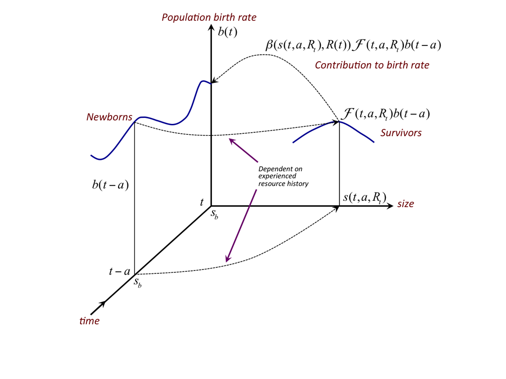

**Figure 10.1**: Schematic representation of the integro-differential equation system for the size-structured consumer-resource model, showing how the population birth rate at time $t-a$ contributes to the birth rate at time $t$ through consumers of age $a$ that have grown during their life from their size at birth $s_b$ till their current body size $s(t,a,R_t)$ and have survived with a probability $\mathcal{F}(t, a, R_t)$, which both depend on the history of the resource $R_t$ that these consumers have experienced.

## 10.1 The system of equations determining the population growth rate

For demographic analysis of a linear PSPM only the integral equation (\ref{eq:integraleq}) is relevant. In linear PSPMs the individual life history is not influenced by any density dependence or by any dependence on environment variables. We can hence drop the dependence of the development rate, fecundity and mortality rate on environment variables and generalize the integral equation (\ref{eq:integraleq}) for an arbitrary choice of the individual state to:

$$b(t)\;=\;\int_0^\infty \beta(\boldsymbol{\chi}(a))\,\mathcal{F}(a)\,b(t-a)\,da$$

in which $\boldsymbol{\chi}(a)$ is the state that individuals reach at age $a$ provided they were born with state $\boldsymbol{\chi}_b$. $\boldsymbol{\chi}(a)$ is formally given by:

$$\boldsymbol{\chi}(a)\;=\;\boldsymbol{\chi}_b\;+\;\int_0^a g(\boldsymbol{\chi}(\alpha))\,d\alpha$$

and $\mathcal{F}(a)$ is the probability of survival up to age $a$:

$$\mathcal{F}(a)\;=\;\exp\left(\displaystyle -\int_0^a\mu(\boldsymbol{\chi}(\alpha))\,d\alpha\right)$$

Assuming exponential growth of the population birth rate:

$$b(t)=e^{ra}b(t-a)$$

leads to Lotka’s integral equation for the population growth rate $r$:

$$\begin{equation}
\int_0^\infty e^{-ra}\beta(\boldsymbol{\chi}(a))\,\mathcal{F}(a)\,da\;=\;1\label{eq:lotka}
\end{equation}$$

Define the function $H(a, r)$ as the value of Lotka’s integral up to age $a$:

$$H(a,r)\;=\;\int_0^a e^{-r\alpha}\beta(\boldsymbol{\chi}(\alpha))\,\mathcal{F}(\alpha)\,d\alpha$$

Equation (\ref{eq:lotka}) can then be expressed as:

$$\begin{equation}
H(\infty, r)\;=\;1\label{eq:lotka2}
\end{equation}$$

which is a non-linear equation for the population growth rate $r$. This is the equation that is solved by the software package for the unknown quantity $r$ using an iterative approach based on the Newton-Chord method. For more details of the Newton-Chord method I refer to Kuznetsov (1995), which source I have used to a large extent for the iterative calculation of the solution $\tilde{r}$.

The central idea of the computational approach relates to the evaluation of the function $H(\infty,r)$, which is computed by solving an ordinary differential equation. To derive this ODE differentiate $\mathcal{F}(a)$ with respect to $a$ using the chain rule:

$$\dfrac{d}{da}\mathcal{F}(a)\,=\,-\exp\left(\displaystyle -\int_0^a\mu(\boldsymbol{\chi}(\alpha))\,d\alpha\right)\dfrac{d}{da}\left(\int_0^a\mu(\boldsymbol{\chi}(\alpha))\,d\alpha\right)$$

Applying Leibniz rule for differentiation of an integral:

$$\dfrac{d}{d\theta}\left(\int_{a(\theta)}^{b(\theta)}\!\!f(\boldsymbol{\chi},\theta)d\boldsymbol{\chi}\right)=
\int_{a(\theta)}^{b(\theta)}\!\!f_\theta(\boldsymbol{\chi},\theta)d\boldsymbol{\chi}+f(b(\theta),\theta)\,b^\prime(\theta)-f(a(\theta),\theta)\,a^\prime(\theta)$$

then leads to:

$$\dfrac{d\mathcal{F}}{da}\,=\,-\mu(\boldsymbol{\chi}(a))\,\mathcal{F}(a),\qquad\quad\mathcal{F}(0)\;=\;1$$

Similarly, differentiate $H(a,r)$ with respect to $a$ and applying Leibniz rule yields:

$$\dfrac{dH}{da}\,=\,e^{-ra}\,\beta(\boldsymbol{\chi}(a))\,\mathcal{F}(a),\qquad\quad H(0)\;=\;0$$

The value of $H(\infty, r)$ can hence be calculated by (numerical) integration of the ODEs:

$$\left\{
\begin{aligned}
\dfrac{d\boldsymbol{\chi}}{da}&=\;g(\boldsymbol{\chi}), &\boldsymbol{\chi}(0)\,=\,\boldsymbol{\chi}_b\\[1ex]
\dfrac{d\mathcal{F}}{da}&=\;-\mu(\boldsymbol{\chi}(a))\,\mathcal{F}(a), &\mathcal{F}(0)\,=\,1\\[1ex]
\dfrac{dH}{da}&=\;e^{-ra}\,\beta(\boldsymbol{\chi}(a))\,\mathcal{F}(a), &H(0)\,=\,0
\end{aligned}\right.$$

In practice numerical integration of these ODEs is carried out up to $a=A_{max}$ with $A_{max}$ either a fixed value or by $\mathcal{F}(A_{max})=\epsilon$ with $\epsilon$ a very small value (i.e. $\epsilon=10^{-9}$). Whenever an evaluation of the function $H(\infty, r)$ is required in the Newton iterations of equation (\ref{eq:lotka2}) this system of ODEs has to be integrated numerically. Once, a solution $\tilde{r}$ has been found, the sensitivities of this solution with respect to the model parameters are calculated using numerical differentiation.

## 10.2 The system of equations determining an equilibrium

The idea discussed above for the demographic analysis of a linear PSPM extends to the computation of an equilibrium of a nonlinear PSPM. In such a nonlinear PSPM the fecundity and the development and mortality rates of individuals does depend on their environment, but in equilibrium this environment is necessarily constant: $\tilde{E}$. Therefore, Lotka’s integral equation should determine as before the population growth rate $r$:

$$\int_0^\infty e^{-ra}\beta(\boldsymbol{\chi}(a, \tilde{E}), \tilde{E})\,\mathcal{F}(a, \tilde{E})\,da\;=\;1$$

Note that all parts of life history now depend on $E$. $\boldsymbol{\chi}$ and $\mathcal{F}$ do because of $g(\boldsymbol{\chi},E)$ and $\mu(\boldsymbol{\chi},E)$. However, $r$ should equal 0 for equilibrium of the structured population:

$$\int_0^\infty \beta(\boldsymbol{\chi}(a, \tilde{E}), \tilde{E})\,\mathcal{F}(a, \tilde{E})\,da\;=\;1$$

In addition, the autonomous dynamics of the environment should be balanced by the impact of the population:

$$G(\tilde{E})\;=\;\tilde{b}\int_0^\infty \gamma(\boldsymbol{\chi}(a, \tilde{E}), \tilde{E})\,\mathcal{F}(a, \tilde{E})\,da$$

The survival rate $\mathcal{F}(a, \tilde{E})$ and the value of the cumulative reproduction integral:

$$H(a, \tilde{E})\;=\;\int_0^a \beta(\boldsymbol{\chi}(\alpha,\tilde{E}), \tilde{E})\,\mathcal{F}(\alpha, \tilde{E})\,d\alpha$$

can be computed as before by solving the corresponding ODEs. To compute the impact of the population on the environment, define the function $I(a, \tilde{E})$ as:

$$I(a, \tilde{E})\;=\;\int_0^a \gamma(\boldsymbol{\chi}(\alpha,\tilde{E}), \tilde{E})\,\mathcal{F}(\alpha,\tilde{E})\,d\alpha$$

$I(a, \tilde{E})$ represents the cumulative, expected impact that a single individual exerts on its environment until age $a$. Differentiating $I(a, \tilde{E})$ with respect to $a$ yields after applying Leibniz rule:

$$\dfrac{dI}{da}\,=\,\gamma(\boldsymbol{\chi}(a,\tilde{E}), \tilde{E})\,\mathcal{F}(a, \tilde{E}),\qquad\quad I(0)\;=\;0$$

The equilibrium of a nonlinear structured population model is therefore determined by the system of equations:

$$\begin{align*}
&H(\infty, \tilde{E})\;=\;1\\[2pt]
&\tilde{b}I(\infty, \tilde{E})\;=\;G(\tilde{E})
\end{align*}$$

which has to be solved *numerically* and *iteratively* for the unknowns $\tilde{E}$ and $\tilde{b}$. These equations are solved by the software package for the unknown quantities using the Newton-Chord method as discussed before. Whenever the functions $H(\infty, \tilde{E})$ and $I(\infty, \tilde{E})$ have to be evaluated in this iterative procedure, the following system of ODEs is integrated numerically:

$$\left\{
\begin{aligned}
\dfrac{d\boldsymbol{\chi}}{da}&=\;g(\boldsymbol{\chi}(a, \tilde{E}), \tilde{E}), &\boldsymbol{\chi}(0, \tilde{E})\,=\,\boldsymbol{\chi}_b\\[0.5ex]
\dfrac{d\mathcal{F}}{da}&=\;-\mu(\boldsymbol{\chi}(a, \tilde{E}), \tilde{E})\,\mathcal{F}(a, \tilde{E}),\qquad &\mathcal{F}(0, \tilde{E})\,=\,1\\[0.5ex]
\dfrac{dH}{da}&=\;\beta(\boldsymbol{\chi}(a, \tilde{E}), \tilde{E})\,\mathcal{F}(a, \tilde{E}), &H(0, \tilde{E})\,=\,0\\[0.5ex]
\dfrac{dI}{da}&=\;\gamma(\boldsymbol{\chi}(a, \tilde{E}), \tilde{E})\,\mathcal{F}(a, \tilde{E}), &I(0, \tilde{E})\,=\,0
\end{aligned}
\right.\qquad\qquad\qquad\qquad$$

## 10.3 Curve continuation and detection of bifurcation points

The package uses the Newton-Chord method with Broyden updating of the Jacobian matrix to solve for the root of the nonlinear system of equations that determines the population growth rate of linear PSPMs or the equilibrium of nonlinear PSPMs. In addition, pseudo-arclength continuation is used to compute a curve of either the population growth rate or the equilibrium as a function of a single parameter. The numerical details about the Newton-Chord method as well as the pseudo-arclength continuation will not be discussed here. For details I refer to the appropriate sections in Kuznetsov (1995), which has been used as the basis for the implementations in the package. Both the Newton-Chord method as well as the pseudo-arclength continuation method make extensive use of partial derivatives of the system of equations with respect to variables and parameters. These partial derivatives, which for example make up the Jacobian matrix of the system of equations, are always computed numerically using a central-differencing approach.

The partial derivatives also play a role in the detection of bifurcation points, as explained in section 6.1. For example, the evolutionary analysis of PSPM using Adaptive Dynamics (AD) centers around the analysis of $s_x(y)$, which is the population growth rate of a mutant with trait $y$ in an environment that is completely determined by a resident population with trait $x$ (Geritz et al. 1998). An evolutionary fixed point occurs at $x=x^*$ where

$$\dfrac{\partial s_{x}(y)|_{x,y=x^{*}}}{\partial y}\;=\;0$$

The evolutionary fixed point can be classified as a convergent stable strategy (CSS), an evolutionary repellor (ERP) or evolutionary branching point (EBP) based on the value of Geritz et al. (1998):

$$\dfrac{\partial^2 s_{x}(y)|_{x,y=x^{*}}}{\partial y^2}\qquad\mathrm{and}\qquad
\dfrac{\partial^2 s_{x}(y)|_{x,y=x^{*}}}{\partial x^2}$$

Because the equilibrium conditions for a structured model

$$\int_0^\infty \beta(\boldsymbol{\chi}(a, \tilde{E}), \tilde{E})\,\mathcal{F}(a, \tilde{E})\,da\,-\,1\;=\;R_0\,-\,1=0$$

is sign-equivalent with $s_x(y)$ AD analysis can be performed using $R_0$ and its (partial) derivatives with respect to resident and mutant traits $x$ and $y$, respectively (Geritz et al. 1998). Hence, the detection of evolutionary fixed points, their classification as convergent stable strategies, repellors or branching points, as well as the continuation of these evolutionary singularities as a function of two parameters, which is discussed in sections 6.1 to 6.3 relies on the computation of these partial derivatives, which are computed numerically as pointed out above.

# References

Brännström, Åke, Linus Carlsson, and Daniel Simpson. 2013. “On the Convergence of the Escalator Boxcar Train.” *SIAM Journal on Numerical Analysis* 51 (6): 3213–31.

De Roos, A M. 1988. “Numerical methods for structured population models: The Escalator Boxcar Train.” *Numerical Methods for Partial Differential Equations* 4: 173–95.

———. 1997. “A gentle introduction to physiologically structured population models.” In *Structured Population Models in Marine, Terrestrial and Freshwater Systems*, edited by S Tuljapurkar and H Caswell, 119–204. Chapman-Hall, New York.

———. 2008. “Demographic analysis of continuous-time life-history models.” *Ecology Letters* 11: 1–15.

De Roos, A M, O Diekmann, and J A J Metz. 1992. “Studying the dynamics of structured population models: A versatile technique and its application to Daphnia.” *American Naturalist* 139 (1): 123–47.

De Roos, A M, and L Persson. 2002. “Size-dependent life-history traits promote catastrophic collapses of top predators.” *Proceedings of the National Academy of Sciences* 99 (20): 12907–12.

———. 2013. *Population and community ecology of ontogenetic development*. Monographs in Population Biology 51. Princeton University Press, Princeton.

Dieckmann, U. 1997. “Can adaptive dynamics invade?” *Trends in Ecology & Evolution* 12 (4): 128–31.

Dieckmann, U, and R Law. 1996. “The dynamical theory of coevolution: A derivation from stochastic ecological processes.” *Journal of Mathematical Biology* 34 (5-6): 579–612.

Diekmann, O, M Gyllenberg, and J A J Metz. 2003. “Steady-state analysis of structured population models.” *Theoretical Population Biology* 63 (4): 309–38.

Geritz, S A H, E Kisdi, G Meszéna, and J A J Metz. 1998. “Evolutionarily singular strategies and the adaptive growth and branching of the evolutionary tree.” *Evolutionary Ecology* 12 (1): 35–57.

Geritz, S A H, J A J Metz, and C Rueffler. 2016. “Mutual invadability near evolutionarily singular strategies for multivariate traits, with special reference to the strongly convergence stable case.” *Journal of Mathematical Biology* 72 (4): 1081–99.

Kirkilionis, M A, O Diekmann, B Lisser, M Nool, B Sommeijer, and A M De Roos. 2001. “Numerical continuation of equilibria of physiologically structured population models. I. Theory.” *Mathematical Models & Methods in Applied Sciences* 11 (6): 1101–27.

Kuznetsov, Y A. 1995. *Elements of applied bifurcation theory*. Heidelberg: Springer-Verlag.

Leimar, O. 2005. “The evolution of phenotypic polymorphism: Randomized strategies versus evolutionary branching.” *American Naturalist* 165 (6): 669–81.

Metz, J A J, and O Diekmann. 1986. *The dynamics of physiologically structured populations*. Vol. 68. Lecture Notes in Biomathematics. Springer-Verlag, Heidelberg.

Metz, J A J, S A H Geritz, G Meszéna, F J A Jacobs, and J S van Heerwaarden. 1996. “Adaptive dynamics, a geometrical study of the consequences of nearly faithful reproduction.” In *Stochastic and Spatial Structures of Dynamical Systems*, edited by S J van Strien and S M Verduyn-Lunel, 183–231. Amsterdam: KNAW Verhandelingen.

Zhang, L, U Dieckmann, and Å Brännström. 2017. “On the performance of four methods for the numerical solution of ecologically realistic size-structured population models.” *Methods in Ecology and Evolution* 8 (8): 948–56.